# Identification of Adolescents at Risk for Suicide Attempt

Elyse Llamocca

BMI 8050 Final Project

Autumn 2020

# Project Description

Suicide and suicide attempts among youth are major public health concerns. Suicide is the second leading cause of death in those aged 10 to 14 in the United States, and the rate of suicide has been increasing. (1) Youth health care visits related to suicidal behavior, defined as suicidal ideation and/or suicide attempt, are also increasing in the United States. (2,3) History of suicide attempt is a strong predictor of subsequent suicide attempt and suicide death. (4-7) Prospective identification of youth at risk for suicide attempt is vital to allow targeted intervention efforts to prevent future suicide attempts or suicide death. Machine learning is a potential valuable tool to identify youth at risk for suicide attempt. As argued by Hill et al. in a study attempting to predict suicide attempt in adolescents using machine learning, "One key advantage of machine learning approaches is the ability to approaches is the ability to better account for large numbers of inter-related predictors and to examine all possible interactions between predictors. As a result, these techniques may be better able to model the complex interplay of suicide risk markers in a way that regression based models and human cognition often do not.” (8)

Regression analyses and machine learning have been used to attempt to predict suicide attempts among United States youth in the past, including in combination with natural language processing and in both clinical and community-based settings. See, for example: Hill et al., Carson et al., Miché et al., Su et al., and Walsh et al. (8-12) Methods utilized to predict suicide attempts among United States youth in these examples included logistic regression, lasso logistic regression, ridge logistic regression, random forest, and classification tree. One interesting example is found in a study by Hill et al. (8), which utilized data from a nationally representative sample of adolescents in the United States to predict suicide attempters using classification tree analysis. Recognizing the importance of building a model to predict suicide attempts using nationally representative data, the objective of this project is to build upon Hill et al.’s work by predicting suicide attempts among adolescents using nationally-representative data from the National Longitudinal Study of Adolescent to Adult Health (Add Health) using two additional methodologies, logistic regression with L1 regularization and neural networks.

References

1. Curtin SC, Heron M. Death Rates Due to Suicide and Homicide Among Persons Aged 10–24: United States, 2000–2017. Published October 2019. Accessed December 3, 2020. https://www.cdc.gov/nchs/data/databriefs/db352-h.pdf
2. Burstein B, Agostino H, Greenfield B. Suicidal attempts and ideation among children and adolescents in US emergency departments, 2007-2015. JAMA Pediatr. 2019;173(6):598-600. doi:10.1001/jamapediatrics.2019.0464
3. Plemmons G, Hall M, Doupnik S, et al. Hospitalization for suicide ideation or attempt: 2008-2015. Pediatrics. 2018;141(6):e20172426. doi:10.1542/peds.2017-2426
4. Harris EC, Barraclough B. Suicide as an outcome for mental disorders. A meta-analysis. Br J Psychiatry. 1997;170:205-228. doi:10.1192/bjp.170.3.205
5. Hawton K, Bergen H, Kapur N, et al. Repetition of self-harm and suicide following self-harm in children and adolescents: findings from the Multicentre Study of Self-harm in England. J Child Psychol Psychiatry. 2012;53(12):1212-1219. doi:10.1111/j.1469-7610.2012.02559.x
6. Rosenbaum Asarnow J, Berk M, Zhang L, Wang P, Tang L. Emergency department youth patients With suicidal ideation or attempts: predicting suicide attempts through 18 months of follow-up. Suicide Life Threat Behav. 2017;47(5):551-566. doi:10.1111/sltb.12309
7. Olfson M, Wall M, Wang S, et al. Suicide after deliberate self-harm in adolescents and young adults. Pediatrics. 2018;141(4):e20173517. doi:10.1542/peds.2017-3517
8. Hill RM, Oosterhoff B, Do C. Using machine learning to identify suicide risk: a classification tree approach to prospectively identify adolescent suicide attempters. Arch Suicide Res. 2020;24(2):218-235. doi:10.1080/13811118.2019.1615018
9. Carson NJ, Mullin B, Sanchez MJ, et al. Identification of suicidal behavior among psychiatrically hospitalized adolescents using natural language processing and machine learning of electronic health records. PLoS One. 2019;14(2):e0211116. Published 2019 Feb 19. doi:10.1371/journal.pone.0211116
10. Miché M, Studerus E, Meyer AH, et al. Prospective prediction of suicide attempts in community adolescents and young adults, using regression methods and machine learning. J Affect Disord. 2020;265:570-578. doi:10.1016/j.jad.2019.11.093
11. Su C, Aseltine R, Doshi R, Chen K, Rogers SC, Wang F. Machine learning for suicide risk prediction in children and adolescents with electronic health records. Transl Psychiatry. 2020;10(1):413. Published 2020 Nov 26. doi:10.1038/s41398-020-01100-0
12. Walsh CG, Ribeiro JD, Franklin JC. Predicting suicide attempts in adolescents with longitudinal clinical data and machine learning. J Child Psychol Psychiatry. 2018;59(12):1261-1270. doi:10.1111/jcpp.12916

## Classification Tree with High Sensitivity at Cost of Specificity from Hill et al.

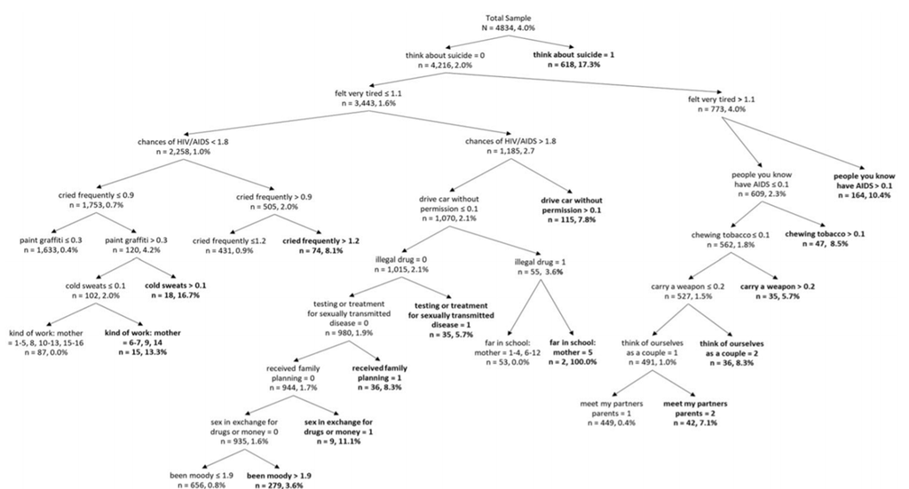

To allow comparison of results, I attempted to follow Hill et al.’s (all future references to Hill et al. refer to Reference #8 above) methodology as closely as possible. I obtained Wave 1 (1994-1995; n=6,054) and Wave 2 (1996; n=4,834) Add Health Public Use data and associated code and documentation from the Inter-University Consortium for Political and Social Research (ICPSR), as did Hill et al. The Add Health Public Use Data consists of a random subsample from the original nationally representative sample. The final analytic sample included all 4,834 individuals who responded to both Wave 1 and Wave 2. Hill et al. considered all adolescent self-response variables from the Wave 1 for inclusion as independent variables. These variables represent a wide range of data, including demographic, socioeconomic, social/family, psychological, physical health, and environmental factors. Variables were excluded if Hill et al. considered them uninterpretable or if they were missing more than 20% of data. My analysis used the same 345 variables identified for inclusion by Hill et al. The dependent variable was dichotomous, indicating whether a respondent had any reported suicide attempts during the past 12 months at Wave 2. In the final dataset, 192 individuals (~4.0%) had any reported suicide attempts during the past 12 months at Wave 2.

For all variables except past year suicide attempts (as reported at both Wave 1 and Wave 2), responses of missing, refused, don't know, not applicable, and legitimate skip were recoded as missing. Since past suicide attempt is a strong predictor of future suicide attempt, responses of legitimate skip for past year suicide attempts at Wave 1 and Wave 2 were recoded as 0.

The SAS code shown below was used to create an initial cleaned data set.

# SAS Code for Data Cleaning

```
libname lib "C:\Users\Elyse's Flippy PC\Desktop\Machine Learning\Project\From ICPSR\Project Data";

proc import datafile="C:\Users\Elyse's Flippy PC\Desktop\Machine Learning\Project\From ICPSR\Project Data\wave1.tsv"
out=lib.wave1 dbms=tab replace;
run;

proc cimport
infile="C:\Users\Elyse's Flippy PC\Desktop\Machine Learning\Project\From ICPSR\Project Data\wave2.stc" lib=work;
run;

proc cimport
infile="C:\Users\Elyse's Flippy PC\Desktop\Machine Learning\Project\From ICPSR\Project Data\wave2_weights.stc" lib=work;
run;

/*Recode responses labeled missing, refused, don’t know, not applicable, and legitimate skip as missing*/

data wave1_a;
set lib.wave1(drop=h1su2);
   IF (SCH_YR = 6) THEN SCH_YR = .;
   IF (BIO_SEX = 6) THEN BIO_SEX = .;
   IF (H1GI1M = 96) THEN H1GI1M = .;
   IF (H1GI1Y = 96) THEN H1GI1Y = .;
   IF (H1GI2 = 6 OR H1GI2 = 8) THEN H1GI2 = .;
   IF (H1GI3 = 96 OR H1GI3 = 98) THEN H1GI3 = .;
   IF (H1GI4 = 6 OR H1GI4 = 8) THEN H1GI4 = .;
   IF (H1GI5A = 7 OR H1GI5A = 8) THEN H1GI5A = .;
   IF (H1GI5B = 7 OR H1GI5B = 8) THEN H1GI5B = .;
   IF (H1GI5C = 7 OR H1GI5C = 8) THEN H1GI5C = .;
   IF (H1GI5D = 7 OR H1GI5D = 8) THEN H1GI5D = .;
   IF (H1GI5E = 7 OR H1GI5E = 8) THEN H1GI5E = .;
   IF (H1GI5F = 7 OR H1GI5F = 8) THEN H1GI5F = .;
   IF (H1GI6A = 6 OR H1GI6A = 8) THEN H1GI6A = .;
   IF (H1GI6B = 6 OR H1GI6B = 8) THEN H1GI6B = .;
   IF (H1GI6C = 6 OR H1GI6C = 8) THEN H1GI6C = .;
   IF (H1GI6D = 6 OR H1GI6D = 8) THEN H1GI6D = .;
   IF (H1GI6E = 6 OR H1GI6E = 8) THEN H1GI6E = .;
   IF (H1GI7A = 7 OR H1GI7A = 8) THEN H1GI7A = .;
   IF (H1GI7B = 7 OR H1GI7B = 8) THEN H1GI7B = .;
   IF (H1GI7C = 7 OR H1GI7C = 8) THEN H1GI7C = .;
   IF (H1GI7D = 7 OR H1GI7D = 8) THEN H1GI7D = .;
   IF (H1GI7E = 7 OR H1GI7E = 8) THEN H1GI7E = .;
   IF (H1GI7F = 7 OR H1GI7F = 8) THEN H1GI7F = .;
   IF (H1GI7G = 7 OR H1GI7G = 8) THEN H1GI7G = .;
   IF (H1GI8 >= 6 AND H1GI8 <= 9) THEN H1GI8 = .;
   IF (H1GI9 = 6 OR H1GI9 = 8) THEN H1GI9 = .;
   IF (H1GI10 = 6 OR H1GI10 = 8) THEN H1GI10 = .;
   IF (H1GI11 >= 6 AND H1GI11 <= 8) THEN H1GI11 = .;
   IF (H1GI12 >= 996 AND H1GI12 <= 999) THEN H1GI12 = .;
   IF (H1GI13M >= 96 AND H1GI13M <= 99) THEN H1GI13M = .;
   IF (H1GI13Y >= 96 AND H1GI13Y <= 99) THEN H1GI13Y = .;
   IF (H1GI14 = 7 OR H1GI14 = 8) THEN H1GI14 = .;
   IF (H1GI15 >= 6 AND H1GI15 <= 8) THEN H1GI15 = .;
   IF (H1GI16M = 97) THEN H1GI16M = .;
   IF (H1GI16Y = 97) THEN H1GI16Y = .;
   IF (H1GI18 = 6 OR H1GI18 = 8) THEN H1GI18 = .;
   IF (H1GI19 = 7) THEN H1GI19 = .;
   IF (H1GI20 >= 96 AND H1GI20 <= 99) THEN H1GI20 = .;
   IF (H1GI21 >= 96 AND H1GI21 <= 98) THEN H1GI21 = .;
   IF (H1DA1 = 6 OR H1DA1 = 8) THEN H1DA1 = .;
   IF (H1DA2 = 6 OR H1DA2 = 8) THEN H1DA2 = .;
   IF (H1DA3 = 6 OR H1DA3 = 8) THEN H1DA3 = .;
   IF (H1DA4 = 6 OR H1DA4 = 8) THEN H1DA4 = .;
   IF (H1DA5 = 6 OR H1DA5 = 8) THEN H1DA5 = .;
   IF (H1DA6 = 6 OR H1DA6 = 8) THEN H1DA6 = .;
   IF (H1DA7 = 6 OR H1DA7 = 8) THEN H1DA7 = .;
   IF (H1DA8 = 996 OR H1DA8 = 998) THEN H1DA8 = .;
   IF (H1DA9 = 996 OR H1DA9 = 998) THEN H1DA9 = .;
   IF (H1DA10 = 996 OR H1DA10 = 998) THEN H1DA10 = .;
   IF (H1DA11 = 996 OR H1DA11 = 998) THEN H1DA11 = .;
   IF (H1GH1 = 6 OR H1GH1 = 8) THEN H1GH1 = .;
   IF (H1GH1A >= 6 AND H1GH1A <= 8) THEN H1GH1A = .;
   IF (H1GH2 = 6 OR H1GH2 = 8) THEN H1GH2 = .;
   IF (H1GH3 = 6 OR H1GH3 = 8) THEN H1GH3 = .;
   IF (H1GH4 = 6 OR H1GH4 = 8) THEN H1GH4 = .;
   IF (H1GH5 = 6 OR H1GH5 = 8) THEN H1GH5 = .;
   IF (H1GH6 = 6 OR H1GH6 = 8) THEN H1GH6 = .;
   IF (H1GH7 = 6 OR H1GH7 = 8) THEN H1GH7 = .;
   IF (H1GH8 = 6 OR H1GH8 = 8) THEN H1GH8 = .;
   IF (H1GH9 = 6 OR H1GH9 = 8) THEN H1GH9 = .;
   IF (H1GH10 = 6 OR H1GH10 = 8) THEN H1GH10 = .;
   IF (H1GH11 = 6 OR H1GH11 = 8) THEN H1GH11 = .;
   IF (H1GH12 = 6 OR H1GH12 = 8) THEN H1GH12 = .;
   IF (H1GH13 = 6 OR H1GH13 = 8) THEN H1GH13 = .;
   IF (H1GH14 = 6 OR H1GH14 = 8) THEN H1GH14 = .;
   IF (H1GH15 = 6 OR H1GH15 = 8) THEN H1GH15 = .;
   IF (H1GH16 >= 6 AND H1GH16 <= 8) THEN H1GH16 = .;
   IF (H1GH17 = 6 OR H1GH17 = 8) THEN H1GH17 = .;
   IF (H1GH18 = 6 OR H1GH18 = 8) THEN H1GH18 = .;
   IF (H1GH19 = 6 OR H1GH19 = 8) THEN H1GH19 = .;
   IF (H1GH20 = 6 OR H1GH20 = 8) THEN H1GH20 = .;
   IF (H1GH21 = 6 OR H1GH21 = 8) THEN H1GH21 = .;
   IF (H1GH22 = 6 OR H1GH22 = 8) THEN H1GH22 = .;
   IF (H1GH23A = 6 OR H1GH23A = 8) THEN H1GH23A = .;
   IF (H1GH23B = 6 OR H1GH23B = 8) THEN H1GH23B = .;
   IF (H1GH23C = 6 OR H1GH23C = 8) THEN H1GH23C = .;
   IF (H1GH23D = 6 OR H1GH23D = 8) THEN H1GH23D = .;
   IF (H1GH23E = 6 OR H1GH23E = 8) THEN H1GH23E = .;
   IF (H1GH23F = 6 OR H1GH23F = 8) THEN H1GH23F = .;
   IF (H1GH23G = 6 OR H1GH23G = 8) THEN H1GH23G = .;
   IF (H1GH23H = 6 OR H1GH23H = 8) THEN H1GH23H = .;
   IF (H1GH23I = 6 OR H1GH23I = 8) THEN H1GH23I = .;
   IF (H1GH23J = 6 OR H1GH23J = 8) THEN H1GH23J = .;
   IF (H1GH24 = 6 OR H1GH24 = 8 OR H1GH24 = 9) THEN H1GH24 = .;
   IF (H1GH25 = 6 OR H1GH25 = 8 OR H1GH25 = 9) THEN H1GH25 = .;
   IF (H1GH26 = 6 OR H1GH26 = 8) THEN H1GH26 = .;
   IF (H1GH27A >= 6 AND H1GH27A <= 8) THEN H1GH27A = .;
   IF (H1GH27B >= 6 AND H1GH27B <= 8) THEN H1GH27B = .;
   IF (H1GH27C >= 6 AND H1GH27C <= 8) THEN H1GH27C = .;
   IF (H1GH27D >= 6 AND H1GH27D <= 8) THEN H1GH27D = .;
   IF (H1GH27E >= 6 AND H1GH27E <= 8) THEN H1GH27E = .;
   IF (H1GH27F >= 6 AND H1GH27F <= 8) THEN H1GH27F = .;
   IF (H1GH27G >= 6 AND H1GH27G <= 8) THEN H1GH27G = .;
   IF (H1GH27H >= 6 AND H1GH27H <= 8) THEN H1GH27H = .;
   IF (H1GH27I >= 6 AND H1GH27I <= 8) THEN H1GH27I = .;
   IF (H1GH27J >= 6 AND H1GH27J <= 8) THEN H1GH27J = .;
   IF (H1GH28 = 6 OR H1GH28 = 8) THEN H1GH28 = .;
   IF (H1GH29 = 6 OR H1GH29 = 8) THEN H1GH29 = .;
   IF (H1GH30A >= 6 AND H1GH30A <= 8) THEN H1GH30A = .;
   IF (H1GH30B >= 6 AND H1GH30B <= 8) THEN H1GH30B = .;
   IF (H1GH30C >= 6 AND H1GH30C <= 8) THEN H1GH30C = .;
   IF (H1GH30D >= 6 AND H1GH30D <= 8) THEN H1GH30D = .;
   IF (H1GH30E >= 6 AND H1GH30E <= 8) THEN H1GH30E = .;
   IF (H1GH30F >= 6 AND H1GH30F <= 8) THEN H1GH30F = .;
   IF (H1GH30G >= 6 AND H1GH30G <= 8) THEN H1GH30G = .;
   IF (H1GH31A = 7) THEN H1GH31A = .;
   IF (H1GH31B = 7) THEN H1GH31B = .;
   IF (H1GH31C = 7) THEN H1GH31C = .;
   IF (H1GH31D = 7) THEN H1GH31D = .;
   IF (H1GH31F = 7) THEN H1GH31F = .;
   IF (H1GH31G = 7) THEN H1GH31G = .;
   IF (H1GH32 = 6 OR H1GH32 = 8) THEN H1GH32 = .;
   IF (H1GH33 = 6 OR H1GH33 = 8) THEN H1GH33 = .;
   IF (H1GH34 = 6 OR H1GH34 = 8) THEN H1GH34 = .;
   IF (H1GH35 = 6 OR H1GH35 = 8) THEN H1GH35 = .;
   IF (H1GH36 = 6 OR H1GH36 = 8) THEN H1GH36 = .;
   IF (H1GH37 >= 6 AND H1GH37 <= 8) THEN H1GH37 = .;
   IF (H1GH38 = 7 OR H1GH38 = 8) THEN H1GH38 = .;
   IF (H1GH39 = 6 OR H1GH39 = 8) THEN H1GH39 = .;
   IF (H1GH40 = 6 OR H1GH40 = 8) THEN H1GH40 = .;
   IF (H1GH41 >= 6 AND H1GH41 <= 8) THEN H1GH41 = .;
   IF (H1GH42 = 6 OR H1GH42 = 8) THEN H1GH42 = .;
   IF (H1GH43 = 6 OR H1GH43 = 8 OR H1GH43 = 9) THEN H1GH43 = .;
   IF (H1GH44 = 6 OR H1GH44 = 8) THEN H1GH44 = .;
   IF (H1GH46 = 6 OR H1GH46 = 8 OR H1GH46 = 9) THEN H1GH46 = .;
   IF (H1GH48 = 6 OR H1GH48 = 8 OR H1GH48 = 9) THEN H1GH48 = .;
   IF (H1GH49 = 6 OR H1GH49 = 8) THEN H1GH49 = .;
   IF (H1GH50 = '999996' OR H1GH50 = '999998' OR H1GH50 = '999999') THEN H1GH50 = '';
   IF (H1GH51 = 96 OR H1GH51 = 98) THEN H1GH51 = .;
   IF (H1GH52 = 6 OR H1GH52 = 8) THEN H1GH52 = .;
   IF (H1GH53 = 6 OR H1GH53 = 8 OR H1GH53 = 9) THEN H1GH53 = .;
   IF (H1GH54 = 6 OR H1GH54 = 8 OR H1GH54 = 9) THEN H1GH54 = .;
   IF (H1GH55 = 6 OR H1GH55 = 8) THEN H1GH55 = .;
   IF (H1GH56 = 6 OR H1GH56 = 8) THEN H1GH56 = .;
   IF (H1GH57 = 6 OR H1GH57 = 8) THEN H1GH57 = .;
   IF (H1GH58 >= 6 AND H1GH58 <= 8) THEN H1GH58 = .;
   IF (H1GH59A = 96 OR H1GH59A = 98) THEN H1GH59A = .;
   IF (H1GH59B = 96 OR H1GH59B = 98 OR H1GH59B = 99) THEN H1GH59B = .;
   IF (H1GH60 = 996 OR H1GH60 = 998 OR H1GH60 = 999) THEN H1GH60 = .;
   IF (H1TS1 = 6 OR H1TS1 = 8) THEN H1TS1 = .;
   IF (H1TS2 = 6 OR H1TS2 = 8) THEN H1TS2 = .;
   IF (H1TS3 = 6 OR H1TS3 = 8) THEN H1TS3 = .;
   IF (H1TS4 = 6 OR H1TS4 = 8) THEN H1TS4 = .;
   IF (H1TS5 = 6 OR H1TS5 = 8) THEN H1TS5 = .;
   IF (H1TS6 = 6 OR H1TS6 = 8) THEN H1TS6 = .;
   IF (H1TS7 = 6 OR H1TS7 = 8) THEN H1TS7 = .;
   IF (H1TS8 = 6 OR H1TS8 = 8) THEN H1TS8 = .;
   IF (H1TS9 = 6 OR H1TS9 = 8) THEN H1TS9 = .;
   IF (H1TS10 = 6 OR H1TS10 = 8) THEN H1TS10 = .;
   IF (H1TS11 = 6 OR H1TS11 = 8) THEN H1TS11 = .;
   IF (H1TS12 = 6 OR H1TS12 = 8) THEN H1TS12 = .;
   IF (H1TS13 = 6 OR H1TS13 = 8) THEN H1TS13 = .;
   IF (H1TS14 = 6 OR H1TS14 = 8) THEN H1TS14 = .;
   IF (H1TS15 = 6 OR H1TS15 = 8) THEN H1TS15 = .;
   IF (H1TS16 = 6 OR H1TS16 = 8) THEN H1TS16 = .;
   IF (H1TS17 = 6 OR H1TS17 = 8) THEN H1TS17 = .;
   IF (H1ED1 >= 6 AND H1ED1 <= 9) THEN H1ED1 = .;
   IF (H1ED2 >= 996 AND H1ED2 <= 998) THEN H1ED2 = .;
   IF (H1ED3 = 6 OR H1ED3 = 8) THEN H1ED3 = .;
   IF (H1ED4A >= 6 AND H1ED4A <= 8) THEN H1ED4A = .;
   IF (H1ED4B >= 6 AND H1ED4B <= 8) THEN H1ED4B = .;
   IF (H1ED4C >= 6 AND H1ED4C <= 8) THEN H1ED4C = .;
   IF (H1ED4D >= 6 AND H1ED4D <= 8) THEN H1ED4D = .;
   IF (H1ED4E >= 6 AND H1ED4E <= 8) THEN H1ED4E = .;
   IF (H1ED4F >= 6 AND H1ED4F <= 8) THEN H1ED4F = .;
   IF (H1ED4G >= 6 AND H1ED4G <= 8) THEN H1ED4G = .;
   IF (H1ED4H >= 6 AND H1ED4H <= 8) THEN H1ED4H = .;
   IF (H1ED4I >= 6 AND H1ED4I <= 8) THEN H1ED4I = .;
   IF (H1ED4J >= 6 AND H1ED4J <= 8) THEN H1ED4J = .;
   IF (H1ED4K >= 6 AND H1ED4K <= 8) THEN H1ED4K = .;
   IF (H1ED4M >= 6 AND H1ED4M <= 8) THEN H1ED4M = .;
   IF (H1ED5 = 6 OR H1ED5 = 8) THEN H1ED5 = .;
   IF (H1ED6A = 7 OR H1ED6A = 8) THEN H1ED6A = .;
   IF (H1ED6B = 7 OR H1ED6B = 8) THEN H1ED6B = .;
   IF (H1ED6C = 7 OR H1ED6C = 8) THEN H1ED6C = .;
   IF (H1ED6D = 7 OR H1ED6D = 8) THEN H1ED6D = .;
   IF (H1ED6E = 7 OR H1ED6E = 8) THEN H1ED6E = .;
   IF (H1ED6F = 7 OR H1ED6F = 8) THEN H1ED6F = .;
   IF (H1ED6G = 7 OR H1ED6G = 8) THEN H1ED6G = .;
   IF (H1ED6H = 7 OR H1ED6H = 8) THEN H1ED6H = .;
   IF (H1ED6I = 7 OR H1ED6I = 8) THEN H1ED6I = .;
   IF (H1ED6J = 7 OR H1ED6J = 8) THEN H1ED6J = .;
   IF (H1ED6K = 7 OR H1ED6K = 8) THEN H1ED6K = .;
   IF (H1ED6L = 7 OR H1ED6L = 8) THEN H1ED6L = .;
   IF (H1ED6M = 7 OR H1ED6M = 8) THEN H1ED6M = .;
   IF (H1ED7 = 6 OR H1ED7 = 8) THEN H1ED7 = .;
   IF (H1ED8 >= 96 AND H1ED8 <= 99) THEN H1ED8 = .;
   IF (H1ED9 = 6 OR H1ED9 = 8) THEN H1ED9 = .;
   IF (H1ED10 = 96 OR H1ED10 = 97 OR H1ED10 = 99) THEN H1ED10 = .;
   IF (H1ED11 >= 96 AND H1ED11 <= 98) THEN H1ED11 = .;
   IF (H1ED12 >= 96 AND H1ED12 <= 98) THEN H1ED12 = .;
   IF (H1ED13 >= 96 AND H1ED13 <= 98) THEN H1ED13 = .;
   IF (H1ED14 >= 96 AND H1ED14 <= 98) THEN H1ED14 = .;
   IF (H1ED15 >= 6 AND H1ED15 <= 8) THEN H1ED15 = .;
   IF (H1ED16 >= 6 AND H1ED16 <= 8) THEN H1ED16 = .;
   IF (H1ED17 >= 6 AND H1ED17 <= 8) THEN H1ED17 = .;
   IF (H1ED18 >= 6 AND H1ED18 <= 8) THEN H1ED18 = .;
   IF (H1ED19 >= 6 AND H1ED19 <= 8) THEN H1ED19 = .;
   IF (H1ED20 >= 6 AND H1ED20 <= 8) THEN H1ED20 = .;
   IF (H1ED21 >= 6 AND H1ED21 <= 8) THEN H1ED21 = .;
   IF (H1ED22 >= 6 AND H1ED22 <= 8) THEN H1ED22 = .;
   IF (H1ED23 >= 6 AND H1ED23 <= 8) THEN H1ED23 = .;
   IF (H1ED24 >= 6 AND H1ED24 <= 8) THEN H1ED24 = .;
   IF (H1PL1 = 6 OR H1PL1 = 8) THEN H1PL1 = .;
   IF (H1PL2 = 7) THEN H1PL2 = .;
   IF (H1PL3 = 7 OR H1PL3 = 8) THEN H1PL3 = .;
   IF (H1PL4 = 7) THEN H1PL4 = .;
   IF (H1PL5 = 6 OR H1PL5 = 8) THEN H1PL5 = .;
   IF (H1PL6 = 6 OR H1PL6 = 8) THEN H1PL6 = .;
   IF (H1PL7 = 6 OR H1PL7 = 8) THEN H1PL7 = .;
   IF (H1PL8 >= 6 AND H1PL8 <= 8) THEN H1PL8 = .;
   IF (H1PL9 = 7 OR H1PL9 = 8) THEN H1PL9 = .;
   IF (H1PL10 >= 6 AND H1PL10 <= 8) THEN H1PL10 = .;
   IF (H1PL11 = 7) THEN H1PL11 = .;
   IF (H1PL12 >= 6 AND H1PL12 <= 8) THEN H1PL12 = .;
   IF (H1PL13 = 7) THEN H1PL13 = .;
   IF (H1PL14 >= 6 AND H1PL14 <= 8) THEN H1PL14 = .;
   IF (H1PL15 = 7) THEN H1PL15 = .;
   IF (H1PL16 >= 6 AND H1PL16 <= 8) THEN H1PL16 = .;
   IF (H1PL17 = 7) THEN H1PL17 = .;
   IF (H1PL18 >= 6 AND H1PL18 <= 8) THEN H1PL18 = .;
   IF (H1PL19 = 7) THEN H1PL19 = .;
   IF (H1PL20 >= 6 AND H1PL20 <= 8) THEN H1PL20 = .;
```

```
   IF (H1PL21 >= 6 AND H1PL21 <= 8) THEN H1PL21 = .;
   IF (H1PL22 >= 6 AND H1PL22 <= 8) THEN H1PL22 = .;
   IF (H1PL23 >= 6 AND H1PL23 <= 8) THEN H1PL23 = .;
   IF (H1PL24 >= 6 AND H1PL24 <= 8) THEN H1PL24 = .;
   IF (H1PL25 >= 6 AND H1PL25 <= 8) THEN H1PL25 = .;
   IF (H1PL26 >= 6 AND H1PL26 <= 8) THEN H1PL26 = .;
   IF (H1PL29 >= 6 AND H1PL29 <= 8) THEN H1PL29 = .;
   IF (H1PL30 >= 6 AND H1PL30 <= 8) THEN H1PL30 = .;
   IF (H1PL31 >= 6 AND H1PL31 <= 8) THEN H1PL31 = .;
   IF (H1PL33 >= 6 AND H1PL33 <= 8) THEN H1PL33 = .;
   IF (H1PL34 >= 6 AND H1PL34 <= 8) THEN H1PL34 = .;
   IF (H1PL37 >= 6 AND H1PL37 <= 8) THEN H1PL37 = .;
   IF (H1PL38 >= 6 AND H1PL38 <= 8) THEN H1PL38 = .;
   IF (H1HS1 = 6 OR H1HS1 = 8) THEN H1HS1 = .;
   IF (H1HS2A = 7 OR H1HS2A = 8) THEN H1HS2A = .;
   IF (H1HS2B = 7 OR H1HS2B = 8) THEN H1HS2B = .;
   IF (H1HS2C = 7 OR H1HS2C = 8) THEN H1HS2C = .;
   IF (H1HS2D = 7 OR H1HS2D = 8) THEN H1HS2D = .;
   IF (H1HS2E = 7 OR H1HS2E = 8) THEN H1HS2E = .;
   IF (H1HS3 = 6 OR H1HS3 = 8) THEN H1HS3 = .;
   IF (H1HS4A = 7) THEN H1HS4A = .;
   IF (H1HS4B = 7) THEN H1HS4B = .;
   IF (H1HS4C = 7) THEN H1HS4C = .;
   IF (H1HS4D = 7) THEN H1HS4D = .;
   IF (H1HS4E = 7) THEN H1HS4E = .;
   IF (H1HS5 = 6 OR H1HS5 = 8) THEN H1HS5 = .;
   IF (H1HS6A = 7) THEN H1HS6A = .;
   IF (H1HS6B = 7) THEN H1HS6B = .;
   IF (H1HS6C = 7) THEN H1HS6C = .;
   IF (H1HS6D = 7) THEN H1HS6D = .;
   IF (H1HS6E = 7) THEN H1HS6E = .;
   IF (H1HS7 = 6 OR H1HS7 = 8) THEN H1HS7 = .;
   IF (H1HS8A = 7 OR H1HS8A = 8) THEN H1HS8A = .;
   IF (H1HS8B = 7 OR H1HS8B = 8) THEN H1HS8B = .;
   IF (H1HS8C = 7 OR H1HS8C = 8) THEN H1HS8C = .;
   IF (H1HS8D = 7 OR H1HS8D = 8) THEN H1HS8D = .;
   IF (H1HS8E = 7 OR H1HS8E = 8) THEN H1HS8E = .;
   IF (H1HS9 = 6 OR H1HS9 = 8) THEN H1HS9 = .;
   IF (H1HS10A = 7) THEN H1HS10A = .;
   IF (H1HS10B = 7) THEN H1HS10B = .;
   IF (H1HS10C = 7) THEN H1HS10C = .;
   IF (H1HS10D = 7) THEN H1HS10D = .;
   IF (H1HS10E = 7) THEN H1HS10E = .;
   IF (H1HS11 >= 6 AND H1HS11 <= 8) THEN H1HS11 = .;
   IF (H1HS12A = 7) THEN H1HS12A = .;
   IF (H1HS12B = 7) THEN H1HS12B = .;
   IF (H1HS12C = 7) THEN H1HS12C = .;
   IF (H1HS12D = 7) THEN H1HS12D = .;
   IF (H1HS12E = 7) THEN H1HS12E = .;
   IF (H1RP1 >= 6 AND H1RP1 <= 9) THEN H1RP1 = .;
   IF (H1RP2 >= 6 AND H1RP2 <= 9) THEN H1RP2 = .;
   IF (H1RP3 >= 6 AND H1RP3 <= 9) THEN H1RP3 = .;
   IF (H1RP4 >= 6 AND H1RP4 <= 9) THEN H1RP4 = .;
   IF (H1RP5 >= 6 AND H1RP5 <= 9) THEN H1RP5 = .;
   IF (H1RP6 >= 6 AND H1RP6 <= 9) THEN H1RP6 = .;
   IF (H1SE1 >= 96 AND H1SE1 <= 99) THEN H1SE1 = .;
   IF (H1SE2 >= 96 AND H1SE2 <= 99) THEN H1SE2 = .;
   IF (H1SE3 >= 96 AND H1SE3 <= 99) THEN H1SE3 = .;
   IF (H1SE4 = 96 OR H1SE4 = 98) THEN H1SE4 = .;
   IF (H1FS1 = 6 OR H1FS1 = 8) THEN H1FS1 = .;
   IF (H1FS2 = 6 OR H1FS2 = 8) THEN H1FS2 = .;
   IF (H1FS3 = 6 OR H1FS3 = 8) THEN H1FS3 = .;
   IF (H1FS4 = 6 OR H1FS4 = 8) THEN H1FS4 = .;
   IF (H1FS5 = 6 OR H1FS5 = 8) THEN H1FS5 = .;
   IF (H1FS6 = 6 OR H1FS6 = 8) THEN H1FS6 = .;
   IF (H1FS7 = 6 OR H1FS7 = 8) THEN H1FS7 = .;
   IF (H1FS8 = 6 OR H1FS8 = 8) THEN H1FS8 = .;
   IF (H1FS9 = 6 OR H1FS9 = 8) THEN H1FS9 = .;
   IF (H1FS10 = 6 OR H1FS10 = 8) THEN H1FS10 = .;
   IF (H1FS11 = 6 OR H1FS11 = 8) THEN H1FS11 = .;
   IF (H1FS12 = 6 OR H1FS12 = 8) THEN H1FS12 = .;
   IF (H1FS13 = 6 OR H1FS13 = 8) THEN H1FS13 = .;
   IF (H1FS14 = 6 OR H1FS14 = 8) THEN H1FS14 = .;
   IF (H1FS15 = 6 OR H1FS15 = 8) THEN H1FS15 = .;
   IF (H1FS16 = 6 OR H1FS16 = 8) THEN H1FS16 = .;
   IF (H1FS17 = 6 OR H1FS17 = 8) THEN H1FS17 = .;
   IF (H1FS18 = 6 OR H1FS18 = 8) THEN H1FS18 = .;
   IF (H1FS19 = 6 OR H1FS19 = 8) THEN H1FS19 = .;
   IF (H1HR2A >= 6 AND H1HR2A <= 8) THEN H1HR2A = .;
   IF (H1HR3A >= 96 AND H1HR3A <= 98) THEN H1HR3A = .;
   IF (H1HR4A = 97) THEN H1HR4A = .;
   IF (H1HR5A = 97) THEN H1HR5A = .;
   IF (H1HR6A = 97) THEN H1HR6A = .;
   IF (H1HR7A >= 996.0 AND H1HR7A <= 998.0) THEN H1HR7A = .;
   IF (H1HR8A = 997 OR H1HR8A = 998) THEN H1HR8A = .;
   IF (H1HR9A >= 6 AND H1HR9A <= 8) THEN H1HR9A = .;
   IF (H1HR10A >= 96 AND H1HR10A <= 98) THEN H1HR10A = .;
   IF (H1HR11A = 97) THEN H1HR11A = .;
   IF (H1HR2B >= 6 AND H1HR2B <= 8) THEN H1HR2B = .;
   IF (H1HR3B >= 96 AND H1HR3B <= 98) THEN H1HR3B = .;
   IF (H1HR4B = 97) THEN H1HR4B = .;
   IF (H1HR5B = 97 OR H1HR5B = 98) THEN H1HR5B = .;
   IF (H1HR6B = 97) THEN H1HR6B = .;
   IF (H1HR7B >= 996.0 AND H1HR7B <= 998.0) THEN H1HR7B = .;
   IF (H1HR8B = 997 OR H1HR8B = 998) THEN H1HR8B = .;
   IF (H1HR9B >= 6 AND H1HR9B <= 9) THEN H1HR9B = .;
   IF (H1HR10B >= 96 AND H1HR10B <= 98) THEN H1HR10B = .;
   IF (H1HR11B = 97 OR H1HR11B = 98) THEN H1HR11B = .;
   IF (H1HR2C >= 6 AND H1HR2C <= 8) THEN H1HR2C = .;
   IF (H1HR3C >= 96 AND H1HR3C <= 98) THEN H1HR3C = .;
   IF (H1HR4C = 97) THEN H1HR4C = .;
   IF (H1HR5C = 97) THEN H1HR5C = .;
   IF (H1HR6C = 97) THEN H1HR6C = .;
   IF (H1HR7C >= 996 AND H1HR7C <= 999) THEN H1HR7C = .;
   IF (H1HR8C = 997 OR H1HR8C = 998) THEN H1HR8C = .;
   IF (H1HR9C >= 6 AND H1HR9C <= 8) THEN H1HR9C = .;
   IF (H1HR10C >= 96 AND H1HR10C <= 98) THEN H1HR10C = .;
   IF (H1HR11C = 97) THEN H1HR11C = .;
   IF (H1HR2D >= 6 AND H1HR2D <= 8) THEN H1HR2D = .;
   IF (H1HR3D >= 96 AND H1HR3D <= 98) THEN H1HR3D = .;
   IF (H1HR4D = 97) THEN H1HR4D = .;
   IF (H1HR5D = 97) THEN H1HR5D = .;
   IF (H1HR6D = 97) THEN H1HR6D = .;
   IF (H1HR7D >= 996 AND H1HR7D <= 999) THEN H1HR7D = .;
   IF (H1HR8D = 997 OR H1HR8D = 998) THEN H1HR8D = .;
   IF (H1HR9D >= 6 AND H1HR9D <= 8) THEN H1HR9D = .;
   IF (H1HR10D >= 96 AND H1HR10D <= 99) THEN H1HR10D = .;
   IF (H1HR11D = 97 OR H1HR11D = 98) THEN H1HR11D = .;
   IF (H1HR2E >= 6 AND H1HR2E <= 8) THEN H1HR2E = .;
   IF (H1HR3E >= 96 AND H1HR3E <= 98) THEN H1HR3E = .;
   IF (H1HR4E = 97) THEN H1HR4E = .;
   IF (H1HR5E = 97) THEN H1HR5E = .;
   IF (H1HR6E = 97) THEN H1HR6E = .;
   IF (H1HR7E >= 996 AND H1HR7E <= 998) THEN H1HR7E = .;
   IF (H1HR8E = 997 OR H1HR8E = 998) THEN H1HR8E = .;
   IF (H1HR9E >= 6 AND H1HR9E <= 8) THEN H1HR9E = .;
   IF (H1HR10E >= 96 AND H1HR10E <= 98) THEN H1HR10E = .;
   IF (H1HR11E = 97 OR H1HR11E = 98) THEN H1HR11E = .;
   IF (H1HR2F >= 6 AND H1HR2F <= 8) THEN H1HR2F = .;
   IF (H1HR3F >= 96 AND H1HR3F <= 98) THEN H1HR3F = .;
   IF (H1HR4F = 97) THEN H1HR4F = .;
   IF (H1HR5F = 97) THEN H1HR5F = .;
   IF (H1HR6F = 97) THEN H1HR6F = .;
   IF (H1HR7F >= 996 AND H1HR7F <= 999) THEN H1HR7F = .;
   IF (H1HR8F = 997 OR H1HR8F = 998) THEN H1HR8F = .;
   IF (H1HR9F >= 6 AND H1HR9F <= 8) THEN H1HR9F = .;
   IF (H1HR10F >= 96 AND H1HR10F <= 98) THEN H1HR10F = .;
   IF (H1HR11F = 97) THEN H1HR11F = .;
   IF (H1HR2G >= 6 AND H1HR2G <= 8) THEN H1HR2G = .;
   IF (H1HR3G >= 96 AND H1HR3G <= 98) THEN H1HR3G = .;
   IF (H1HR4G = 97) THEN H1HR4G = .;
   IF (H1HR5G = 97) THEN H1HR5G = .;
   IF (H1HR6G = 97) THEN H1HR6G = .;
   IF (H1HR7G >= 996 AND H1HR7G <= 998) THEN H1HR7G = .;
   IF (H1HR8G = 997 OR H1HR8G = 998) THEN H1HR8G = .;
   IF (H1HR9G >= 6 AND H1HR9G <= 8) THEN H1HR9G = .;
   IF (H1HR10G >= 96 AND H1HR10G <= 98) THEN H1HR10G = .;
   IF (H1HR11G = 97) THEN H1HR11G = .;
   IF (H1HR2H >= 6 AND H1HR2H <= 8) THEN H1HR2H = .;
   IF (H1HR3H >= 96 AND H1HR3H <= 98) THEN H1HR3H = .;
   IF (H1HR4H = 97) THEN H1HR4H = .;
   IF (H1HR5H = 97) THEN H1HR5H = .;
   IF (H1HR6H = 97) THEN H1HR6H = .;
   IF (H1HR7H >= 996 AND H1HR7H <= 998) THEN H1HR7H = .;
   IF (H1HR8H = 997 OR H1HR8H = 998) THEN H1HR8H = .;
   IF (H1HR9H >= 6 AND H1HR9H <= 8) THEN H1HR9H = .;
   IF (H1HR10H >= 96 AND H1HR10H <= 98) THEN H1HR10H = .;
   IF (H1HR11H = 97) THEN H1HR11H = .;
   IF (H1HR2I >= 6 AND H1HR2I <= 8) THEN H1HR2I = .;
   IF (H1HR3I >= 96 AND H1HR3I <= 98) THEN H1HR3I = .;
   IF (H1HR4I = 97) THEN H1HR4I = .;
   IF (H1HR5I = 97) THEN H1HR5I = .;
   IF (H1HR6I = 97) THEN H1HR6I = .;
   IF (H1HR7I >= 996 AND H1HR7I <= 998) THEN H1HR7I = .;
   IF (H1HR8I = 997 OR H1HR8I = 998) THEN H1HR8I = .;
   IF (H1HR9I >= 6 AND H1HR9I <= 8) THEN H1HR9I = .;
   IF (H1HR10I >= 96 AND H1HR10I <= 98) THEN H1HR10I = .;
   IF (H1HR11I = 97) THEN H1HR11I = .;
   IF (H1HR2J >= 6 AND H1HR2J <= 8) THEN H1HR2J = .;
   IF (H1HR3J >= 96 AND H1HR3J <= 98) THEN H1HR3J = .;
   IF (H1HR4J = 97) THEN H1HR4J = .;
   IF (H1HR5J = 97) THEN H1HR5J = .;
   IF (H1HR6J = 97) THEN H1HR6J = .;
   IF (H1HR7J >= 996 AND H1HR7J <= 998) THEN H1HR7J = .;
   IF (H1HR8J = 997 OR H1HR8J = 998) THEN H1HR8J = .;
   IF (H1HR9J >= 6 AND H1HR9J <= 8) THEN H1HR9J = .;
   IF (H1HR10J >= 96 AND H1HR10J <= 98) THEN H1HR10J = .;
   IF (H1HR11J = 97) THEN H1HR11J = .;
   IF (H1HR2K >= 6 AND H1HR2K <= 8) THEN H1HR2K = .;
   IF (H1HR3K >= 96 AND H1HR3K <= 98) THEN H1HR3K = .;
   IF (H1HR4K = 97) THEN H1HR4K = .;
   IF (H1HR5K = 97) THEN H1HR5K = .;
   IF (H1HR6K = 97) THEN H1HR6K = .;
   IF (H1HR7K >= 996 AND H1HR7K <= 998) THEN H1HR7K = .;
   IF (H1HR8K = 997 OR H1HR8K = 998) THEN H1HR8K = .;
   IF (H1HR9K >= 6 AND H1HR9K <= 8) THEN H1HR9K = .;
   IF (H1HR10K >= 96 AND H1HR10K <= 98) THEN H1HR10K = .;
   IF (H1HR11K = 97) THEN H1HR11K = .;
   IF (H1HR2L >= 6 AND H1HR2L <= 8) THEN H1HR2L = .;
   IF (H1HR3L >= 96 AND H1HR3L <= 98) THEN H1HR3L = .;
   IF (H1HR4L = 97) THEN H1HR4L = .;
   IF (H1HR5L = 97) THEN H1HR5L = .;
   IF (H1HR6L = 97) THEN H1HR6L = .;
   IF (H1HR7L >= 996 AND H1HR7L <= 998) THEN H1HR7L = .;
   IF (H1HR8L = 997 OR H1HR8L = 998) THEN H1HR8L = .;
   IF (H1HR9L >= 6 AND H1HR9L <= 8) THEN H1HR9L = .;
   IF (H1HR10L >= 96 AND H1HR10L <= 98) THEN H1HR10L = .;
   IF (H1HR11L = 97) THEN H1HR11L = .;
   IF (H1HR2M >= 6 AND H1HR2M <= 8) THEN H1HR2M = .;
   IF (H1HR3M >= 96 AND H1HR3M <= 98) THEN H1HR3M = .;
   IF (H1HR4M = 97) THEN H1HR4M = .;
   IF (H1HR5M = 97) THEN H1HR5M = .;
   IF (H1HR6M = 97) THEN H1HR6M = .;
   IF (H1HR7M >= 996 AND H1HR7M <= 998) THEN H1HR7M = .;
   IF (H1HR8M = 997 OR H1HR8M = 998) THEN H1HR8M = .;
   IF (H1HR9M >= 6 AND H1HR9M <= 8) THEN H1HR9M = .;
   IF (H1HR10M >= 96 AND H1HR10M <= 98) THEN H1HR10M = .;
   IF (H1HR11M = 97) THEN H1HR11M = .;
   IF (H1HR2N >= 6 AND H1HR2N <= 8) THEN H1HR2N = .;
   IF (H1HR3N >= 96 AND H1HR3N <= 98) THEN H1HR3N = .;
   IF (H1HR4N = 97) THEN H1HR4N = .;
   IF (H1HR5N = 97) THEN H1HR5N = .;
   IF (H1HR6N = 97) THEN H1HR6N = .;
   IF (H1HR7N >= 996 AND H1HR7N <= 998) THEN H1HR7N = .;
   IF (H1HR8N = 997 OR H1HR8N = 998) THEN H1HR8N = .;
   IF (H1HR9N >= 6 AND H1HR9N <= 8) THEN H1HR9N = .;
   IF (H1HR10N >= 96 AND H1HR10N <= 98) THEN H1HR10N = .;
   IF (H1HR11N = 97) THEN H1HR11N = .;
   IF (H1HR2O >= 6 AND H1HR2O <= 8) THEN H1HR2O = .;
   IF (H1HR3O >= 96 AND H1HR3O <= 98) THEN H1HR3O = .;
   IF (H1HR4O = 97) THEN H1HR4O = .;
   IF (H1HR5O = 97) THEN H1HR5O = .;
   IF (H1HR6O = 97) THEN H1HR6O = .;
   IF (H1HR7O >= 996 AND H1HR7O <= 998) THEN H1HR7O = .;
   IF (H1HR8O = 997 OR H1HR8O = 998) THEN H1HR8O = .;
   IF (H1HR9O >= 6 AND H1HR9O <= 8) THEN H1HR9O = .;
   IF (H1HR10O >= 96 AND H1HR10O <= 98) THEN H1HR10O = .;
   IF (H1HR11O = 97) THEN H1HR11O = .;
   IF (H1HR2P >= 6 AND H1HR2P <= 8) THEN H1HR2P = .;
   IF (H1HR3P >= 96 AND H1HR3P <= 98) THEN H1HR3P = .;
   IF (H1HR4P = 97) THEN H1HR4P = .;
   IF (H1HR5P = 97) THEN H1HR5P = .;
   IF (H1HR6P = 97) THEN H1HR6P = .;
   IF (H1HR7P >= 996 AND H1HR7P <= 998) THEN H1HR7P = .;
   IF (H1HR8P = 997 OR H1HR8P = 998) THEN H1HR8P = .;
   IF (H1HR9P >= 6 AND H1HR9P <= 8) THEN H1HR9P = .;
   IF (H1HR10P >= 96 AND H1HR10P <= 98) THEN H1HR10P = .;
   IF (H1HR11P = 97) THEN H1HR11P = .;
   IF (H1HR2Q >= 6 AND H1HR2Q <= 8) THEN H1HR2Q = .;
   IF (H1HR3Q >= 96 AND H1HR3Q <= 98) THEN H1HR3Q = .;
   IF (H1HR4Q = 97) THEN H1HR4Q = .;
   IF (H1HR5Q = 97) THEN H1HR5Q = .;
   IF (H1HR6Q = 97) THEN H1HR6Q = .;
   IF (H1HR7Q >= 996 AND H1HR7Q <= 998) THEN H1HR7Q = .;
   IF (H1HR8Q = 997 OR H1HR8Q = 998) THEN H1HR8Q = .;
   IF (H1HR9Q >= 6 AND H1HR9Q <= 8) THEN H1HR9Q = .;
   IF (H1HR10Q >= 96 AND H1HR10Q <= 98) THEN H1HR10Q = .;
   IF (H1HR11Q = 97) THEN H1HR11Q = .;
   IF (H1HR2R >= 6 AND H1HR2R <= 8) THEN H1HR2R = .;
   IF (H1HR3R >= 96 AND H1HR3R <= 98) THEN H1HR3R = .;
   IF (H1HR4R = 97) THEN H1HR4R = .;
```

```
   IF (H1HR5R = 97) THEN H1HR5R = .;
   IF (H1HR6R = 97) THEN H1HR6R = .;
   IF (H1HR7R >= 996 AND H1HR7R <= 998) THEN H1HR7R = .;
   IF (H1HR8R = 997 OR H1HR8R = 998) THEN H1HR8R = .;
   IF (H1HR9R >= 6 AND H1HR9R <= 8) THEN H1HR9R = .;
   IF (H1HR10R >= 96 AND H1HR10R <= 98) THEN H1HR10R = .;
   IF (H1HR11R = 97) THEN H1HR11R = .;
   IF (H1HR2S >= 6 AND H1HR2S <= 8) THEN H1HR2S = .;
   IF (H1HR3S >= 96 AND H1HR3S <= 98) THEN H1HR3S = .;
   IF (H1HR4S = 97) THEN H1HR4S = .;
   IF (H1HR5S = 97) THEN H1HR5S = .;
   IF (H1HR6S = 97) THEN H1HR6S = .;
   IF (H1HR7S >= 996 AND H1HR7S <= 998) THEN H1HR7S = .;
   IF (H1HR8S = 997 OR H1HR8S = 998) THEN H1HR8S = .;
   IF (H1HR9S >= 6 AND H1HR9S <= 8) THEN H1HR9S = .;
   IF (H1HR10S >= 96 AND H1HR10S <= 98) THEN H1HR10S = .;
   IF (H1HR11S = 97) THEN H1HR11S = .;
   IF (H1HR2T >= 6 AND H1HR2T <= 8) THEN H1HR2T = .;
   IF (H1HR3T >= 96 AND H1HR3T <= 98) THEN H1HR3T = .;
   IF (H1HR4T = 97) THEN H1HR4T = .;
   IF (H1HR5T = 97) THEN H1HR5T = .;
   IF (H1HR6T = 97) THEN H1HR6T = .;
   IF (H1HR7T >= 996 AND H1HR7T <= 998) THEN H1HR7T = .;
   IF (H1HR8T = 997 OR H1HR8T = 998) THEN H1HR8T = .;
   IF (H1HR9T >= 6 AND H1HR9T <= 8) THEN H1HR9T = .;
   IF (H1HR10T >= 96 AND H1HR10T <= 98) THEN H1HR10T = .;
   IF (H1HR11T = 97) THEN H1HR11T = .;
   IF (H1HR12 >= 96 AND H1HR12 <= 98) THEN H1HR12 = .;
   IF (H1HR13 >= 96 AND H1HR13 <= 98) THEN H1HR13 = .;
   IF (H1HR14 = 96 OR H1HR14 = 98) THEN H1HR14 = .;
   IF (H1HR15 >= 96 AND H1HR15 <= 98) THEN H1HR15 = .;
   IF (H1NM1 >= 6 AND H1NM1 <= 8) THEN H1NM1 = .;
   IF (H1NM2 = 7 OR H1NM2 = 8) THEN H1NM2 = .;
   IF (H1NM3 = 97 OR H1NM3 = 98) THEN H1NM3 = .;
   IF (H1NM4 >= 96 AND H1NM4 <= 98) THEN H1NM4 = .;
   IF (H1NM5 >= 6 AND H1NM5 <= 8) THEN H1NM5 = .;
   IF (H1NM6 >= 6 AND H1NM6 <= 8) THEN H1NM6 = .;
   IF (H1NM7 >= 6 AND H1NM7 <= 8) THEN H1NM7 = .;
   IF (H1NM8 = 97 OR H1NM8 = 98) THEN H1NM8 = .;
   IF (H1NM9 >= 97 AND H1NM9 <= 99) THEN H1NM9 = .;
   IF (H1NM10 >= 6 AND H1NM10 <= 8) THEN H1NM10 = .;
   IF (H1NM11 >= 6 AND H1NM11 <= 8) THEN H1NM11 = .;
   IF (H1NM12A >= 6 AND H1NM12A <= 8) THEN H1NM12A = .;
   IF (H1NM12B >= 6 AND H1NM12B <= 8) THEN H1NM12B = .;
   IF (H1NM12C >= 6 AND H1NM12C <= 8) THEN H1NM12C = .;
   IF (H1NM12D >= 6 AND H1NM12D <= 8) THEN H1NM12D = .;
   IF (H1NM12E >= 6 AND H1NM12E <= 8) THEN H1NM12E = .;
   IF (H1NM12F >= 6 AND H1NM12F <= 8) THEN H1NM12F = .;
   IF (H1NM12G >= 6 AND H1NM12G <= 8) THEN H1NM12G = .;
   IF (H1NM12H >= 6 AND H1NM12H <= 8) THEN H1NM12H = .;
   IF (H1NM12I >= 6 AND H1NM12I <= 8) THEN H1NM12I = .;
   IF (H1NM12J >= 6 AND H1NM12J <= 8) THEN H1NM12J = .;
   IF (H1NM13 >= 6 AND H1NM13 <= 8) THEN H1NM13 = .;
   IF (H1NM14 >= 6 AND H1NM14 <= 8) THEN H1NM14 = .;
   IF (H1NF1 >= 6 AND H1NF1 <= 8) THEN H1NF1 = .;
   IF (H1NF2 >= 6 AND H1NF2 <= 8) THEN H1NF2 = .;
   IF (H1NF3 = 97 OR H1NF3 = 98) THEN H1NF3 = .;
   IF (H1NF4 >= 96 AND H1NF4 <= 98) THEN H1NF4 = .;
   IF (H1NF5 >= 6 AND H1NF5 <= 8) THEN H1NF5 = .;
   IF (H1NF6 >= 6 AND H1NF6 <= 8) THEN H1NF6 = .;
   IF (H1NF7 >= 6 AND H1NF7 <= 8) THEN H1NF7 = .;
   IF (H1NF8 >= 96 AND H1NF8 <= 98) THEN H1NF8 = .;
   IF (H1NF9 >= 97 AND H1NF9 <= 99) THEN H1NF9 = .;
   IF (H1NF10 >= 6 AND H1NF10 <= 8) THEN H1NF10 = .;
   IF (H1NF11 >= 6 AND H1NF11 <= 8) THEN H1NF11 = .;
   IF (H1NF12A >= 6 AND H1NF12A <= 8) THEN H1NF12A = .;
   IF (H1NF12B >= 6 AND H1NF12B <= 8) THEN H1NF12B = .;
   IF (H1NF12C >= 6 AND H1NF12C <= 8) THEN H1NF12C = .;
   IF (H1NF12D >= 6 AND H1NF12D <= 8) THEN H1NF12D = .;
   IF (H1NF12E >= 6 AND H1NF12E <= 8) THEN H1NF12E = .;
   IF (H1NF12F >= 6 AND H1NF12F <= 8) THEN H1NF12F = .;
   IF (H1NF12G >= 6 AND H1NF12G <= 8) THEN H1NF12G = .;
   IF (H1NF12H >= 6 AND H1NF12H <= 8) THEN H1NF12H = .;
   IF (H1NF12I >= 6 AND H1NF12I <= 8) THEN H1NF12I = .;
   IF (H1NF12J >= 6 AND H1NF12J <= 8) THEN H1NF12J = .;
   IF (H1NF13 >= 6 AND H1NF13 <= 8) THEN H1NF13 = .;
   IF (H1NF14 >= 6 AND H1NF14 <= 8) THEN H1NF14 = .;
   IF (H1RM1 >= 96 AND H1RM1 <= 98) THEN H1RM1 = .;
   IF (H1RM2 >= 6 AND H1RM2 <= 8) THEN H1RM2 = .;
   IF (H1RM3 >= 996 AND H1RM3 <= 999) THEN H1RM3 = .;
   IF (H1RM4 >= 96 AND H1RM4 <= 98) THEN H1RM4 = .;
   IF (H1RM5 >= 6 AND H1RM5 <= 8) THEN H1RM5 = .;
   IF (H1RM6 >= 6 AND H1RM6 <= 8) THEN H1RM6 = .;
   IF (H1RM7 >= 996 AND H1RM7 <= 998) THEN H1RM7 = .;
   IF (H1RM8 = 7) THEN H1RM8 = .;
   IF (H1RM9 >= 6 AND H1RM9 <= 9) THEN H1RM9 = .;
   IF (H1RM10 >= 6 AND H1RM10 <= 8) THEN H1RM10 = .;
   IF (H1RM11 >= 96 AND H1RM11 <= 99) THEN H1RM11 = .;
   IF (H1RM12 >= 96 AND H1RM12 <= 99) THEN H1RM12 = .;
   IF (H1RM13 >= 96 AND H1RM13 <= 99) THEN H1RM13 = .;
   IF (H1RM14 >= 6 AND H1RM14 <= 8) THEN H1RM14 = .;
   IF (H1RF1 >= 96 AND H1RF1 <= 99) THEN H1RF1 = .;
   IF (H1RF2 >= 6 AND H1RF2 <= 9) THEN H1RF2 = .;
   IF (H1RF3 >= 996 AND H1RF3 <= 999) THEN H1RF3 = .;
   IF (H1RF4 >= 96 AND H1RF4 <= 99) THEN H1RF4 = .;
   IF (H1RF5 >= 6 AND H1RF5 <= 9) THEN H1RF5 = .;
   IF (H1RF6 >= 6 AND H1RF6 <= 9) THEN H1RF6 = .;
   IF (H1RF7 >= 996 AND H1RF7 <= 998) THEN H1RF7 = .;
   IF (H1RF8 = 7) THEN H1RF8 = .;
   IF (H1RF9 >= 6 AND H1RF9 <= 9) THEN H1RF9 = .;
   IF (H1RF10 >= 6 AND H1RF10 <= 9) THEN H1RF10 = .;
   IF (H1RF11 >= 96 AND H1RF11 <= 99) THEN H1RF11 = .;
   IF (H1RF12 >= 96 AND H1RF12 <= 99) THEN H1RF12 = .;
   IF (H1RF13 >= 96 AND H1RF13 <= 99) THEN H1RF13 = .;
   IF (H1RF14 >= 6 AND H1RF14 <= 9) THEN H1RF14 = .;
   IF (H1WP1 >= 6 AND H1WP1 <= 9) THEN H1WP1 = .;
   IF (H1WP2 >= 6 AND H1WP2 <= 9) THEN H1WP2 = .;
   IF (H1WP3 >= 6 AND H1WP3 <= 9) THEN H1WP3 = .;
   IF (H1WP4 >= 6 AND H1WP4 <= 9) THEN H1WP4 = .;
   IF (H1WP5 >= 6 AND H1WP5 <= 9) THEN H1WP5 = .;
   IF (H1WP6 >= 6 AND H1WP6 <= 9) THEN H1WP6 = .;
   IF (H1WP7 >= 6 AND H1WP7 <= 9) THEN H1WP7 = .;
   IF (H1WP8 >= 96 AND H1WP8 <= 98) THEN H1WP8 = .;
   IF (H1WP9 >= 6 AND H1WP9 <= 8) THEN H1WP9 = .;
   IF (H1WP10 >= 6 AND H1WP10 <= 8) THEN H1WP10 = .;
   IF (H1WP11 >= 6 AND H1WP11 <= 9) THEN H1WP11 = .;
   IF (H1WP12 >= 6 AND H1WP12 <= 9) THEN H1WP12 = .;
   IF (H1WP13 >= 6 AND H1WP13 <= 9) THEN H1WP13 = .;
   IF (H1WP14 >= 6 AND H1WP14 <= 9) THEN H1WP14 = .;
   IF (H1WP15 >= 6 AND H1WP15 <= 9) THEN H1WP15 = .;
   IF (H1WP16 >= 6 AND H1WP16 <= 9) THEN H1WP16 = .;
   IF (H1WP17A >= 6 AND H1WP17A <= 8) THEN H1WP17A = .;
   IF (H1WP17B >= 6 AND H1WP17B <= 8) THEN H1WP17B = .;
   IF (H1WP17C >= 6 AND H1WP17C <= 8) THEN H1WP17C = .;
   IF (H1WP17D >= 6 AND H1WP17D <= 8) THEN H1WP17D = .;
   IF (H1WP17E >= 6 AND H1WP17E <= 8) THEN H1WP17E = .;
   IF (H1WP17F >= 6 AND H1WP17F <= 8) THEN H1WP17F = .;
   IF (H1WP17G >= 6 AND H1WP17G <= 8) THEN H1WP17G = .;
   IF (H1WP17H >= 6 AND H1WP17H <= 8) THEN H1WP17H = .;
   IF (H1WP17I >= 6 AND H1WP17I <= 8) THEN H1WP17I = .;
   IF (H1WP17J >= 6 AND H1WP17J <= 8) THEN H1WP17J = .;
   IF (H1WP17K >= 6 AND H1WP17K <= 8) THEN H1WP17K = .;
   IF (H1WP18A >= 6 AND H1WP18A <= 9) THEN H1WP18A = .;
   IF (H1WP18B >= 6 AND H1WP18B <= 9) THEN H1WP18B = .;
   IF (H1WP18C >= 6 AND H1WP18C <= 9) THEN H1WP18C = .;
   IF (H1WP18D >= 6 AND H1WP18D <= 9) THEN H1WP18D = .;
   IF (H1WP18E >= 6 AND H1WP18E <= 9) THEN H1WP18E = .;
   IF (H1WP18F >= 6 AND H1WP18F <= 9) THEN H1WP18F = .;
   IF (H1WP18G >= 6 AND H1WP18G <= 9) THEN H1WP18G = .;
   IF (H1WP18H >= 6 AND H1WP18H <= 9) THEN H1WP18H = .;
   IF (H1WP18I >= 6 AND H1WP18I <= 9) THEN H1WP18I = .;
   IF (H1WP18J >= 6 AND H1WP18J <= 9) THEN H1WP18J = .;
   IF (H1WP18K >= 6 AND H1WP18K <= 9) THEN H1WP18K = .;
   IF (H1MO1 >= 6 AND H1MO1 <= 9) THEN H1MO1 = .;
   IF (H1MO2 >= 6 AND H1MO2 <= 9) THEN H1MO2 = .;
   IF (H1MO3 >= 6 AND H1MO3 <= 9) THEN H1MO3 = .;
   IF (H1MO4 >= 6 AND H1MO4 <= 9) THEN H1MO4 = .;
   IF (H1MO5 >= 6 AND H1MO5 <= 9) THEN H1MO5 = .;
   IF (H1MO6 >= 6 AND H1MO6 <= 9) THEN H1MO6 = .;
   IF (H1MO7 >= 6 AND H1MO7 <= 9) THEN H1MO7 = .;
   IF (H1MO8 >= 6 AND H1MO8 <= 9) THEN H1MO8 = .;
   IF (H1MO9 >= 6 AND H1MO9 <= 9) THEN H1MO9 = .;
   IF (H1MO10 >= 6 AND H1MO10 <= 9) THEN H1MO10 = .;
   IF (H1MO11 >= 6 AND H1MO11 <= 9) THEN H1MO11 = .;
   IF (H1MO12 >= 6 AND H1MO12 <= 9) THEN H1MO12 = .;
   IF (H1MO13 >= 6 AND H1MO13 <= 9) THEN H1MO13 = .;
   IF (H1MO14 >= 6 AND H1MO14 <= 9) THEN H1MO14 = .;
   IF (H1PF1 >= 6 AND H1PF1 <= 9) THEN H1PF1 = .;
   IF (H1PF2 >= 6 AND H1PF2 <= 9) THEN H1PF2 = .;
   IF (H1PF3 >= 6 AND H1PF3 <= 9) THEN H1PF3 = .;
   IF (H1PF4 >= 6 AND H1PF4 <= 9) THEN H1PF4 = .;
   IF (H1PF5 >= 6 AND H1PF5 <= 9) THEN H1PF5 = .;
   IF (H1PF6 = 6 OR H1PF6 = 8 OR H1PF6 = 9) THEN H1PF6 = .;
   IF (H1PF7 = 6 OR H1PF7 = 8) THEN H1PF7 = .;
   IF (H1PF8 = 6 OR H1PF8 = 8) THEN H1PF8 = .;
   IF (H1PF9 = 6 OR H1PF9 = 8 OR H1PF9 = 9) THEN H1PF9 = .;
   IF (H1PF10 = 6 OR H1PF10 = 8) THEN H1PF10 = .;
   IF (H1PF11 = 6 OR H1PF11 = 8 OR H1PF11 = 9) THEN H1PF11 = .;
   IF (H1PF12 = 6 OR H1PF12 = 8 OR H1PF12 = 9) THEN H1PF12 = .;
   IF (H1PF13 = 6 OR H1PF13 = 8) THEN H1PF13 = .;
   IF (H1PF14 = 6 OR H1PF14 = 8) THEN H1PF14 = .;
   IF (H1PF15 = 6 OR H1PF15 = 8) THEN H1PF15 = .;
   IF (H1PF16 = 6 OR H1PF16 = 8) THEN H1PF16 = .;
   IF (H1PF17 = 6 OR H1PF17 = 8 OR H1PF17 = 9) THEN H1PF17 = .;
   IF (H1PF18 = 6 OR H1PF18 = 8 OR H1PF18 = 9) THEN H1PF18 = .;
   IF (H1PF19 = 6 OR H1PF19 = 8) THEN H1PF19 = .;
   IF (H1PF20 = 6 OR H1PF20 = 8 OR H1PF20 = 9) THEN H1PF20 = .;
   IF (H1PF21 = 6 OR H1PF21 = 8 OR H1PF21 = 9) THEN H1PF21 = .;
   IF (H1PF22 = 6 OR H1PF22 = 8 OR H1PF22 = 9) THEN H1PF22 = .;
   IF (H1PF23 >= 6 AND H1PF23 <= 9) THEN H1PF23 = .;
   IF (H1PF24 >= 6 AND H1PF24 <= 9) THEN H1PF24 = .;
   IF (H1PF25 >= 6 AND H1PF25 <= 9) THEN H1PF25 = .;
   IF (H1PF26 = 6 OR H1PF26 = 8 OR H1PF26 = 9) THEN H1PF26 = .;
   IF (H1PF27 = 6 OR H1PF27 = 8) THEN H1PF27 = .;
   IF (H1PF28 = 6 OR H1PF28 = 8) THEN H1PF28 = .;
   IF (H1PF29 = 6 OR H1PF29 = 8) THEN H1PF29 = .;
   IF (H1PF30 = 6 OR H1PF30 = 8) THEN H1PF30 = .;
   IF (H1PF31 = 6 OR H1PF31 = 8) THEN H1PF31 = .;
   IF (H1PF32 = 6 OR H1PF32 = 8) THEN H1PF32 = .;
   IF (H1PF33 = 6 OR H1PF33 = 8) THEN H1PF33 = .;
   IF (H1PF34 = 6 OR H1PF34 = 8) THEN H1PF34 = .;
   IF (H1PF35 = 6 OR H1PF35 = 8) THEN H1PF35 = .;
   IF (H1PF36 = 6 OR H1PF36 = 8) THEN H1PF36 = .;
   IF (H1KQ1A >= 6 AND H1KQ1A <= 9) THEN H1KQ1A = .;
   IF (H1KQ1B >= 6 AND H1KQ1B <= 9) THEN H1KQ1B = .;
   IF (H1KQ2A >= 6 AND H1KQ2A <= 9) THEN H1KQ2A = .;
   IF (H1KQ2B >= 6 AND H1KQ2B <= 9) THEN H1KQ2B = .;
   IF (H1KQ3A >= 6 AND H1KQ3A <= 9) THEN H1KQ3A = .;
   IF (H1KQ3B >= 6 AND H1KQ3B <= 9) THEN H1KQ3B = .;
   IF (H1KQ4A >= 6 AND H1KQ4A <= 9) THEN H1KQ4A = .;
   IF (H1KQ4B >= 6 AND H1KQ4B <= 9) THEN H1KQ4B = .;
   IF (H1KQ5A >= 6 AND H1KQ5A <= 9) THEN H1KQ5A = .;
   IF (H1KQ5B >= 6 AND H1KQ5B <= 9) THEN H1KQ5B = .;
   IF (H1KQ6A >= 6 AND H1KQ6A <= 9) THEN H1KQ6A = .;
   IF (H1KQ6B >= 6 AND H1KQ6B <= 9) THEN H1KQ6B = .;
   IF (H1KQ7A >= 6 AND H1KQ7A <= 9) THEN H1KQ7A = .;
   IF (H1KQ7B >= 6 AND H1KQ7B <= 9) THEN H1KQ7B = .;
   IF (H1KQ8A >= 6 AND H1KQ8A <= 9) THEN H1KQ8A = .;
   IF (H1KQ8B >= 6 AND H1KQ8B <= 9) THEN H1KQ8B = .;
   IF (H1KQ9A >= 6 AND H1KQ9A <= 9) THEN H1KQ9A = .;
   IF (H1KQ9B >= 6 AND H1KQ9B <= 9) THEN H1KQ9B = .;
   IF (H1KQ10A >= 6 AND H1KQ10A <= 9) THEN H1KQ10A = .;
   IF (H1KQ10B >= 6 AND H1KQ10B <= 9) THEN H1KQ10B = .;
   IF (H1MF2A >= 6 AND H1MF2A <= 8) THEN H1MF2A = .;
   IF (H1MF3A = 97 OR H1MF3A = 98) THEN H1MF3A = .;
   IF (H1MF4A = 7) THEN H1MF4A = .;
   IF (H1MF5A = 7) THEN H1MF5A = .;
   IF (H1MF6A = 6 OR H1MF6A = 7) THEN H1MF6A = .;
   IF (H1MF7A >= 6 AND H1MF7A <= 9) THEN H1MF7A = .;
   IF (H1MF8A >= 6 AND H1MF8A <= 8) THEN H1MF8A = .;
   IF (H1MF9A >= 6 AND H1MF9A <= 8) THEN H1MF9A = .;
   IF (H1MF10A >= 6 AND H1MF10A <= 8) THEN H1MF10A = .;
   IF (H1MF2B = 6 OR H1MF2B = 7) THEN H1MF2B = .;
   IF (H1MF3B = 97 OR H1MF3B = 98) THEN H1MF3B = .;
   IF (H1MF4B = 7) THEN H1MF4B = .;
   IF (H1MF5B = 7) THEN H1MF5B = .;
   IF (H1MF6B = 6 OR H1MF6B = 7) THEN H1MF6B = .;
   IF (H1MF7B = 6 OR H1MF7B = 7) THEN H1MF7B = .;
   IF (H1MF8B = 6 OR H1MF8B = 7) THEN H1MF8B = .;
   IF (H1MF9B = 6 OR H1MF9B = 7) THEN H1MF9B = .;
   IF (H1MF10B = 6 OR H1MF10B = 7) THEN H1MF10B = .;
```

```
   IF (H1MF2C = 7 OR H1MF2C = 8) THEN H1MF2C = .;
   IF (H1MF3C = 97 OR H1MF3C = 98) THEN H1MF3C = .;
   IF (H1MF4C = 7) THEN H1MF4C = .;
   IF (H1MF5C = 7) THEN H1MF5C = .;
   IF (H1MF6C = 6 OR H1MF6C = 7) THEN H1MF6C = .;
   IF (H1MF7C = 6 OR H1MF7C = 7) THEN H1MF7C = .;
   IF (H1MF8C >= 6 AND H1MF8C <= 8) THEN H1MF8C = .;
   IF (H1MF9C = 6 OR H1MF9C = 7) THEN H1MF9C = .;
   IF (H1MF10C = 6 OR H1MF10C = 7) THEN H1MF10C = .;
   IF (H1MF2D = 6 OR H1MF2D = 7 OR H1MF2D = 8) THEN H1MF2D = .;
   IF (H1MF3D = 97 OR H1MF3D = 98) THEN H1MF3D = .;
   IF (H1MF4D = 7) THEN H1MF4D = .;
   IF (H1MF5D = 7) THEN H1MF5D = .;
   IF (H1MF6D = 6 OR H1MF6D = 7) THEN H1MF6D = .;
   IF (H1MF7D = 6 OR H1MF7D = 7) THEN H1MF7D = .;
   IF (H1MF8D = 6 OR H1MF8D = 7) THEN H1MF8D = .;
   IF (H1MF9D = 6 OR H1MF9D = 7) THEN H1MF9D = .;
   IF (H1MF10D = 6 OR H1MF10D = 7) THEN H1MF10D = .;
   IF (H1MF2E = 7 OR H1MF2E = 8) THEN H1MF2E = .;
   IF (H1MF3E = 97 OR H1MF3E = 98) THEN H1MF3E = .;
   IF (H1MF4E = 7) THEN H1MF4E = .;
   IF (H1MF5E = 7) THEN H1MF5E = .;
   IF (H1MF6E = 7) THEN H1MF6E = .;
   IF (H1MF7E = 7) THEN H1MF7E = .;
   IF (H1MF8E = 7) THEN H1MF8E = .;
   IF (H1MF9E = 7) THEN H1MF9E = .;
   IF (H1MF10E = 7) THEN H1MF10E = .;
   IF (H1FF2A >= 6 AND H1FF2A <= 8) THEN H1FF2A = .;
   IF (H1FF3A >= 96 AND H1FF3A <= 98) THEN H1FF3A = .;
   IF (H1FF4A = 6 OR H1FF4A = 7) THEN H1FF4A = .;
   IF (H1FF5A = 7 OR H1FF5A = 8) THEN H1FF5A = .;
   IF (H1FF6A >= 6 AND H1FF6A <= 8) THEN H1FF6A = .;
   IF (H1FF7A = 6 OR H1FF7A = 7 OR H1FF7A = 9) THEN H1FF7A = .;
   IF (H1FF8A = 6 OR H1FF8A = 7) THEN H1FF8A = .;
   IF (H1FF9A = 6 OR H1FF9A = 7) THEN H1FF9A = .;
   IF (H1FF10A = 6 OR H1FF10A = 7) THEN H1FF10A = .;
   IF (H1FF2B >= 6 AND H1FF2B <= 8) THEN H1FF2B = .;
   IF (H1FF3B >= 96 AND H1FF3B <= 98) THEN H1FF3B = .;
   IF (H1FF4B = 7) THEN H1FF4B = .;
   IF (H1FF5B = 7) THEN H1FF5B = .;
   IF (H1FF6B = 6 OR H1FF6B = 7) THEN H1FF6B = .;
   IF (H1FF7B = 6 OR H1FF7B = 7) THEN H1FF7B = .;
   IF (H1FF8B = 6 OR H1FF8B = 7) THEN H1FF8B = .;
   IF (H1FF9B = 6 OR H1FF9B = 7) THEN H1FF9B = .;
   IF (H1FF10B = 6 OR H1FF10B = 7) THEN H1FF10B = .;
   IF (H1FF2C = 7 OR H1FF2C = 8) THEN H1FF2C = .;
   IF (H1FF3C = 97 OR H1FF3C = 98) THEN H1FF3C = .;
   IF (H1FF4C = 7) THEN H1FF4C = .;
   IF (H1FF5C = 7 OR H1FF5C = 8) THEN H1FF5C = .;
   IF (H1FF6C = 7) THEN H1FF6C = .;
   IF (H1FF7C = 7) THEN H1FF7C = .;
   IF (H1FF8C = 7) THEN H1FF8C = .;
   IF (H1FF9C = 7) THEN H1FF9C = .;
   IF (H1FF10C = 7) THEN H1FF10C = .;
   IF (H1FF2D = 7) THEN H1FF2D = .;
   IF (H1FF3D >= 97 AND H1FF3D <= 99) THEN H1FF3D = .;
   IF (H1FF4D = 7) THEN H1FF4D = .;
   IF (H1FF5D = 7) THEN H1FF5D = .;
   IF (H1FF6D = 7 OR H1FF6D = 9) THEN H1FF6D = .;
   IF (H1FF7D = 7 OR H1FF7D = 9) THEN H1FF7D = .;
   IF (H1FF8D = 7 OR H1FF8D = 9) THEN H1FF8D = .;
   IF (H1FF9D = 7 OR H1FF9D = 9) THEN H1FF9D = .;
   IF (H1FF10D = 7 OR H1FF10D = 9) THEN H1FF10D = .;
   IF (H1FF2E = 7) THEN H1FF2E = .;
   IF (H1FF3E = 97) THEN H1FF3E = .;
   IF (H1FF4E = 7) THEN H1FF4E = .;
   IF (H1FF5E = 7 OR H1FF5E = 8) THEN H1FF5E = .;
   IF (H1FF6E = 7) THEN H1FF6E = .;
   IF (H1FF7E = 7) THEN H1FF7E = .;
   IF (H1FF8E = 7) THEN H1FF8E = .;
   IF (H1FF9E = 7) THEN H1FF9E = .;
   IF (H1FF10E = 7) THEN H1FF10E = .;
   IF (H1ID1A = 6 OR H1ID1A = 8 OR H1ID1A = 9) THEN H1ID1A = .;
   IF (H1ID1B = 6 OR H1ID1B = 8 OR H1ID1B = 9) THEN H1ID1B = .;
   IF (H1ID1C = 6 OR H1ID1C = 8 OR H1ID1C = 9) THEN H1ID1C = .;
   IF (H1ID1D = 6 OR H1ID1D = 8 OR H1ID1D = 9) THEN H1ID1D = .;
   IF (H1ID1E = 6 OR H1ID1E = 8 OR H1ID1E = 9) THEN H1ID1E = .;
   IF (H1ID1F = 6 OR H1ID1F = 8 OR H1ID1F = 9) THEN H1ID1F = .;
   IF (H1ID1G = 6 OR H1ID1G = 8 OR H1ID1G = 9) THEN H1ID1G = .;
   IF (H1ID1H = 6 OR H1ID1H = 8 OR H1ID1H = 9) THEN H1ID1H = .;
   IF (H1ID1I = 6 OR H1ID1I = 8 OR H1ID1I = 9) THEN H1ID1I = .;
   IF (H1ID1J = 6 OR H1ID1J = 8 OR H1ID1J = 9) THEN H1ID1J = .;
   IF (H1ID1K = 6 OR H1ID1K = 8 OR H1ID1K = 9) THEN H1ID1K = .;
   IF (H1ID1L = 6 OR H1ID1L = 8 OR H1ID1L = 9) THEN H1ID1L = .;
   IF (H1ID1M = 6 OR H1ID1M = 8 OR H1ID1M = 9) THEN H1ID1M = .;
   IF (H1ID1N = 6 OR H1ID1N = 8 OR H1ID1N = 9) THEN H1ID1N = .;
   IF (H1ID1O = 6 OR H1ID1O = 8 OR H1ID1O = 9) THEN H1ID1O = .;
   IF (H1ID1P = 6 OR H1ID1P = 8 OR H1ID1P = 9) THEN H1ID1P = .;
   IF (H1ID1Q = 6 OR H1ID1Q = 8 OR H1ID1Q = 9) THEN H1ID1Q = .;
   IF (H1ID1R = 6 OR H1ID1R = 8 OR H1ID1R = 9) THEN H1ID1R = .;
   IF (H1ID2_1 >= 96 AND H1ID2_1 <= 99) THEN H1ID2_1 = .;
   IF (H1ID2_2 >= 96 AND H1ID2_2 <= 99) THEN H1ID2_2 = .;
   IF (H1ID2_3 >= 96 AND H1ID2_3 <= 99) THEN H1ID2_3 = .;
   IF (H1ID2_4 >= 96 AND H1ID2_4 <= 99) THEN H1ID2_4 = .;
   IF (H1ID2_5 >= 96 AND H1ID2_5 <= 99) THEN H1ID2_5 = .;
   IF (H1ID2_6 >= 96 AND H1ID2_6 <= 99) THEN H1ID2_6 = .;
   IF (H1ID2_7 >= 96 AND H1ID2_7 <= 99) THEN H1ID2_7 = .;
   IF (H1ID2_8 >= 96 AND H1ID2_8 <= 99) THEN H1ID2_8 = .;
   IF (H1ID2_9 >= 96 AND H1ID2_9 <= 99) THEN H1ID2_9 = .;
   IF (H1ID2_10 >= 96 AND H1ID2_10 <= 99) THEN H1ID2_10 = .;
   IF (H1ID2_11 >= 96 AND H1ID2_11 <= 99) THEN H1ID2_11 = .;
   IF (H1ID2_12 >= 96 AND H1ID2_12 <= 99) THEN H1ID2_12 = .;
   IF (H1ID2_13 >= 96 AND H1ID2_13 <= 99) THEN H1ID2_13 = .;
   IF (H1ID2_14 >= 96 AND H1ID2_14 <= 99) THEN H1ID2_14 = .;
   IF (H1ID2_15 >= 96 AND H1ID2_15 <= 99) THEN H1ID2_15 = .;
   IF (H1ID2_16 >= 96 AND H1ID2_16 <= 99) THEN H1ID2_16 = .;
   IF (H1ID2_17 >= 96 AND H1ID2_17 <= 99) THEN H1ID2_17 = .;
   IF (H1ID5 >= 6 AND H1ID5 <= 9) THEN H1ID5 = .;
   IF (H1ID6 >= 6 AND H1ID6 <= 9) THEN H1ID6 = .;
   IF (H1RR1 = 6 OR H1RR1 = 8 OR H1RR1 = 9) THEN H1RR1 = .;
   IF (H1LR1 >= 6 AND H1LR1 <= 9) THEN H1LR1 = .;
   IF (H1LR2 >= 6 AND H1LR2 <= 9) THEN H1LR2 = .;
   IF (H1LR3 >= 6 AND H1LR3 <= 9) THEN H1LR3 = .;
   IF (H1LR4 >= 6 AND H1LR4 <= 9) THEN H1LR4 = .;
   IF (H1CO1 = 6 OR H1CO1 = 8 OR H1CO1 = 9) THEN H1CO1 = .;
   IF (H1CO2M >= 96 AND H1CO2M <= 99) THEN H1CO2M = .;
   IF (H1CO2Y >= 96 AND H1CO2Y <= 99) THEN H1CO2Y = .;
   IF (H1CO3 >= 6 AND H1CO3 <= 8) THEN H1CO3 = .;
   IF (H1CO4A >= 96 AND H1CO4A <= 98) THEN H1CO4A = .;
   IF (H1CO4B >= 96 AND H1CO4B <= 99) THEN H1CO4B = .;
   IF (H1CO4C >= 96 AND H1CO4C <= 99) THEN H1CO4C = .;
   IF (H1CO5M >= 96 AND H1CO5M <= 99) THEN H1CO5M = .;
   IF (H1CO5Y >= 96 AND H1CO5Y <= 99) THEN H1CO5Y = .;
   IF (H1CO6 >= 6 AND H1CO6 <= 8) THEN H1CO6 = .;
   IF (H1CO7A >= 96 AND H1CO7A <= 99) THEN H1CO7A = .;
   IF (H1CO7B >= 96 AND H1CO7B <= 99) THEN H1CO7B = .;
   IF (H1CO7C >= 96 AND H1CO7C <= 99) THEN H1CO7C = .;
   IF (H1CO8 >= 6 AND H1CO8 <= 8) THEN H1CO8 = .;
   IF (H1CO9 = 6 OR H1CO9 = 7) THEN H1CO9 = .;
   IF (H1CO10 >= 6 AND H1CO10 <= 8) THEN H1CO10 = .;
   IF (H1CO11 = 6 OR H1CO11 = 7) THEN H1CO11 = .;
   IF (H1CO12A >= 96 AND H1CO12A <= 98) THEN H1CO12A = .;
   IF (H1CO12B >= 96 AND H1CO12B <= 98) THEN H1CO12B = .;
   IF (H1CO12C >= 96 AND H1CO12C <= 98) THEN H1CO12C = .;
   IF (H1CO13 >= 6 AND H1CO13 <= 8) THEN H1CO13 = .;
   IF (H1CO14M >= 96 AND H1CO14M <= 98) THEN H1CO14M = .;
   IF (H1CO14Y >= 96 AND H1CO14Y <= 98) THEN H1CO14Y = .;
   IF (H1CO15 = 7) THEN H1CO15 = .;
   IF (H1CO16A >= 6 AND H1CO16A <= 8) THEN H1CO16A = .;
   IF (H1CO16B >= 6 AND H1CO16B <= 8) THEN H1CO16B = .;
   IF (H1CO16C >= 6 AND H1CO16C <= 8) THEN H1CO16C = .;
   IF (H1CO16D >= 6 AND H1CO16D <= 8) THEN H1CO16D = .;
   IF (H1CO16E >= 6 AND H1CO16E <= 8) THEN H1CO16E = .;
   IF (H1CO16F >= 6 AND H1CO16F <= 8) THEN H1CO16F = .;
   IF (H1CO16G >= 6 AND H1CO16G <= 8) THEN H1CO16G = .;
   IF (H1CO16H >= 6 AND H1CO16H <= 8) THEN H1CO16H = .;
   IF (H1CO16I = 7 OR H1CO16I = 8) THEN H1CO16I = .;
   IF (H1CO16J = 7 OR H1CO16J = 8) THEN H1CO16J = .;
   IF (H1CO17A = 6 OR H1CO17A = 7) THEN H1CO17A = .;
   IF (H1CO17B = 6 OR H1CO17B = 7) THEN H1CO17B = .;
   IF (H1CO17C = 6 OR H1CO17C = 7) THEN H1CO17C = .;
   IF (H1CO17D = 6 OR H1CO17D = 7) THEN H1CO17D = .;
   IF (H1CO17E = 7) THEN H1CO17E = .;
   IF (H1CO17F = 6 OR H1CO17F = 7) THEN H1CO17F = .;
   IF (H1CO17G = 7) THEN H1CO17G = .;
   IF (H1CO17H = 6 OR H1CO17H = 7) THEN H1CO17H = .;
   IF (H1CO17I = 7) THEN H1CO17I = .;
   IF (H1CO17J = 7) THEN H1CO17J = .;
   IF (H1RI1M_1 >= 96 AND H1RI1M_1 <= 99) THEN H1RI1M_1 = .;
   IF (H1RI1Y_1 >= 96 AND H1RI1Y_1 <= 99) THEN H1RI1Y_1 = .;
   IF (H1RI2_1 >= 96 AND H1RI2_1 <= 98) THEN H1RI2_1 = .;
   IF (H1RI3_1 >= 96 AND H1RI3_1 <= 98) THEN H1RI3_1 = .;
   IF (H1RI4_1 >= 96 AND H1RI4_1 <= 98) THEN H1RI4_1 = .;
   IF (H1RI5A_1 >= 96 AND H1RI5A_1 <= 98) THEN H1RI5A_1 = .;
   IF (H1RI6_1 >= 6 AND H1RI6_1 <= 8) THEN H1RI6_1 = .;
   IF (H1RI7_1 >= 6 AND H1RI7_1 <= 8) THEN H1RI7_1 = .;
   IF (H1RI8A_1 >= 6 AND H1RI8A_1 <= 8) THEN H1RI8A_1 = .;
   IF (H1RI8B_1 >= 6 AND H1RI8B_1 <= 8) THEN H1RI8B_1 = .;
   IF (H1RI8C_1 >= 6 AND H1RI8C_1 <= 8) THEN H1RI8C_1 = .;
   IF (H1RI8D_1 >= 6 AND H1RI8D_1 <= 8) THEN H1RI8D_1 = .;
   IF (H1RI8E_1 >= 6 AND H1RI8E_1 <= 8) THEN H1RI8E_1 = .;
   IF (H1RI8F_1 >= 6 AND H1RI8F_1 <= 8) THEN H1RI8F_1 = .;
   IF (H1RI8G_1 >= 6 AND H1RI8G_1 <= 8) THEN H1RI8G_1 = .;
   IF (H1RI8H_1 >= 6 AND H1RI8H_1 <= 8) THEN H1RI8H_1 = .;
   IF (H1RI9_1 >= 96 AND H1RI9_1 <= 98) THEN H1RI9_1 = .;
   IF (H1RI10_1 >= 6 AND H1RI10_1 <= 8) THEN H1RI10_1 = .;
   IF (H1RI11M1 >= 96 AND H1RI11M1 <= 98) THEN H1RI11M1 = .;
   IF (H1RI11Y1 >= 96 AND H1RI11Y1 <= 99) THEN H1RI11Y1 = .;
   IF (H1RI12_1 >= 96 AND H1RI12_1 <= 99) THEN H1RI12_1 = .;
   IF (H1RI13_1 >= 6 AND H1RI13_1 <= 8) THEN H1RI13_1 = .;
   IF (H1RI14_1 >= 6 AND H1RI14_1 <= 8) THEN H1RI14_1 = .;
   IF (H1RI15_1 >= 96 AND H1RI15_1 <= 98) THEN H1RI15_1 = .;
   IF (H1RI16_1 >= 6 AND H1RI16_1 <= 9) THEN H1RI16_1 = .;
   IF (H1RI17A1 >= 6 AND H1RI17A1 <= 8) THEN H1RI17A1 = .;
   IF (H1RI17B1 >= 6 AND H1RI17B1 <= 8) THEN H1RI17B1 = .;
   IF (H1RI17C1 >= 6 AND H1RI17C1 <= 8) THEN H1RI17C1 = .;
   IF (H1RI17D1 >= 6 AND H1RI17D1 <= 8) THEN H1RI17D1 = .;
   IF (H1RI17E1 >= 6 AND H1RI17E1 <= 8) THEN H1RI17E1 = .;
   IF (H1RI17F1 >= 6 AND H1RI17F1 <= 8) THEN H1RI17F1 = .;
   IF (H1RI18A1 >= 6 AND H1RI18A1 <= 9) THEN H1RI18A1 = .;
   IF (H1RI18B1 >= 6 AND H1RI18B1 <= 9) THEN H1RI18B1 = .;
   IF (H1RI18C1 >= 6 AND H1RI18C1 <= 9) THEN H1RI18C1 = .;
   IF (H1RI18D1 >= 6 AND H1RI18D1 <= 9) THEN H1RI18D1 = .;
   IF (H1RI18E1 >= 6 AND H1RI18E1 <= 9) THEN H1RI18E1 = .;
   IF (H1RI19A1 = 7 OR H1RI19A1 = 8) THEN H1RI19A1 = .;
   IF (H1RI19B1 = 7 OR H1RI19B1 = 8) THEN H1RI19B1 = .;
   IF (H1RI19C1 = 7 OR H1RI19C1 = 8) THEN H1RI19C1 = .;
   IF (H1RI19D1 = 7 OR H1RI19D1 = 8) THEN H1RI19D1 = .;
   IF (H1RI19E1 = 7 OR H1RI19E1 = 8) THEN H1RI19E1 = .;
   IF (H1RI19F1 = 7 OR H1RI19F1 = 8) THEN H1RI19F1 = .;
   IF (H1RI19G1 = 7 OR H1RI19G1 = 8) THEN H1RI19G1 = .;
   IF (H1RI20_1 >= 6 AND H1RI20_1 <= 8) THEN H1RI20_1 = .;
   IF (H1RI21A1 >= 6 AND H1RI21A1 <= 9) THEN H1RI21A1 = .;
   IF (H1RI21B1 >= 6 AND H1RI21B1 <= 9) THEN H1RI21B1 = .;
   IF (H1RI21C1 >= 6 AND H1RI21C1 <= 9) THEN H1RI21C1 = .;
   IF (H1RI21D1 >= 6 AND H1RI21D1 <= 9) THEN H1RI21D1 = .;
   IF (H1RI21E1 >= 6 AND H1RI21E1 <= 9) THEN H1RI21E1 = .;
   IF (H1RI21F1 >= 6 AND H1RI21F1 <= 9) THEN H1RI21F1 = .;
   IF (H1RI21G1 >= 6 AND H1RI21G1 <= 9) THEN H1RI21G1 = .;
   IF (H1RI21H1 >= 6 AND H1RI21H1 <= 9) THEN H1RI21H1 = .;
   IF (H1RI21I1 >= 6 AND H1RI21I1 <= 9) THEN H1RI21I1 = .;
   IF (H1RI21J1 >= 6 AND H1RI21J1 <= 9) THEN H1RI21J1 = .;
   IF (H1RI21K1 >= 6 AND H1RI21K1 <= 9) THEN H1RI21K1 = .;
   IF (H1RI21L1 >= 6 AND H1RI21L1 <= 9) THEN H1RI21L1 = .;
   IF (H1RI21M1 >= 6 AND H1RI21M1 <= 9) THEN H1RI21M1 = .;
   IF (H1RI21N1 >= 6 AND H1RI21N1 <= 9) THEN H1RI21N1 = .;
   IF (H1RI21O1 >= 6 AND H1RI21O1 <= 9) THEN H1RI21O1 = .;
   IF (H1RI21P1 >= 6 AND H1RI21P1 <= 9) THEN H1RI21P1 = .;
   IF (H1RI21Q1 >= 6 AND H1RI21Q1 <= 9) THEN H1RI21Q1 = .;
   IF (H1RI21R1 >= 6 AND H1RI21R1 <= 9) THEN H1RI21R1 = .;
   IF (H1RI22A1 = 97) THEN H1RI22A1 = .;
   IF (H1RI22B1 = 97) THEN H1RI22B1 = .;
   IF (H1RI22C1 = 97) THEN H1RI22C1 = .;
   IF (H1RI22D1 = 97) THEN H1RI22D1 = .;
   IF (H1RI22E1 = 97) THEN H1RI22E1 = .;
   IF (H1RI22F1 = 97) THEN H1RI22F1 = .;
   IF (H1RI22G1 = 97) THEN H1RI22G1 = .;
```

```
   IF (H1RI22H1 = 97) THEN H1RI22H1 = .;
   IF (H1RI22I1 = 97) THEN H1RI22I1 = .;
   IF (H1RI22J1 = 97) THEN H1RI22J1 = .;
   IF (H1RI22K1 = 97) THEN H1RI22K1 = .;
   IF (H1RI22L1 = 97) THEN H1RI22L1 = .;
   IF (H1RI22M1 = 97) THEN H1RI22M1 = .;
   IF (H1RI22N1 = 97) THEN H1RI22N1 = .;
   IF (H1RI22O1 = 97) THEN H1RI22O1 = .;
   IF (H1RI22P1 = 97) THEN H1RI22P1 = .;
   IF (H1RI22Q1 = 97) THEN H1RI22Q1 = .;
   IF (H1RI22R1 = 97) THEN H1RI22R1 = .;
   IF (H1RI24A1 = 6 OR H1RI24A1 = 7) THEN H1RI24A1 = .;
   IF (H1RI25M1 >= 96 AND H1RI25M1 <= 99) THEN H1RI25M1 = .;
   IF (H1RI25Y1 >= 96 AND H1RI25Y1 <= 99) THEN H1RI25Y1 = .;
   IF (H1RI26M1 >= 96 AND H1RI26M1 <= 99) THEN H1RI26M1 = .;
   IF (H1RI26Y1 >= 96 AND H1RI26Y1 <= 99) THEN H1RI26Y1 = .;
   IF (H1RI27_1 >= 6 AND H1RI27_1 <= 8) THEN H1RI27_1 = .;
   IF (H1RI28_1 = 7) THEN H1RI28_1 = .;
   IF (H1RI29A1 = 97) THEN H1RI29A1 = .;
   IF (H1RI29B1 >= 96 AND H1RI29B1 <= 98) THEN H1RI29B1 = .;
   IF (H1RI29C1 >= 96 AND H1RI29C1 <= 98) THEN H1RI29C1 = .;
   IF (H1RI30_1 = 7) THEN H1RI30_1 = .;
   IF (H1RI31_1 >= 6 AND H1RI31_1 <= 8) THEN H1RI31_1 = .;
   IF (H1RI32_1 = 7) THEN H1RI32_1 = .;
   IF (H1RI33A1 >= 96 AND H1RI33A1 <= 98) THEN H1RI33A1 = .;
   IF (H1RI33B1 = 97 OR H1RI33B1 = 98) THEN H1RI33B1 = .;
   IF (H1RI33C1 = 96 OR H1RI33C1 = 97) THEN H1RI33C1 = .;
   IF (H1RI34_1 = 7) THEN H1RI34_1 = .;
   IF (H1RI35_1 = 6 OR H1RI35_1 = 7) THEN H1RI35_1 = .;
   IF (H1RI36_1 >= 6 AND H1RI36_1 <= 8) THEN H1RI36_1 = .;
   IF (H1RI37_1 = 6 OR H1RI37_1 = 7) THEN H1RI37_1 = .;
   IF (H1RI38A1 >= 96 AND H1RI38A1 <= 98) THEN H1RI38A1 = .;
   IF (H1RI38B1 >= 96 AND H1RI38B1 <= 98) THEN H1RI38B1 = .;
   IF (H1RI38C1 >= 96 AND H1RI38C1 <= 98) THEN H1RI38C1 = .;
   IF (H1RI39_1 = 7) THEN H1RI39_1 = .;
   IF (H1RI40_1 = 7 OR H1RI40_1 = 8) THEN H1RI40_1 = .;
   IF (H1RI41_1 >= 9996 AND H1RI41_1 <= 9998) THEN H1RI41_1 = .;
   IF (H1RI1M_2 >= 96 AND H1RI1M_2 <= 99) THEN H1RI1M_2 = .;
   IF (H1RI1Y_2 >= 96 AND H1RI1Y_2 <= 99) THEN H1RI1Y_2 = .;
   IF (H1RI2_2 >= 96 AND H1RI2_2 <= 99) THEN H1RI2_2 = .;
   IF (H1RI3_2 >= 96 AND H1RI3_2 <= 99) THEN H1RI3_2 = .;
   IF (H1RI4_2 >= 96 AND H1RI4_2 <= 99) THEN H1RI4_2 = .;
   IF (H1RI5A_2 >= 96 AND H1RI5A_2 <= 99) THEN H1RI5A_2 = .;
   IF (H1RI6_2 >= 6 AND H1RI6_2 <= 9) THEN H1RI6_2 = .;
   IF (H1RI7_2 >= 6 AND H1RI7_2 <= 9) THEN H1RI7_2 = .;
   IF (H1RI8A_2 >= 6 AND H1RI8A_2 <= 9) THEN H1RI8A_2 = .;
   IF (H1RI8B_2 >= 6 AND H1RI8B_2 <= 9) THEN H1RI8B_2 = .;
   IF (H1RI8C_2 >= 6 AND H1RI8C_2 <= 9) THEN H1RI8C_2 = .;
   IF (H1RI8D_2 >= 6 AND H1RI8D_2 <= 9) THEN H1RI8D_2 = .;
   IF (H1RI8E_2 >= 6 AND H1RI8E_2 <= 9) THEN H1RI8E_2 = .;
   IF (H1RI8F_2 >= 6 AND H1RI8F_2 <= 9) THEN H1RI8F_2 = .;
   IF (H1RI8G_2 >= 6 AND H1RI8G_2 <= 9) THEN H1RI8G_2 = .;
   IF (H1RI8H_2 >= 6 AND H1RI8H_2 <= 9) THEN H1RI8H_2 = .;
   IF (H1RI9_2 >= 96 AND H1RI9_2 <= 99) THEN H1RI9_2 = .;
   IF (H1RI10_2 >= 6 AND H1RI10_2 <= 9) THEN H1RI10_2 = .;
   IF (H1RI11M2 >= 96 AND H1RI11M2 <= 99) THEN H1RI11M2 = .;
   IF (H1RI11Y2 >= 96 AND H1RI11Y2 <= 99) THEN H1RI11Y2 = .;
   IF (H1RI12_2 >= 96 AND H1RI12_2 <= 99) THEN H1RI12_2 = .;
   IF (H1RI13_2 = 7 OR H1RI13_2 = 8) THEN H1RI13_2 = .;
   IF (H1RI14_2 >= 6 AND H1RI14_2 <= 9) THEN H1RI14_2 = .;
   IF (H1RI15_2 >= 96 AND H1RI15_2 <= 99) THEN H1RI15_2 = .;
   IF (H1RI16_2 >= 6 AND H1RI16_2 <= 9) THEN H1RI16_2 = .;
   IF (H1RI17A2 = 7 OR H1RI17A2 = 8) THEN H1RI17A2 = .;
   IF (H1RI17B2 = 7 OR H1RI17B2 = 8) THEN H1RI17B2 = .;
   IF (H1RI17C2 = 7 OR H1RI17C2 = 8) THEN H1RI17C2 = .;
   IF (H1RI17D2 = 7 OR H1RI17D2 = 8) THEN H1RI17D2 = .;
   IF (H1RI17E2 = 7 OR H1RI17E2 = 8) THEN H1RI17E2 = .;
   IF (H1RI17F2 = 7 OR H1RI17F2 = 8) THEN H1RI17F2 = .;
   IF (H1RI18A2 >= 6 AND H1RI18A2 <= 9) THEN H1RI18A2 = .;
   IF (H1RI18B2 >= 6 AND H1RI18B2 <= 9) THEN H1RI18B2 = .;
   IF (H1RI18C2 >= 6 AND H1RI18C2 <= 9) THEN H1RI18C2 = .;
   IF (H1RI18D2 >= 6 AND H1RI18D2 <= 9) THEN H1RI18D2 = .;
   IF (H1RI18E2 >= 6 AND H1RI18E2 <= 9) THEN H1RI18E2 = .;
   IF (H1RI19A2 = 7 OR H1RI19A2 = 8) THEN H1RI19A2 = .;
   IF (H1RI19B2 = 7 OR H1RI19B2 = 8) THEN H1RI19B2 = .;
   IF (H1RI19C2 = 7 OR H1RI19C2 = 8) THEN H1RI19C2 = .;
   IF (H1RI19D2 = 7 OR H1RI19D2 = 8) THEN H1RI19D2 = .;
   IF (H1RI19E2 = 7 OR H1RI19E2 = 8) THEN H1RI19E2 = .;
   IF (H1RI19F2 = 7 OR H1RI19F2 = 8) THEN H1RI19F2 = .;
   IF (H1RI19G2 = 7 OR H1RI19G2 = 8) THEN H1RI19G2 = .;
   IF (H1RI20_2 >= 6 AND H1RI20_2 <= 8) THEN H1RI20_2 = .;
   IF (H1RI21A2 >= 6 AND H1RI21A2 <= 9) THEN H1RI21A2 = .;
   IF (H1RI21B2 >= 6 AND H1RI21B2 <= 9) THEN H1RI21B2 = .;
   IF (H1RI21C2 >= 6 AND H1RI21C2 <= 9) THEN H1RI21C2 = .;
   IF (H1RI21D2 >= 6 AND H1RI21D2 <= 9) THEN H1RI21D2 = .;
   IF (H1RI21E2 >= 6 AND H1RI21E2 <= 9) THEN H1RI21E2 = .;
   IF (H1RI21F2 >= 6 AND H1RI21F2 <= 9) THEN H1RI21F2 = .;
   IF (H1RI21G2 >= 6 AND H1RI21G2 <= 9) THEN H1RI21G2 = .;
   IF (H1RI21H2 >= 6 AND H1RI21H2 <= 9) THEN H1RI21H2 = .;
   IF (H1RI21I2 >= 6 AND H1RI21I2 <= 9) THEN H1RI21I2 = .;
   IF (H1RI21J2 >= 6 AND H1RI21J2 <= 9) THEN H1RI21J2 = .;
   IF (H1RI21K2 >= 6 AND H1RI21K2 <= 9) THEN H1RI21K2 = .;
   IF (H1RI21L2 >= 6 AND H1RI21L2 <= 9) THEN H1RI21L2 = .;
   IF (H1RI21M2 >= 6 AND H1RI21M2 <= 9) THEN H1RI21M2 = .;
   IF (H1RI21N2 >= 6 AND H1RI21N2 <= 9) THEN H1RI21N2 = .;
   IF (H1RI21O2 >= 6 AND H1RI21O2 <= 9) THEN H1RI21O2 = .;
   IF (H1RI21P2 >= 6 AND H1RI21P2 <= 9) THEN H1RI21P2 = .;
   IF (H1RI21Q2 >= 6 AND H1RI21Q2 <= 9) THEN H1RI21Q2 = .;
   IF (H1RI21R2 >= 6 AND H1RI21R2 <= 9) THEN H1RI21R2 = .;
   IF (H1RI22A2 = 97) THEN H1RI22A2 = .;
   IF (H1RI22B2 = 97) THEN H1RI22B2 = .;
   IF (H1RI22C2 = 97) THEN H1RI22C2 = .;
   IF (H1RI22D2 = 97) THEN H1RI22D2 = .;
   IF (H1RI22E2 = 97) THEN H1RI22E2 = .;
   IF (H1RI22F2 = 97) THEN H1RI22F2 = .;
   IF (H1RI22G2 = 97) THEN H1RI22G2 = .;
   IF (H1RI22H2 = 97) THEN H1RI22H2 = .;
   IF (H1RI22I2 = 97) THEN H1RI22I2 = .;
   IF (H1RI22J2 = 97) THEN H1RI22J2 = .;
   IF (H1RI22K2 = 97) THEN H1RI22K2 = .;
   IF (H1RI22L2 = 97) THEN H1RI22L2 = .;
   IF (H1RI22M2 = 97) THEN H1RI22M2 = .;
   IF (H1RI22N2 = 97) THEN H1RI22N2 = .;
   IF (H1RI22O2 = 97) THEN H1RI22O2 = .;
   IF (H1RI22P2 = 97) THEN H1RI22P2 = .;
   IF (H1RI22Q2 = 97) THEN H1RI22Q2 = .;
   IF (H1RI22R2 = 97) THEN H1RI22R2 = .;
   IF (H1RI24A2 >= 6 AND H1RI24A2 <= 8) THEN H1RI24A2 = .;
   IF (H1RI25M2 >= 96 AND H1RI25M2 <= 98) THEN H1RI25M2 = .;
   IF (H1RI25Y2 >= 96 AND H1RI25Y2 <= 98) THEN H1RI25Y2 = .;
   IF (H1RI26M2 >= 96 AND H1RI26M2 <= 98) THEN H1RI26M2 = .;
   IF (H1RI26Y2 >= 96 AND H1RI26Y2 <= 98) THEN H1RI26Y2 = .;
   IF (H1RI27_2 = 7 OR H1RI27_2 = 8) THEN H1RI27_2 = .;
   IF (H1RI28_2 = 6 OR H1RI28_2 = 7) THEN H1RI28_2 = .;
   IF (H1RI29A2 = 97) THEN H1RI29A2 = .;
   IF (H1RI29B2 = 97) THEN H1RI29B2 = .;
   IF (H1RI29C2 = 97) THEN H1RI29C2 = .;
   IF (H1RI30_2 = 7) THEN H1RI30_2 = .;
   IF (H1RI31_2 = 7 OR H1RI31_2 = 8) THEN H1RI31_2 = .;
   IF (H1RI32_2 = 7) THEN H1RI32_2 = .;
   IF (H1RI33A2 = 97) THEN H1RI33A2 = .;
   IF (H1RI33B2 = 97 OR H1RI33B2 = 98) THEN H1RI33B2 = .;
   IF (H1RI33C2 >= 96 AND H1RI33C2 <= 98) THEN H1RI33C2 = .;
   IF (H1RI34_2 = 7) THEN H1RI34_2 = .;
   IF (H1RI35_2 = 7) THEN H1RI35_2 = .;
   IF (H1RI36_2 = 7) THEN H1RI36_2 = .;
   IF (H1RI37_2 = 7) THEN H1RI37_2 = .;
   IF (H1RI38A2 = 97) THEN H1RI38A2 = .;
   IF (H1RI38B2 = 96 OR H1RI38B2 = 97) THEN H1RI38B2 = .;
   IF (H1RI38C2 = 97 OR H1RI38C2 = 98) THEN H1RI38C2 = .;
   IF (H1RI39_2 = 7) THEN H1RI39_2 = .;
   IF (H1RI40_2 = 7) THEN H1RI40_2 = .;
   IF (H1RI41_2 >= 9996 AND H1RI41_2 <= 9998) THEN H1RI41_2 = .;
   IF (H1RI1M_3 >= 96 AND H1RI1M_3 <= 98) THEN H1RI1M_3 = .;
   IF (H1RI1Y_3 >= 96 AND H1RI1Y_3 <= 98) THEN H1RI1Y_3 = .;
   IF (H1RI2_3 >= 96 AND H1RI2_3 <= 98) THEN H1RI2_3 = .;
   IF (H1RI3_3 >= 96 AND H1RI3_3 <= 98) THEN H1RI3_3 = .;
   IF (H1RI4_3 >= 96 AND H1RI4_3 <= 98) THEN H1RI4_3 = .;
   IF (H1RI5A_3 >= 96 AND H1RI5A_3 <= 98) THEN H1RI5A_3 = .;
   IF (H1RI6_3 >= 6 AND H1RI6_3 <= 8) THEN H1RI6_3 = .;
   IF (H1RI7_3 >= 6 AND H1RI7_3 <= 8) THEN H1RI7_3 = .;
   IF (H1RI8A_3 >= 6 AND H1RI8A_3 <= 8) THEN H1RI8A_3 = .;
   IF (H1RI8B_3 >= 6 AND H1RI8B_3 <= 8) THEN H1RI8B_3 = .;
   IF (H1RI8C_3 >= 6 AND H1RI8C_3 <= 8) THEN H1RI8C_3 = .;
   IF (H1RI8D_3 >= 6 AND H1RI8D_3 <= 8) THEN H1RI8D_3 = .;
   IF (H1RI8E_3 >= 6 AND H1RI8E_3 <= 8) THEN H1RI8E_3 = .;
   IF (H1RI8F_3 >= 6 AND H1RI8F_3 <= 8) THEN H1RI8F_3 = .;
   IF (H1RI8G_3 >= 6 AND H1RI8G_3 <= 8) THEN H1RI8G_3 = .;
   IF (H1RI8H_3 >= 6 AND H1RI8H_3 <= 8) THEN H1RI8H_3 = .;
   IF (H1RI9_3 >= 96 AND H1RI9_3 <= 98) THEN H1RI9_3 = .;
   IF (H1RI10_3 >= 6 AND H1RI10_3 <= 8) THEN H1RI10_3 = .;
   IF (H1RI11M3 >= 96 AND H1RI11M3 <= 98) THEN H1RI11M3 = .;
   IF (H1RI11Y3 >= 96 AND H1RI11Y3 <= 98) THEN H1RI11Y3 = .;
   IF (H1RI12_3 >= 96 AND H1RI12_3 <= 98) THEN H1RI12_3 = .;
   IF (H1RI13_3 = 7 OR H1RI13_3 = 8) THEN H1RI13_3 = .;
   IF (H1RI14_3 >= 6 AND H1RI14_3 <= 8) THEN H1RI14_3 = .;
   IF (H1RI15_3 >= 96 AND H1RI15_3 <= 98) THEN H1RI15_3 = .;
   IF (H1RI16_3 >= 6 AND H1RI16_3 <= 8) THEN H1RI16_3 = .;
   IF (H1RI17A3 = 7 OR H1RI17A3 = 8) THEN H1RI17A3 = .;
   IF (H1RI17B3 = 7 OR H1RI17B3 = 8) THEN H1RI17B3 = .;
   IF (H1RI17C3 = 7 OR H1RI17C3 = 8) THEN H1RI17C3 = .;
   IF (H1RI17D3 = 7 OR H1RI17D3 = 8) THEN H1RI17D3 = .;
   IF (H1RI17E3 = 7 OR H1RI17E3 = 8) THEN H1RI17E3 = .;
   IF (H1RI17F3 = 7 OR H1RI17F3 = 8) THEN H1RI17F3 = .;
   IF (H1RI18A3 >= 6 AND H1RI18A3 <= 8) THEN H1RI18A3 = .;
   IF (H1RI18B3 >= 6 AND H1RI18B3 <= 8) THEN H1RI18B3 = .;
   IF (H1RI18C3 >= 6 AND H1RI18C3 <= 8) THEN H1RI18C3 = .;
   IF (H1RI18D3 >= 6 AND H1RI18D3 <= 8) THEN H1RI18D3 = .;
   IF (H1RI18E3 >= 6 AND H1RI18E3 <= 8) THEN H1RI18E3 = .;
   IF (H1RI19A3 = 7 OR H1RI19A3 = 8) THEN H1RI19A3 = .;
   IF (H1RI19B3 = 7 OR H1RI19B3 = 8) THEN H1RI19B3 = .;
   IF (H1RI19C3 = 7 OR H1RI19C3 = 8) THEN H1RI19C3 = .;
   IF (H1RI19D3 = 7 OR H1RI19D3 = 8) THEN H1RI19D3 = .;
   IF (H1RI19E3 = 7 OR H1RI19E3 = 8) THEN H1RI19E3 = .;
   IF (H1RI19F3 = 7 OR H1RI19F3 = 8) THEN H1RI19F3 = .;
   IF (H1RI19G3 = 7 OR H1RI19G3 = 8) THEN H1RI19G3 = .;
   IF (H1RI20_3 >= 6 AND H1RI20_3 <= 8) THEN H1RI20_3 = .;
   IF (H1RI21A3 >= 6 AND H1RI21A3 <= 8) THEN H1RI21A3 = .;
   IF (H1RI21B3 >= 6 AND H1RI21B3 <= 8) THEN H1RI21B3 = .;
   IF (H1RI21C3 >= 6 AND H1RI21C3 <= 8) THEN H1RI21C3 = .;
   IF (H1RI21D3 >= 6 AND H1RI21D3 <= 8) THEN H1RI21D3 = .;
   IF (H1RI21E3 >= 6 AND H1RI21E3 <= 8) THEN H1RI21E3 = .;
   IF (H1RI21F3 >= 6 AND H1RI21F3 <= 8) THEN H1RI21F3 = .;
   IF (H1RI21G3 >= 6 AND H1RI21G3 <= 8) THEN H1RI21G3 = .;
   IF (H1RI21H3 >= 6 AND H1RI21H3 <= 8) THEN H1RI21H3 = .;
   IF (H1RI21I3 >= 6 AND H1RI21I3 <= 8) THEN H1RI21I3 = .;
   IF (H1RI21J3 >= 6 AND H1RI21J3 <= 8) THEN H1RI21J3 = .;
   IF (H1RI21K3 >= 6 AND H1RI21K3 <= 8) THEN H1RI21K3 = .;
   IF (H1RI21L3 >= 6 AND H1RI21L3 <= 8) THEN H1RI21L3 = .;
   IF (H1RI21M3 >= 6 AND H1RI21M3 <= 8) THEN H1RI21M3 = .;
   IF (H1RI21N3 >= 6 AND H1RI21N3 <= 8) THEN H1RI21N3 = .;
   IF (H1RI21O3 >= 6 AND H1RI21O3 <= 8) THEN H1RI21O3 = .;
   IF (H1RI21P3 >= 6 AND H1RI21P3 <= 8) THEN H1RI21P3 = .;
   IF (H1RI21Q3 >= 6 AND H1RI21Q3 <= 8) THEN H1RI21Q3 = .;
   IF (H1RI21R3 >= 6 AND H1RI21R3 <= 8) THEN H1RI21R3 = .;
   IF (H1RI22A3 = 97) THEN H1RI22A3 = .;
   IF (H1RI22B3 = 97) THEN H1RI22B3 = .;
   IF (H1RI22C3 = 97) THEN H1RI22C3 = .;
   IF (H1RI22D3 = 97) THEN H1RI22D3 = .;
   IF (H1RI22E3 = 97) THEN H1RI22E3 = .;
   IF (H1RI22F3 = 97) THEN H1RI22F3 = .;
   IF (H1RI22G3 = 97) THEN H1RI22G3 = .;
   IF (H1RI22H3 = 97) THEN H1RI22H3 = .;
   IF (H1RI22I3 = 97) THEN H1RI22I3 = .;
   IF (H1RI22J3 = 97) THEN H1RI22J3 = .;
   IF (H1RI22K3 = 97) THEN H1RI22K3 = .;
   IF (H1RI22L3 = 97) THEN H1RI22L3 = .;
   IF (H1RI22M3 = 97) THEN H1RI22M3 = .;
   IF (H1RI22N3 = 97) THEN H1RI22N3 = .;
   IF (H1RI22O3 = 97) THEN H1RI22O3 = .;
   IF (H1RI22P3 = 97) THEN H1RI22P3 = .;
   IF (H1RI22Q3 = 97) THEN H1RI22Q3 = .;
   IF (H1RI22R3 = 97) THEN H1RI22R3 = .;
   IF (H1RI24A3 = 6 OR H1RI24A3 = 7) THEN H1RI24A3 = .;
   IF (H1RI25M3 >= 96 AND H1RI25M3 <= 98) THEN H1RI25M3 = .;
```

```
   IF (H1RI25Y3 = 97 OR H1RI25Y3 = 98) THEN H1RI25Y3 = .;
   IF (H1RI26M3 >= 96 AND H1RI26M3 <= 98) THEN H1RI26M3 = .;
   IF (H1RI26Y3 >= 96 AND H1RI26Y3 <= 98) THEN H1RI26Y3 = .;
   IF (H1RI27_3 = 7 OR H1RI27_3 = 8) THEN H1RI27_3 = .;
   IF (H1RI28_3 = 7) THEN H1RI28_3 = .;
   IF (H1RI29A3 = 97) THEN H1RI29A3 = .;
   IF (H1RI29B3 = 97) THEN H1RI29B3 = .;
   IF (H1RI29C3 = 97) THEN H1RI29C3 = .;
   IF (H1RI30_3 = 7) THEN H1RI30_3 = .;
   IF (H1RI31_3 = 7) THEN H1RI31_3 = .;
   IF (H1RI32_3 = 7) THEN H1RI32_3 = .;
   IF (H1RI33A3 = 97) THEN H1RI33A3 = .;
   IF (H1RI33B3 = 97 OR H1RI33B3 = 98) THEN H1RI33B3 = .;
   IF (H1RI33C3 = 97) THEN H1RI33C3 = .;
   IF (H1RI34_3 = 7) THEN H1RI34_3 = .;
   IF (H1RI35_3 = 7) THEN H1RI35_3 = .;
   IF (H1RI36_3 = 7 OR H1RI36_3 = 8) THEN H1RI36_3 = .;
   IF (H1RI37_3 = 7) THEN H1RI37_3 = .;
   IF (H1RI38A3 = 97) THEN H1RI38A3 = .;
   IF (H1RI38B3 >= 96 AND H1RI38B3 <= 98) THEN H1RI38B3 = .;
   IF (H1RI38C3 = 97) THEN H1RI38C3 = .;
   IF (H1RI39_3 = 7) THEN H1RI39_3 = .;
   IF (H1RI40_3 = 7) THEN H1RI40_3 = .;
   IF (H1RI41_3 >= 9996 AND H1RI41_3 <= 9998) THEN H1RI41_3 = .;
   IF (RICARD1 = 7) THEN RICARD1 = .;
   IF (RICARD2 = 7) THEN RICARD2 = .;
   IF (RICARD3 = 7) THEN RICARD3 = .;
   IF (H1NR1 = 6 OR H1NR1 = 8 OR H1NR1 = 9) THEN H1NR1 = .;
   IF (H1NR2 = 6 OR H1NR2 = 8 OR H1NR2 = 9) THEN H1NR2 = .;
   IF (H1NR3 = 6 OR H1NR3 = 8 OR H1NR3 = 9) THEN H1NR3 = .;
   IF (H1NR4 >= 996 AND H1NR4 <= 999) THEN H1NR4 = .;
   IF (H1NR5 = 6 OR H1NR5 = 8 OR H1NR5 = 9) THEN H1NR5 = .;
   IF (H1NR6 >= 996 AND H1NR6 <= 999) THEN H1NR6 = .;
   IF (H1NR7 >= 996 AND H1NR7 <= 998) THEN H1NR7 = .;
   IF (H1NR8 >= 996 AND H1NR8 <= 999) THEN H1NR8 = .;
   IF (H1NR10_1 = 6 OR H1NR10_1 = 7) THEN H1NR10_1 = .;
   IF (H1NR11_1 = 6 OR H1NR11_1 = 7) THEN H1NR11_1 = .;
   IF (H1NR12_1 = 6 OR H1NR12_1 = 7) THEN H1NR12_1 = .;
   IF (H1RX1M_1 >= 96 AND H1RX1M_1 <= 98) THEN H1RX1M_1 = .;
   IF (H1RX1Y_1 >= 96 AND H1RX1Y_1 <= 98) THEN H1RX1Y_1 = .;
   IF (H1RX2_1 >= 96 AND H1RX2_1 <= 98) THEN H1RX2_1 = .;
   IF (H1RX3_1 >= 96 AND H1RX3_1 <= 98) THEN H1RX3_1 = .;
   IF (H1RX4_1 >= 96 AND H1RX4_1 <= 98) THEN H1RX4_1 = .;
   IF (H1RX5A_1 >= 96 AND H1RX5A_1 <= 98) THEN H1RX5A_1 = .;
   IF (H1RX6_1 >= 6 AND H1RX6_1 <= 8) THEN H1RX6_1 = .;
   IF (H1RX7_1 >= 6 AND H1RX7_1 <= 8) THEN H1RX7_1 = .;
   IF (H1RX8A_1 >= 6 AND H1RX8A_1 <= 8) THEN H1RX8A_1 = .;
   IF (H1RX8B_1 >= 6 AND H1RX8B_1 <= 8) THEN H1RX8B_1 = .;
   IF (H1RX8C_1 >= 6 AND H1RX8C_1 <= 8) THEN H1RX8C_1 = .;
   IF (H1RX8D_1 >= 6 AND H1RX8D_1 <= 8) THEN H1RX8D_1 = .;
   IF (H1RX8E_1 >= 6 AND H1RX8E_1 <= 8) THEN H1RX8E_1 = .;
   IF (H1RX8F_1 >= 6 AND H1RX8F_1 <= 8) THEN H1RX8F_1 = .;
   IF (H1RX8G_1 >= 6 AND H1RX8G_1 <= 8) THEN H1RX8G_1 = .;
   IF (H1RX8H_1 >= 6 AND H1RX8H_1 <= 8) THEN H1RX8H_1 = .;
   IF (H1RX9_1 >= 96 AND H1RX9_1 <= 98) THEN H1RX9_1 = .;
   IF (H1RX10_1 >= 6 AND H1RX10_1 <= 8) THEN H1RX10_1 = .;
   IF (H1RX11M1 >= 96 AND H1RX11M1 <= 98) THEN H1RX11M1 = .;
   IF (H1RX11Y1 >= 96 AND H1RX11Y1 <= 98) THEN H1RX11Y1 = .;
   IF (H1RX12_1 >= 96 AND H1RX12_1 <= 98) THEN H1RX12_1 = .;
   IF (H1RX13_1 >= 6 AND H1RX13_1 <= 8) THEN H1RX13_1 = .;
   IF (H1RX14_1 >= 6 AND H1RX14_1 <= 8) THEN H1RX14_1 = .;
   IF (H1RX15_1 >= 96 AND H1RX15_1 <= 98) THEN H1RX15_1 = .;
   IF (H1RX16_1 >= 6 AND H1RX16_1 <= 8) THEN H1RX16_1 = .;
   IF (H1RX17A1 = 7 OR H1RX17A1 = 8) THEN H1RX17A1 = .;
   IF (H1RX17B1 = 7 OR H1RX17B1 = 8) THEN H1RX17B1 = .;
   IF (H1RX17C1 = 7 OR H1RX17C1 = 8) THEN H1RX17C1 = .;
   IF (H1RX17D1 = 7 OR H1RX17D1 = 8) THEN H1RX17D1 = .;
   IF (H1RX17E1 = 7 OR H1RX17E1 = 8) THEN H1RX17E1 = .;
   IF (H1RX17F1 = 7 OR H1RX17F1 = 8) THEN H1RX17F1 = .;
   IF (H1RX18A1 >= 6 AND H1RX18A1 <= 8) THEN H1RX18A1 = .;
   IF (H1RX18B1 >= 6 AND H1RX18B1 <= 8) THEN H1RX18B1 = .;
   IF (H1RX18C1 >= 6 AND H1RX18C1 <= 8) THEN H1RX18C1 = .;
   IF (H1RX18D1 >= 6 AND H1RX18D1 <= 8) THEN H1RX18D1 = .;
   IF (H1RX18E1 >= 6 AND H1RX18E1 <= 8) THEN H1RX18E1 = .;
   IF (H1RX19A1 = 7) THEN H1RX19A1 = .;
   IF (H1RX19B1 = 7) THEN H1RX19B1 = .;
   IF (H1RX19C1 = 7) THEN H1RX19C1 = .;
   IF (H1RX19D1 = 7) THEN H1RX19D1 = .;
   IF (H1RX19E1 = 7) THEN H1RX19E1 = .;
   IF (H1RX19F1 = 7) THEN H1RX19F1 = .;
   IF (H1RX19G1 = 7) THEN H1RX19G1 = .;
   IF (H1RX20_1 >= 6 AND H1RX20_1 <= 8) THEN H1RX20_1 = .;
   IF (H1RX21A1 >= 6 AND H1RX21A1 <= 8) THEN H1RX21A1 = .;
   IF (H1RX21B1 >= 6 AND H1RX21B1 <= 8) THEN H1RX21B1 = .;
   IF (H1RX21C1 >= 6 AND H1RX21C1 <= 8) THEN H1RX21C1 = .;
   IF (H1RX21D1 >= 6 AND H1RX21D1 <= 8) THEN H1RX21D1 = .;
   IF (H1RX21E1 >= 6 AND H1RX21E1 <= 8) THEN H1RX21E1 = .;
   IF (H1RX21F1 >= 6 AND H1RX21F1 <= 8) THEN H1RX21F1 = .;
   IF (H1RX21G1 >= 6 AND H1RX21G1 <= 8) THEN H1RX21G1 = .;
   IF (H1RX21H1 >= 6 AND H1RX21H1 <= 8) THEN H1RX21H1 = .;
   IF (H1RX21I1 >= 6 AND H1RX21I1 <= 8) THEN H1RX21I1 = .;
   IF (H1RX21J1 >= 6 AND H1RX21J1 <= 8) THEN H1RX21J1 = .;
   IF (H1RX21K1 >= 6 AND H1RX21K1 <= 8) THEN H1RX21K1 = .;
   IF (H1RX21L1 >= 6 AND H1RX21L1 <= 8) THEN H1RX21L1 = .;
   IF (H1RX21M1 >= 6 AND H1RX21M1 <= 8) THEN H1RX21M1 = .;
   IF (H1RX21N1 >= 6 AND H1RX21N1 <= 8) THEN H1RX21N1 = .;
   IF (H1RX21O1 >= 6 AND H1RX21O1 <= 8) THEN H1RX21O1 = .;
   IF (H1RX21P1 >= 6 AND H1RX21P1 <= 8) THEN H1RX21P1 = .;
   IF (H1RX21Q1 >= 6 AND H1RX21Q1 <= 8) THEN H1RX21Q1 = .;
   IF (H1RX21R1 >= 6 AND H1RX21R1 <= 8) THEN H1RX21R1 = .;
   IF (H1RX22A1 = 97) THEN H1RX22A1 = .;
   IF (H1RX22B1 = 97) THEN H1RX22B1 = .;
   IF (H1RX22C1 = 97) THEN H1RX22C1 = .;
   IF (H1RX22D1 = 97) THEN H1RX22D1 = .;
   IF (H1RX22E1 = 97) THEN H1RX22E1 = .;
   IF (H1RX22F1 = 97) THEN H1RX22F1 = .;
   IF (H1RX22G1 = 97) THEN H1RX22G1 = .;
   IF (H1RX22H1 = 97) THEN H1RX22H1 = .;
   IF (H1RX22I1 = 97) THEN H1RX22I1 = .;
   IF (H1RX22J1 = 97) THEN H1RX22J1 = .;
   IF (H1RX22K1 = 97) THEN H1RX22K1 = .;
   IF (H1RX22L1 = 97) THEN H1RX22L1 = .;
   IF (H1RX22M1 = 97) THEN H1RX22M1 = .;
   IF (H1RX22N1 = 97) THEN H1RX22N1 = .;
   IF (H1RX22O1 = 97) THEN H1RX22O1 = .;
   IF (H1RX22P1 = 97) THEN H1RX22P1 = .;
   IF (H1RX22Q1 = 97) THEN H1RX22Q1 = .;
   IF (H1RX22R1 = 97) THEN H1RX22R1 = .;
   IF (H1RX24A1 >= 6 AND H1RX24A1 <= 8) THEN H1RX24A1 = .;
   IF (H1RX25M1 >= 96 AND H1RX25M1 <= 98) THEN H1RX25M1 = .;
   IF (H1RX25Y1 >= 96 AND H1RX25Y1 <= 98) THEN H1RX25Y1 = .;
   IF (H1RX26M1 >= 96 AND H1RX26M1 <= 98) THEN H1RX26M1 = .;
   IF (H1RX26Y1 >= 96 AND H1RX26Y1 <= 98) THEN H1RX26Y1 = .;
   IF (H1RX27_1 = 6 OR H1RX27_1 = 7) THEN H1RX27_1 = .;
   IF (H1RX28_1 = 7) THEN H1RX28_1 = .;
   IF (H1RX29A1 = 97) THEN H1RX29A1 = .;
   IF (H1RX29B1 = 96 OR H1RX29B1 = 97) THEN H1RX29B1 = .;
   IF (H1RX29C1 = 97) THEN H1RX29C1 = .;
   IF (H1RX30_1 = 7) THEN H1RX30_1 = .;
   IF (H1RX31_1 = 6 OR H1RX31_1 = 7) THEN H1RX31_1 = .;
   IF (H1RX32_1 = 7) THEN H1RX32_1 = .;
   IF (H1RX33A1 = 97) THEN H1RX33A1 = .;
   IF (H1RX33B1 = 97) THEN H1RX33B1 = .;
   IF (H1RX33C1 = 97) THEN H1RX33C1 = .;
   IF (H1RX34_1 = 7) THEN H1RX34_1 = .;
   IF (H1RX35_1 = 7) THEN H1RX35_1 = .;
   IF (H1RX36_1 = 7) THEN H1RX36_1 = .;
   IF (H1RX37_1 = 7) THEN H1RX37_1 = .;
   IF (H1RX38A1 = 97) THEN H1RX38A1 = .;
   IF (H1RX38B1 = 97) THEN H1RX38B1 = .;
   IF (H1RX38C1 = 97 OR H1RX38C1 = 98) THEN H1RX38C1 = .;
   IF (H1RX39_1 = 7) THEN H1RX39_1 = .;
   IF (H1RX40_1 = 7 OR H1RX40_1 = 8) THEN H1RX40_1 = .;
   IF (H1RX41_1 >= 9996 AND H1RX41_1 <= 9998) THEN H1RX41_1 = .;
   IF (H1NR13_1 = 97 OR H1NR13_1 = 98) THEN H1NR13_1 = .;
   IF (H1NR14_1 >= 6 AND H1NR14_1 <= 8) THEN H1NR14_1 = .;
   IF (H1NR15_1 = 6 OR H1NR15_1 = 7) THEN H1NR15_1 = .;
   IF (H1NR16_1 >= 6 AND H1NR16_1 <= 8) THEN H1NR16_1 = .;
   IF (H1NR17A1 = 7) THEN H1NR17A1 = .;
   IF (H1NR17B1 = 7) THEN H1NR17B1 = .;
   IF (H1NR17C1 = 7) THEN H1NR17C1 = .;
   IF (H1NR17D1 = 7) THEN H1NR17D1 = .;
   IF (H1NR17E1 = 7) THEN H1NR17E1 = .;
   IF (H1NR17F1 = 7) THEN H1NR17F1 = .;
   IF (H1NR18A1 = 6 OR H1NR18A1 = 7) THEN H1NR18A1 = .;
   IF (H1NR18B1 = 6 OR H1NR18B1 = 7) THEN H1NR18B1 = .;
   IF (H1NR18C1 = 6 OR H1NR18C1 = 7) THEN H1NR18C1 = .;
   IF (H1NR18D1 = 6 OR H1NR18D1 = 7) THEN H1NR18D1 = .;
   IF (H1NR18E1 = 6 OR H1NR18E1 = 7) THEN H1NR18E1 = .;
   IF (H1NR19A1 = 7) THEN H1NR19A1 = .;
   IF (H1NR19B1 = 7) THEN H1NR19B1 = .;
   IF (H1NR19C1 = 7) THEN H1NR19C1 = .;
   IF (H1NR19D1 = 7) THEN H1NR19D1 = .;
   IF (H1NR19E1 = 7) THEN H1NR19E1 = .;
   IF (H1NR19F1 = 7) THEN H1NR19F1 = .;
   IF (H1NR19G1 = 7) THEN H1NR19G1 = .;
   IF (H1NR20A1 >= 6 AND H1NR20A1 <= 8) THEN H1NR20A1 = .;
   IF (H1NR20B1 >= 6 AND H1NR20B1 <= 8) THEN H1NR20B1 = .;
   IF (H1NR20C1 >= 6 AND H1NR20C1 <= 8) THEN H1NR20C1 = .;
   IF (H1NR20D1 >= 6 AND H1NR20D1 <= 8) THEN H1NR20D1 = .;
   IF (H1NR20E1 >= 6 AND H1NR20E1 <= 8) THEN H1NR20E1 = .;
   IF (H1NR20F1 >= 6 AND H1NR20F1 <= 8) THEN H1NR20F1 = .;
   IF (H1NR20G1 >= 6 AND H1NR20G1 <= 8) THEN H1NR20G1 = .;
   IF (H1NR20H1 >= 6 AND H1NR20H1 <= 8) THEN H1NR20H1 = .;
   IF (H1NR21_1 >= 6 AND H1NR21_1 <= 8) THEN H1NR21_1 = .;
   IF (H1NR22_1 = 6 OR H1NR22_1 = 7) THEN H1NR22_1 = .;
   IF (H1NR23M1 >= 96 AND H1NR23M1 <= 98) THEN H1NR23M1 = .;
   IF (H1NR23Y1 >= 96 AND H1NR23Y1 <= 98) THEN H1NR23Y1 = .;
   IF (H1NR24M1 >= 96 AND H1NR24M1 <= 98) THEN H1NR24M1 = .;
   IF (H1NR24Y1 >= 96 AND H1NR24Y1 <= 98) THEN H1NR24Y1 = .;
   IF (H1NR25_1 >= 6 AND H1NR25_1 <= 8) THEN H1NR25_1 = .;
   IF (H1NR26_1 = 7) THEN H1NR26_1 = .;
   IF (H1NR27A1 = 97 OR H1NR27A1 = 98) THEN H1NR27A1 = .;
   IF (H1NR27B1 = 96 OR H1NR27B1 = 97) THEN H1NR27B1 = .;
   IF (H1NR27C1 = 97) THEN H1NR27C1 = .;
   IF (H1NR28_1 = 7) THEN H1NR28_1 = .;
   IF (H1NR29_1 = 7) THEN H1NR29_1 = .;
   IF (H1NR30_1 = 7) THEN H1NR30_1 = .;
   IF (H1NR31A1 = 97) THEN H1NR31A1 = .;
   IF (H1NR31B1 >= 96 AND H1NR31B1 <= 98) THEN H1NR31B1 = .;
   IF (H1NR31C1 = 97) THEN H1NR31C1 = .;
   IF (H1NR32_1 = 7) THEN H1NR32_1 = .;
   IF (H1NR33_1 = 7) THEN H1NR33_1 = .;
   IF (H1NR34_1 = 7) THEN H1NR34_1 = .;
   IF (H1NR35_1 = 7) THEN H1NR35_1 = .;
   IF (H1NR36A1 = 97 OR H1NR36A1 = 98) THEN H1NR36A1 = .;
   IF (H1NR36B1 >= 96 AND H1NR36B1 <= 98) THEN H1NR36B1 = .;
   IF (H1NR36C1 = 97) THEN H1NR36C1 = .;
   IF (H1NR37_1 = 7) THEN H1NR37_1 = .;
   IF (H1NR38_1 = 7 OR H1NR38_1 = 8) THEN H1NR38_1 = .;
   IF (H1NR39_1 = 997 OR H1NR39_1 = 998) THEN H1NR39_1 = .;
   IF (H1NR40_1 = 7) THEN H1NR40_1 = .;
   IF (H1NR41_1 = 7) THEN H1NR41_1 = .;
   IF (H1NR42_1 = 7) THEN H1NR42_1 = .;
   IF (H1NR43_1 = 97) THEN H1NR43_1 = .;
   IF (H1NR10_2 >= 6 AND H1NR10_2 <= 8) THEN H1NR10_2 = .;
   IF (H1NR11_2 >= 6 AND H1NR11_2 <= 8) THEN H1NR11_2 = .;
   IF (H1NR12_2 >= 6 AND H1NR12_2 <= 8) THEN H1NR12_2 = .;
   IF (H1RX1M_2 >= 96 AND H1RX1M_2 <= 98) THEN H1RX1M_2 = .;
   IF (H1RX1Y_2 >= 96 AND H1RX1Y_2 <= 98) THEN H1RX1Y_2 = .;
   IF (H1RX2_2 >= 96 AND H1RX2_2 <= 98) THEN H1RX2_2 = .;
   IF (H1RX3_2 >= 96 AND H1RX3_2 <= 98) THEN H1RX3_2 = .;
   IF (H1RX4_2 >= 96 AND H1RX4_2 <= 98) THEN H1RX4_2 = .;
   IF (H1RX5A_2 >= 96 AND H1RX5A_2 <= 98) THEN H1RX5A_2 = .;
   IF (H1RX6_2 >= 6 AND H1RX6_2 <= 8) THEN H1RX6_2 = .;
   IF (H1RX7_2 >= 6 AND H1RX7_2 <= 8) THEN H1RX7_2 = .;
   IF (H1RX8A_2 >= 6 AND H1RX8A_2 <= 8) THEN H1RX8A_2 = .;
   IF (H1RX8B_2 >= 6 AND H1RX8B_2 <= 8) THEN H1RX8B_2 = .;
   IF (H1RX8C_2 >= 6 AND H1RX8C_2 <= 8) THEN H1RX8C_2 = .;
   IF (H1RX8D_2 >= 6 AND H1RX8D_2 <= 8) THEN H1RX8D_2 = .;
   IF (H1RX8E_2 >= 6 AND H1RX8E_2 <= 8) THEN H1RX8E_2 = .;
   IF (H1RX8F_2 >= 6 AND H1RX8F_2 <= 8) THEN H1RX8F_2 = .;
   IF (H1RX8G_2 >= 6 AND H1RX8G_2 <= 8) THEN H1RX8G_2 = .;
   IF (H1RX8H_2 >= 6 AND H1RX8H_2 <= 8) THEN H1RX8H_2 = .;
   IF (H1RX9_2 >= 96 AND H1RX9_2 <= 98) THEN H1RX9_2 = .;
   IF (H1RX10_2 >= 6 AND H1RX10_2 <= 8) THEN H1RX10_2 = .;
   IF (H1RX11M2 >= 96 AND H1RX11M2 <= 98) THEN H1RX11M2 = .;
   IF (H1RX11Y2 >= 96 AND H1RX11Y2 <= 98) THEN H1RX11Y2 = .;
   IF (H1RX12_2 >= 96 AND H1RX12_2 <= 98) THEN H1RX12_2 = .;
   IF (H1RX13_2 = 6 OR H1RX13_2 = 7) THEN H1RX13_2 = .;
   IF (H1RX14_2 >= 6 AND H1RX14_2 <= 8) THEN H1RX14_2 = .;
   IF (H1RX15_2 >= 96 AND H1RX15_2 <= 98) THEN H1RX15_2 = .;
   IF (H1RX16_2 >= 6 AND H1RX16_2 <= 8) THEN H1RX16_2 = .;
```

```
   IF (H1RX17A2 = 6 OR H1RX17A2 = 7) THEN H1RX17A2 = .;
   IF (H1RX17B2 = 6 OR H1RX17B2 = 7) THEN H1RX17B2 = .;
   IF (H1RX17C2 = 6 OR H1RX17C2 = 7) THEN H1RX17C2 = .;
   IF (H1RX17D2 = 6 OR H1RX17D2 = 7) THEN H1RX17D2 = .;
   IF (H1RX17E2 = 6 OR H1RX17E2 = 7) THEN H1RX17E2 = .;
   IF (H1RX17F2 = 6 OR H1RX17F2 = 7) THEN H1RX17F2 = .;
   IF (H1RX18A2 >= 6 AND H1RX18A2 <= 8) THEN H1RX18A2 = .;
   IF (H1RX18B2 >= 6 AND H1RX18B2 <= 8) THEN H1RX18B2 = .;
   IF (H1RX18C2 >= 6 AND H1RX18C2 <= 8) THEN H1RX18C2 = .;
   IF (H1RX18D2 >= 6 AND H1RX18D2 <= 8) THEN H1RX18D2 = .;
   IF (H1RX18E2 >= 6 AND H1RX18E2 <= 8) THEN H1RX18E2 = .;
   IF (H1RX19A2 = 7) THEN H1RX19A2 = .;
   IF (H1RX19B2 = 7) THEN H1RX19B2 = .;
   IF (H1RX19C2 = 7) THEN H1RX19C2 = .;
   IF (H1RX19D2 = 7) THEN H1RX19D2 = .;
   IF (H1RX19E2 = 7) THEN H1RX19E2 = .;
   IF (H1RX19F2 = 7) THEN H1RX19F2 = .;
   IF (H1RX19G2 = 7) THEN H1RX19G2 = .;
   IF (H1RX20_2 >= 6 AND H1RX20_2 <= 8) THEN H1RX20_2 = .;
   IF (H1RX21A2 >= 6 AND H1RX21A2 <= 8) THEN H1RX21A2 = .;
   IF (H1RX21B2 >= 6 AND H1RX21B2 <= 8) THEN H1RX21B2 = .;
   IF (H1RX21C2 >= 6 AND H1RX21C2 <= 8) THEN H1RX21C2 = .;
   IF (H1RX21D2 >= 6 AND H1RX21D2 <= 8) THEN H1RX21D2 = .;
   IF (H1RX21E2 >= 6 AND H1RX21E2 <= 8) THEN H1RX21E2 = .;
   IF (H1RX21F2 >= 6 AND H1RX21F2 <= 8) THEN H1RX21F2 = .;
   IF (H1RX21G2 >= 6 AND H1RX21G2 <= 8) THEN H1RX21G2 = .;
   IF (H1RX21H2 >= 6 AND H1RX21H2 <= 8) THEN H1RX21H2 = .;
   IF (H1RX21I2 >= 6 AND H1RX21I2 <= 8) THEN H1RX21I2 = .;
   IF (H1RX21J2 >= 6 AND H1RX21J2 <= 8) THEN H1RX21J2 = .;
   IF (H1RX21K2 >= 6 AND H1RX21K2 <= 8) THEN H1RX21K2 = .;
   IF (H1RX21L2 >= 6 AND H1RX21L2 <= 8) THEN H1RX21L2 = .;
   IF (H1RX21M2 >= 6 AND H1RX21M2 <= 8) THEN H1RX21M2 = .;
   IF (H1RX21N2 >= 6 AND H1RX21N2 <= 8) THEN H1RX21N2 = .;
   IF (H1RX21O2 >= 6 AND H1RX21O2 <= 8) THEN H1RX21O2 = .;
   IF (H1RX21P2 >= 6 AND H1RX21P2 <= 8) THEN H1RX21P2 = .;
   IF (H1RX21Q2 >= 6 AND H1RX21Q2 <= 8) THEN H1RX21Q2 = .;
   IF (H1RX21R2 >= 6 AND H1RX21R2 <= 8) THEN H1RX21R2 = .;
   IF (H1RX22A2 = 97) THEN H1RX22A2 = .;
   IF (H1RX22B2 = 97) THEN H1RX22B2 = .;
   IF (H1RX22C2 = 97) THEN H1RX22C2 = .;
   IF (H1RX22D2 = 97) THEN H1RX22D2 = .;
   IF (H1RX22E2 = 97) THEN H1RX22E2 = .;
   IF (H1RX22F2 = 97) THEN H1RX22F2 = .;
   IF (H1RX22G2 = 97) THEN H1RX22G2 = .;
   IF (H1RX22H2 = 97) THEN H1RX22H2 = .;
   IF (H1RX22I2 = 97) THEN H1RX22I2 = .;
   IF (H1RX22J2 = 97) THEN H1RX22J2 = .;
   IF (H1RX22K2 = 97) THEN H1RX22K2 = .;
   IF (H1RX22L2 = 97) THEN H1RX22L2 = .;
   IF (H1RX22M2 = 97) THEN H1RX22M2 = .;
   IF (H1RX22N2 = 97) THEN H1RX22N2 = .;
   IF (H1RX22O2 = 97) THEN H1RX22O2 = .;
   IF (H1RX22P2 = 97) THEN H1RX22P2 = .;
   IF (H1RX22Q2 = 97) THEN H1RX22Q2 = .;
   IF (H1RX22R2 = 97) THEN H1RX22R2 = .;
   IF (H1RX24A2 = 6 OR H1RX24A2 = 7) THEN H1RX24A2 = .;
   IF (H1RX25M2 >= 96 AND H1RX25M2 <= 98) THEN H1RX25M2 = .;
   IF (H1RX25Y2 >= 96 AND H1RX25Y2 <= 98) THEN H1RX25Y2 = .;
   IF (H1RX26M2 >= 96 AND H1RX26M2 <= 98) THEN H1RX26M2 = .;
   IF (H1RX26Y2 >= 96 AND H1RX26Y2 <= 98) THEN H1RX26Y2 = .;
   IF (H1RX27_2 = 6 OR H1RX27_2 = 7) THEN H1RX27_2 = .;
   IF (H1RX28_2 = 7) THEN H1RX28_2 = .;
   IF (H1RX29A2 = 97) THEN H1RX29A2 = .;
   IF (H1RX29B2 = 97) THEN H1RX29B2 = .;
   IF (H1RX29C2 = 97) THEN H1RX29C2 = .;
   IF (H1RX30_2 = 7) THEN H1RX30_2 = .;
   IF (H1RX31_2 = 6 OR H1RX31_2 = 7) THEN H1RX31_2 = .;
   IF (H1RX32_2 = 7) THEN H1RX32_2 = .;
   IF (H1RX33A2 = 97) THEN H1RX33A2 = .;
   IF (H1RX33B2 = 97) THEN H1RX33B2 = .;
   IF (H1RX33C2 = 96 OR H1RX33C2 = 97) THEN H1RX33C2 = .;
   IF (H1RX34_2 = 7) THEN H1RX34_2 = .;
   IF (H1RX35_2 = 6 OR H1RX35_2 = 7) THEN H1RX35_2 = .;
   IF (H1RX36_2 = 7 OR H1RX36_2 = 8) THEN H1RX36_2 = .;
   IF (H1RX37_2 = 7) THEN H1RX37_2 = .;
   IF (H1RX38A2 = 97) THEN H1RX38A2 = .;
   IF (H1RX38B2 = 97) THEN H1RX38B2 = .;
   IF (H1RX38C2 = 97) THEN H1RX38C2 = .;
   IF (H1RX39_2 = 7) THEN H1RX39_2 = .;
   IF (H1RX40_2 = 7) THEN H1RX40_2 = .;
   IF (H1RX41_2 = 9997 OR H1RX41_2 = 9998) THEN H1RX41_2 = .;
   IF (H1NR13_2 >= 96 AND H1NR13_2 <= 98) THEN H1NR13_2 = .;
   IF (H1NR14_2 >= 6 AND H1NR14_2 <= 8) THEN H1NR14_2 = .;
   IF (H1NR15_2 >= 6 AND H1NR15_2 <= 8) THEN H1NR15_2 = .;
   IF (H1NR16_2 >= 6 AND H1NR16_2 <= 8) THEN H1NR16_2 = .;
   IF (H1NR17A2 = 7 OR H1NR17A2 = 8) THEN H1NR17A2 = .;
   IF (H1NR17B2 = 7 OR H1NR17B2 = 8) THEN H1NR17B2 = .;
   IF (H1NR17C2 = 7 OR H1NR17C2 = 8) THEN H1NR17C2 = .;
   IF (H1NR17D2 = 7 OR H1NR17D2 = 8) THEN H1NR17D2 = .;
   IF (H1NR17E2 = 7 OR H1NR17E2 = 8) THEN H1NR17E2 = .;
   IF (H1NR17F2 = 7 OR H1NR17F2 = 8) THEN H1NR17F2 = .;
   IF (H1NR18A2 >= 6 AND H1NR18A2 <= 8) THEN H1NR18A2 = .;
   IF (H1NR18B2 >= 6 AND H1NR18B2 <= 8) THEN H1NR18B2 = .;
   IF (H1NR18C2 >= 6 AND H1NR18C2 <= 8) THEN H1NR18C2 = .;
   IF (H1NR18D2 >= 6 AND H1NR18D2 <= 8) THEN H1NR18D2 = .;
   IF (H1NR18E2 >= 6 AND H1NR18E2 <= 8) THEN H1NR18E2 = .;
   IF (H1NR19A2 = 7) THEN H1NR19A2 = .;
   IF (H1NR19B2 = 7) THEN H1NR19B2 = .;
   IF (H1NR19C2 = 7) THEN H1NR19C2 = .;
   IF (H1NR19D2 = 7) THEN H1NR19D2 = .;
   IF (H1NR19E2 = 7) THEN H1NR19E2 = .;
   IF (H1NR19F2 = 7) THEN H1NR19F2 = .;
   IF (H1NR19G2 = 7) THEN H1NR19G2 = .;
   IF (H1NR20A2 >= 6 AND H1NR20A2 <= 8) THEN H1NR20A2 = .;
   IF (H1NR20B2 >= 6 AND H1NR20B2 <= 8) THEN H1NR20B2 = .;
   IF (H1NR20C2 >= 6 AND H1NR20C2 <= 8) THEN H1NR20C2 = .;
   IF (H1NR20D2 >= 6 AND H1NR20D2 <= 8) THEN H1NR20D2 = .;
   IF (H1NR20E2 >= 6 AND H1NR20E2 <= 8) THEN H1NR20E2 = .;
   IF (H1NR20F2 >= 6 AND H1NR20F2 <= 8) THEN H1NR20F2 = .;
   IF (H1NR20G2 >= 6 AND H1NR20G2 <= 8) THEN H1NR20G2 = .;
   IF (H1NR20H2 >= 6 AND H1NR20H2 <= 8) THEN H1NR20H2 = .;
   IF (H1NR21_2 >= 6 AND H1NR21_2 <= 8) THEN H1NR21_2 = .;
   IF (H1NR22_2 >= 6 AND H1NR22_2 <= 8) THEN H1NR22_2 = .;
   IF (H1NR23M2 >= 96 AND H1NR23M2 <= 98) THEN H1NR23M2 = .;
   IF (H1NR23Y2 >= 96 AND H1NR23Y2 <= 98) THEN H1NR23Y2 = .;
   IF (H1NR24M2 >= 96 AND H1NR24M2 <= 98) THEN H1NR24M2 = .;
   IF (H1NR24Y2 >= 96 AND H1NR24Y2 <= 98) THEN H1NR24Y2 = .;
   IF (H1NR25_2 >= 6 AND H1NR25_2 <= 8) THEN H1NR25_2 = .;
   IF (H1NR26_2 = 7) THEN H1NR26_2 = .;
   IF (H1NR27A2 = 97) THEN H1NR27A2 = .;
   IF (H1NR27B2 = 97) THEN H1NR27B2 = .;
   IF (H1NR27C2 = 97) THEN H1NR27C2 = .;
   IF (H1NR28_2 = 7) THEN H1NR28_2 = .;
   IF (H1NR29_2 = 7) THEN H1NR29_2 = .;
   IF (H1NR30_2 = 7) THEN H1NR30_2 = .;
   IF (H1NR31A2 = 97) THEN H1NR31A2 = .;
   IF (H1NR31B2 = 97) THEN H1NR31B2 = .;
   IF (H1NR31C2 = 97 OR H1NR31C2 = 98) THEN H1NR31C2 = .;
   IF (H1NR32_2 = 7) THEN H1NR32_2 = .;
   IF (H1NR33_2 = 7) THEN H1NR33_2 = .;
   IF (H1NR34_2 = 7) THEN H1NR34_2 = .;
   IF (H1NR35_2 = 7) THEN H1NR35_2 = .;
   IF (H1NR36A2 = 97) THEN H1NR36A2 = .;
   IF (H1NR36B2 = 97) THEN H1NR36B2 = .;
   IF (H1NR36C2 = 97) THEN H1NR36C2 = .;
   IF (H1NR37_2 = 7) THEN H1NR37_2 = .;
   IF (H1NR38_2 = 7 OR H1NR38_2 = 8) THEN H1NR38_2 = .;
   IF (H1NR39_2 = 997 OR H1NR39_2 = 998) THEN H1NR39_2 = .;
   IF (H1NR40_2 = 7) THEN H1NR40_2 = .;
   IF (H1NR41_2 = 7) THEN H1NR41_2 = .;
   IF (H1NR42_2 = 7) THEN H1NR42_2 = .;
   IF (H1NR43_2 = 97) THEN H1NR43_2 = .;
   IF (H1NR10_3 >= 6 AND H1NR10_3 <= 8) THEN H1NR10_3 = .;
   IF (H1NR11_3 >= 6 AND H1NR11_3 <= 8) THEN H1NR11_3 = .;
   IF (H1NR12_3 >= 6 AND H1NR12_3 <= 8) THEN H1NR12_3 = .;
   IF (H1RX1M_3 = 97 OR H1RX1M_3 = 98) THEN H1RX1M_3 = .;
   IF (H1RX1Y_3 = 97 OR H1RX1Y_3 = 98) THEN H1RX1Y_3 = .;
   IF (H1RX2_3 = 97 OR H1RX2_3 = 98) THEN H1RX2_3 = .;
   IF (H1RX3_3 = 97) THEN H1RX3_3 = .;
   IF (H1RX4_3 = 97) THEN H1RX4_3 = .;
   IF (H1RX5A_3 = 97) THEN H1RX5A_3 = .;
   IF (H1RX6_3 = 7) THEN H1RX6_3 = .;
   IF (H1RX7_3 = 7) THEN H1RX7_3 = .;
   IF (H1RX8A_3 = 7) THEN H1RX8A_3 = .;
   IF (H1RX8B_3 = 7) THEN H1RX8B_3 = .;
   IF (H1RX8C_3 = 7) THEN H1RX8C_3 = .;
   IF (H1RX8D_3 = 7) THEN H1RX8D_3 = .;
   IF (H1RX8E_3 = 7) THEN H1RX8E_3 = .;
   IF (H1RX8F_3 = 7) THEN H1RX8F_3 = .;
   IF (H1RX8G_3 = 7) THEN H1RX8G_3 = .;
   IF (H1RX8H_3 = 7) THEN H1RX8H_3 = .;
   IF (H1RX9_3 = 97) THEN H1RX9_3 = .;
   IF (H1RX10_3 = 7) THEN H1RX10_3 = .;
   IF (H1RX11M3 = 97 OR H1RX11M3 = 98) THEN H1RX11M3 = .;
   IF (H1RX11Y3 = 97 OR H1RX11Y3 = 98) THEN H1RX11Y3 = .;
   IF (H1RX12_3 >= 96 AND H1RX12_3 <= 98) THEN H1RX12_3 = .;
   IF (H1RX13_3 = 7 OR H1RX13_3 = 8) THEN H1RX13_3 = .;
   IF (H1RX14_3 = 7) THEN H1RX14_3 = .;
   IF (H1RX15_3 = 97) THEN H1RX15_3 = .;
   IF (H1RX16_3 = 7) THEN H1RX16_3 = .;
   IF (H1RX17A3 = 7) THEN H1RX17A3 = .;
   IF (H1RX17B3 = 7) THEN H1RX17B3 = .;
   IF (H1RX17C3 = 7) THEN H1RX17C3 = .;
   IF (H1RX17D3 = 7) THEN H1RX17D3 = .;
   IF (H1RX17E3 = 7) THEN H1RX17E3 = .;
   IF (H1RX17F3 = 7) THEN H1RX17F3 = .;
   IF (H1RX18A3 = 7) THEN H1RX18A3 = .;
   IF (H1RX18B3 = 7) THEN H1RX18B3 = .;
   IF (H1RX18C3 = 7) THEN H1RX18C3 = .;
   IF (H1RX18D3 = 7) THEN H1RX18D3 = .;
   IF (H1RX18E3 = 7) THEN H1RX18E3 = .;
   IF (H1RX19A3 = 7) THEN H1RX19A3 = .;
   IF (H1RX19B3 = 7) THEN H1RX19B3 = .;
   IF (H1RX19C3 = 7) THEN H1RX19C3 = .;
   IF (H1RX19D3 = 7) THEN H1RX19D3 = .;
   IF (H1RX19E3 = 7) THEN H1RX19E3 = .;
   IF (H1RX19F3 = 7) THEN H1RX19F3 = .;
   IF (H1RX19G3 = 7) THEN H1RX19G3 = .;
   IF (H1RX20_3 = 7) THEN H1RX20_3 = .;
   IF (H1RX21A3 >= 6 AND H1RX21A3 <= 8) THEN H1RX21A3 = .;
   IF (H1RX21B3 >= 6 AND H1RX21B3 <= 8) THEN H1RX21B3 = .;
   IF (H1RX21C3 >= 6 AND H1RX21C3 <= 8) THEN H1RX21C3 = .;
   IF (H1RX21D3 >= 6 AND H1RX21D3 <= 8) THEN H1RX21D3 = .;
   IF (H1RX21E3 >= 6 AND H1RX21E3 <= 8) THEN H1RX21E3 = .;
   IF (H1RX21F3 >= 6 AND H1RX21F3 <= 8) THEN H1RX21F3 = .;
   IF (H1RX21G3 >= 6 AND H1RX21G3 <= 8) THEN H1RX21G3 = .;
   IF (H1RX21H3 >= 6 AND H1RX21H3 <= 8) THEN H1RX21H3 = .;
   IF (H1RX21I3 >= 6 AND H1RX21I3 <= 8) THEN H1RX21I3 = .;
   IF (H1RX21J3 >= 6 AND H1RX21J3 <= 8) THEN H1RX21J3 = .;
   IF (H1RX21K3 >= 6 AND H1RX21K3 <= 8) THEN H1RX21K3 = .;
   IF (H1RX21L3 >= 6 AND H1RX21L3 <= 8) THEN H1RX21L3 = .;
   IF (H1RX21M3 >= 6 AND H1RX21M3 <= 8) THEN H1RX21M3 = .;
   IF (H1RX21N3 >= 6 AND H1RX21N3 <= 8) THEN H1RX21N3 = .;
   IF (H1RX21O3 >= 6 AND H1RX21O3 <= 8) THEN H1RX21O3 = .;
   IF (H1RX21P3 >= 6 AND H1RX21P3 <= 8) THEN H1RX21P3 = .;
   IF (H1RX21Q3 >= 6 AND H1RX21Q3 <= 8) THEN H1RX21Q3 = .;
   IF (H1RX21R3 >= 6 AND H1RX21R3 <= 8) THEN H1RX21R3 = .;
   IF (H1RX22A3 = 97) THEN H1RX22A3 = .;
   IF (H1RX22B3 = 97) THEN H1RX22B3 = .;
   IF (H1RX22C3 = 97) THEN H1RX22C3 = .;
   IF (H1RX22D3 = 97) THEN H1RX22D3 = .;
   IF (H1RX22E3 = 97) THEN H1RX22E3 = .;
   IF (H1RX22F3 = 97) THEN H1RX22F3 = .;
   IF (H1RX22G3 = 97) THEN H1RX22G3 = .;
   IF (H1RX22H3 = 97) THEN H1RX22H3 = .;
   IF (H1RX22I3 = 97) THEN H1RX22I3 = .;
   IF (H1RX22J3 = 97) THEN H1RX22J3 = .;
   IF (H1RX22K3 = 97) THEN H1RX22K3 = .;
   IF (H1RX22L3 = 97) THEN H1RX22L3 = .;
   IF (H1RX22M3 = 97) THEN H1RX22M3 = .;
   IF (H1RX22N3 = 97) THEN H1RX22N3 = .;
   IF (H1RX22O3 = 97) THEN H1RX22O3 = .;
   IF (H1RX22P3 = 97) THEN H1RX22P3 = .;
   IF (H1RX22Q3 = 97) THEN H1RX22Q3 = .;
   IF (H1RX22R3 = 97) THEN H1RX22R3 = .;
   IF (H1RX24A3 = 7) THEN H1RX24A3 = .;
   IF (H1RX25M3 = 97 OR H1RX25M3 = 98) THEN H1RX25M3 = .;
   IF (H1RX25Y3 = 97 OR H1RX25Y3 = 98) THEN H1RX25Y3 = .;
   IF (H1RX26M3 = 97 OR H1RX26M3 = 98) THEN H1RX26M3 = .;
   IF (H1RX26Y3 = 97 OR H1RX26Y3 = 98) THEN H1RX26Y3 = .;
   IF (H1RX27_3 = 7) THEN H1RX27_3 = .;
   IF (H1RX28_3 = 7) THEN H1RX28_3 = .;
   IF (H1RX29A3 = 97) THEN H1RX29A3 = .;
   IF (H1RX29B3 = 97) THEN H1RX29B3 = .;
   IF (H1RX29C3 = 97) THEN H1RX29C3 = .;
   IF (H1RX30_3 = 7) THEN H1RX30_3 = .;
   IF (H1RX31_3 = 7) THEN H1RX31_3 = .;
   IF (H1RX32_3 = 7) THEN H1RX32_3 = .;
   IF (H1RX33A3 = 97) THEN H1RX33A3 = .;
   IF (H1RX33B3 = 97) THEN H1RX33B3 = .;
   IF (H1RX33C3 = 97 OR H1RX33C3 = 98) THEN H1RX33C3 = .;
   IF (H1RX34_3 = 7) THEN H1RX34_3 = .;
   IF (H1RX35_3 = 7) THEN H1RX35_3 = .;
   IF (H1RX36_3 = 7) THEN H1RX36_3 = .;
   IF (H1RX37_3 = 7) THEN H1RX37_3 = .;
   IF (H1RX38A3 = 97) THEN H1RX38A3 = .;
   IF (H1RX38B3 = 97) THEN H1RX38B3 = .;
   IF (H1RX38C3 = 97) THEN H1RX38C3 = .;
   IF (H1RX39_3 = 7) THEN H1RX39_3 = .;
```

```
   IF (H1RX40_3 = 7) THEN H1RX40_3 = .;
   IF (H1RX41_3 = 9997) THEN H1RX41_3 = .;
   IF (H1NR13_3 >= 96 AND H1NR13_3 <= 98) THEN H1NR13_3 = .;
   IF (H1NR14_3 >= 6 AND H1NR14_3 <= 8) THEN H1NR14_3 = .;
   IF (H1NR15_3 >= 6 AND H1NR15_3 <= 8) THEN H1NR15_3 = .;
   IF (H1NR16_3 >= 6 AND H1NR16_3 <= 8) THEN H1NR16_3 = .;
   IF (H1NR17A3 = 7) THEN H1NR17A3 = .;
   IF (H1NR17B3 = 7) THEN H1NR17B3 = .;
   IF (H1NR17C3 = 7) THEN H1NR17C3 = .;
   IF (H1NR17D3 = 7) THEN H1NR17D3 = .;
   IF (H1NR17E3 = 7) THEN H1NR17E3 = .;
   IF (H1NR17F3 = 7) THEN H1NR17F3 = .;
   IF (H1NR18A3 >= 6 AND H1NR18A3 <= 8) THEN H1NR18A3 = .;
   IF (H1NR18B3 >= 6 AND H1NR18B3 <= 8) THEN H1NR18B3 = .;
   IF (H1NR18C3 >= 6 AND H1NR18C3 <= 8) THEN H1NR18C3 = .;
   IF (H1NR18D3 >= 6 AND H1NR18D3 <= 8) THEN H1NR18D3 = .;
   IF (H1NR18E3 >= 6 AND H1NR18E3 <= 8) THEN H1NR18E3 = .;
   IF (H1NR19A3 = 7) THEN H1NR19A3 = .;
   IF (H1NR19B3 = 7) THEN H1NR19B3 = .;
   IF (H1NR19C3 = 7) THEN H1NR19C3 = .;
   IF (H1NR19D3 = 7) THEN H1NR19D3 = .;
   IF (H1NR19E3 = 7) THEN H1NR19E3 = .;
   IF (H1NR19F3 = 7) THEN H1NR19F3 = .;
   IF (H1NR19G3 = 7) THEN H1NR19G3 = .;
   IF (H1NR20A3 >= 6 AND H1NR20A3 <= 8) THEN H1NR20A3 = .;
   IF (H1NR20B3 >= 6 AND H1NR20B3 <= 8) THEN H1NR20B3 = .;
   IF (H1NR20C3 >= 6 AND H1NR20C3 <= 8) THEN H1NR20C3 = .;
   IF (H1NR20D3 >= 6 AND H1NR20D3 <= 8) THEN H1NR20D3 = .;
   IF (H1NR20E3 >= 6 AND H1NR20E3 <= 8) THEN H1NR20E3 = .;
   IF (H1NR20F3 >= 6 AND H1NR20F3 <= 8) THEN H1NR20F3 = .;
   IF (H1NR20G3 >= 6 AND H1NR20G3 <= 8) THEN H1NR20G3 = .;
   IF (H1NR20H3 >= 6 AND H1NR20H3 <= 8) THEN H1NR20H3 = .;
   IF (H1NR21_3 >= 6 AND H1NR21_3 <= 8) THEN H1NR21_3 = .;
   IF (H1NR22_3 >= 6 AND H1NR22_3 <= 8) THEN H1NR22_3 = .;
   IF (H1NR23M3 >= 96 AND H1NR23M3 <= 98) THEN H1NR23M3 = .;
   IF (H1NR23Y3 >= 96 AND H1NR23Y3 <= 98) THEN H1NR23Y3 = .;
   IF (H1NR24M3 >= 96 AND H1NR24M3 <= 98) THEN H1NR24M3 = .;
   IF (H1NR24Y3 >= 96 AND H1NR24Y3 <= 98) THEN H1NR24Y3 = .;
   IF (H1NR25_3 >= 6 AND H1NR25_3 <= 8) THEN H1NR25_3 = .;
   IF (H1NR26_3 = 7) THEN H1NR26_3 = .;
   IF (H1NR27A3 = 97) THEN H1NR27A3 = .;
   IF (H1NR27B3 = 96 OR H1NR27B3 = 97) THEN H1NR27B3 = .;
   IF (H1NR27C3 = 97 OR H1NR27C3 = 98) THEN H1NR27C3 = .;
   IF (H1NR28_3 = 7) THEN H1NR28_3 = .;
   IF (H1NR29_3 = 6 OR H1NR29_3 = 7) THEN H1NR29_3 = .;
   IF (H1NR30_3 = 7) THEN H1NR30_3 = .;
   IF (H1NR31A3 = 97) THEN H1NR31A3 = .;
   IF (H1NR31B3 = 97) THEN H1NR31B3 = .;
   IF (H1NR31C3 = 97 OR H1NR31C3 = 98) THEN H1NR31C3 = .;
   IF (H1NR32_3 = 7) THEN H1NR32_3 = .;
   IF (H1NR33_3 = 7) THEN H1NR33_3 = .;
   IF (H1NR34_3 = 7) THEN H1NR34_3 = .;
   IF (H1NR35_3 = 7) THEN H1NR35_3 = .;
   IF (H1NR36A3 = 97) THEN H1NR36A3 = .;
   IF (H1NR36B3 = 97) THEN H1NR36B3 = .;
   IF (H1NR36C3 = 97) THEN H1NR36C3 = .;
   IF (H1NR37_3 = 7) THEN H1NR37_3 = .;
   IF (H1NR38_3 = 7) THEN H1NR38_3 = .;
   IF (H1NR39_3 = 997) THEN H1NR39_3 = .;
   IF (H1NR40_3 = 7) THEN H1NR40_3 = .;
   IF (H1NR41_3 = 7) THEN H1NR41_3 = .;
   IF (H1NR42_3 = 6 OR H1NR42_3 = 7) THEN H1NR42_3 = .;
   IF (H1NR43_3 = 97) THEN H1NR43_3 = .;
   IF (H1NR44 >= 6 AND H1NR44 <= 8) THEN H1NR44 = .;
   IF (H1NR45 >= 96 AND H1NR45 <= 98) THEN H1NR45 = .;
   IF (H1NR46 >= 96 AND H1NR46 <= 98) THEN H1NR46 = .;
   IF (H1NR47 = 6 OR H1NR47 = 7) THEN H1NR47 = .;
   IF (H1NR48 >= 6 AND H1NR48 <= 8) THEN H1NR48 = .;
   IF (H1NR49 = 7) THEN H1NR49 = .;
   IF (H1NR50 >= 96 AND H1NR50 <= 98) THEN H1NR50 = .;
   IF (H1NR51 >= 96 AND H1NR51 <= 99) THEN H1NR51 = .;
   IF (H1NR52 >= 6 AND H1NR52 <= 8) THEN H1NR52 = .;
   IF (H1NR53 = 7) THEN H1NR53 = .;
   IF (RXCARD1 = 7) THEN RXCARD1 = .;
   IF (RXCARD2 = 7) THEN RXCARD2 = .;
   IF (RXCARD3 = 7) THEN RXCARD3 = .;
   IF (H1BC1 >= 6 AND H1BC1 <= 9) THEN H1BC1 = .;
   IF (H1BC2 >= 6 AND H1BC2 <= 9) THEN H1BC2 = .;
   IF (H1BC3 >= 6 AND H1BC3 <= 9) THEN H1BC3 = .;
   IF (H1BC4 >= 6 AND H1BC4 <= 9) THEN H1BC4 = .;
   IF (H1BC5 >= 6 AND H1BC5 <= 9) THEN H1BC5 = .;
   IF (H1BC6 >= 6 AND H1BC6 <= 9) THEN H1BC6 = .;
   IF (H1BC7 >= 6 AND H1BC7 <= 9) THEN H1BC7 = .;
   IF (H1BC8 >= 6 AND H1BC8 <= 9) THEN H1BC8 = .;
   IF (H1TO1 = 6 OR H1TO1 = 8 OR H1TO1 = 9) THEN H1TO1 = .;
   IF (H1TO2 >= 96 AND H1TO2 <= 98) THEN H1TO2 = .;
   IF (H1TO3 = 6 OR H1TO3 = 7) THEN H1TO3 = .;
   IF (H1TO4 >= 96 AND H1TO4 <= 98) THEN H1TO4 = .;
   IF (H1TO5 >= 96 AND H1TO5 <= 98) THEN H1TO5 = .;
   IF (H1TO6M >= 96 AND H1TO6M <= 99) THEN H1TO6M = .;
   IF (H1TO6Y >= 96 AND H1TO6Y <= 99) THEN H1TO6Y = .;
   IF (H1TO7 >= 96 AND H1TO7 <= 98) THEN H1TO7 = .;
   IF (H1TO8 >= 6 AND H1TO8 <= 8) THEN H1TO8 = .;
   IF (H1TO9 = 6 OR H1TO9 = 8 OR H1TO9 = 9) THEN H1TO9 = .;
   IF (H1TO10 >= 96 AND H1TO10 <= 99) THEN H1TO10 = .;
   IF (H1TO11 >= 96 AND H1TO11 <= 98) THEN H1TO11 = .;
   IF (H1TO12 = 6 OR H1TO12 = 8 OR H1TO12 = 9) THEN H1TO12 = .;
   IF (H1TO13 = 7 OR H1TO13 = 8) THEN H1TO13 = .;
   IF (H1TO14 >= 96 AND H1TO14 <= 98) THEN H1TO14 = .;
   IF (H1TO15 >= 96 AND H1TO15 <= 98) THEN H1TO15 = .;
   IF (H1TO16 >= 96 AND H1TO16 <= 99) THEN H1TO16 = .;
   IF (H1TO17 >= 96 AND H1TO17 <= 98) THEN H1TO17 = .;
   IF (H1TO18 >= 96 AND H1TO18 <= 98) THEN H1TO18 = .;
   IF (H1TO19 >= 96 AND H1TO19 <= 98) THEN H1TO19 = .;
   IF (H1TO20 >= 6 AND H1TO20 <= 8) THEN H1TO20 = .;
   IF (H1TO21 = 6 OR H1TO21 = 7 OR H1TO21 = 9) THEN H1TO21 = .;
   IF (H1TO22 = 6 OR H1TO22 = 7) THEN H1TO22 = .;
   IF (H1TO23 = 6 OR H1TO23 = 7) THEN H1TO23 = .;
   IF (H1TO24 >= 6 AND H1TO24 <= 8) THEN H1TO24 = .;
   IF (H1TO25 >= 6 AND H1TO25 <= 8) THEN H1TO25 = .;
   IF (H1TO26 >= 6 AND H1TO26 <= 8) THEN H1TO26 = .;
   IF (H1TO27 >= 6 AND H1TO27 <= 8) THEN H1TO27 = .;
   IF (H1TO28 >= 6 AND H1TO28 <= 8) THEN H1TO28 = .;
   IF (H1TO29 = 6 OR H1TO29 = 8 OR H1TO29 = 9) THEN H1TO29 = .;
   IF (H1TO30 = 96 OR H1TO30 = 98 OR H1TO30 = 99) THEN H1TO30 = .;
   IF (H1TO31 >= 996 AND H1TO31 <= 999) THEN H1TO31 = .;
   IF (H1TO32 >= 996 AND H1TO32 <= 999) THEN H1TO32 = .;
   IF (H1TO33 = 6 OR H1TO33 = 8 OR H1TO33 = 9) THEN H1TO33 = .;
   IF (H1TO34 = 96 OR H1TO34 = 98 OR H1TO34 = 99) THEN H1TO34 = .;
   IF (H1TO35 >= 996 AND H1TO35 <= 999) THEN H1TO35 = .;
   IF (H1TO36 >= 996 AND H1TO36 <= 999) THEN H1TO36 = .;
   IF (H1TO37 = 96 OR H1TO37 = 98 OR H1TO37 = 99) THEN H1TO37 = .;
   IF (H1TO38 >= 996 AND H1TO38 <= 999) THEN H1TO38 = .;
   IF (H1TO39 >= 996 AND H1TO39 <= 999) THEN H1TO39 = .;
   IF (H1TO40 = 96 OR H1TO40 = 98 OR H1TO40 = 99) THEN H1TO40 = .;
   IF (H1TO41 >= 996 AND H1TO41 <= 999) THEN H1TO41 = .;
   IF (H1TO42 >= 996 AND H1TO42 <= 999) THEN H1TO42 = .;
   IF (H1TO43 >= 6 AND H1TO43 <= 9) THEN H1TO43 = .;
   IF (H1TO44 = 6 OR H1TO44 = 7) THEN H1TO44 = .;
   IF (H1TO45 = 97 OR H1TO45 = 98) THEN H1TO45 = .;
   IF (H1TO46 = 7) THEN H1TO46 = .;
   IF (H1TO47 = 7) THEN H1TO47 = .;
   IF (H1TO48 = 7) THEN H1TO48 = .;
   IF (H1TO49 = 7) THEN H1TO49 = .;
   IF (H1TO50 = 6 OR H1TO50 = 8 OR H1TO50 = 9) THEN H1TO50 = .;
   IF (H1TO51 = 6 OR H1TO51 = 8 OR H1TO51 = 9) THEN H1TO51 = .;
   IF (H1TO52 = 6 OR H1TO52 = 8 OR H1TO52 = 9) THEN H1TO52 = .;
   IF (H1TO53 = 6 OR H1TO53 = 8 OR H1TO53 = 9) THEN H1TO53 = .;
   IF (H1TO54A >= 6 AND H1TO54A <= 8) THEN H1TO54A = .;
   IF (H1TO54B >= 6 AND H1TO54B <= 8) THEN H1TO54B = .;
   IF (H1TO54C >= 6 AND H1TO54C <= 8) THEN H1TO54C = .;
   IF (H1TO54D >= 6 AND H1TO54D <= 8) THEN H1TO54D = .;
   IF (H1DS1 = 6 OR H1DS1 = 8 OR H1DS1 = 9) THEN H1DS1 = .;
   IF (H1DS2 = 6 OR H1DS2 = 8 OR H1DS2 = 9) THEN H1DS2 = .;
   IF (H1DS3 = 6 OR H1DS3 = 8 OR H1DS3 = 9) THEN H1DS3 = .;
   IF (H1DS4 = 6 OR H1DS4 = 8 OR H1DS4 = 9) THEN H1DS4 = .;
   IF (H1DS5 = 6 OR H1DS5 = 8 OR H1DS5 = 9) THEN H1DS5 = .;
   IF (H1DS6 = 6 OR H1DS6 = 8 OR H1DS6 = 9) THEN H1DS6 = .;
   IF (H1DS7 = 6 OR H1DS7 = 8 OR H1DS7 = 9) THEN H1DS7 = .;
   IF (H1DS8 = 6 OR H1DS8 = 8 OR H1DS8 = 9) THEN H1DS8 = .;
   IF (H1DS9 = 6 OR H1DS9 = 8 OR H1DS9 = 9) THEN H1DS9 = .;
   IF (H1DS10 = 6 OR H1DS10 = 8 OR H1DS10 = 9) THEN H1DS10 = .;
   IF (H1DS11 = 6 OR H1DS11 = 8 OR H1DS11 = 9) THEN H1DS11 = .;
   IF (H1DS12 = 6 OR H1DS12 = 8 OR H1DS12 = 9) THEN H1DS12 = .;
   IF (H1DS13 = 6 OR H1DS13 = 8 OR H1DS13 = 9) THEN H1DS13 = .;
   IF (H1DS14 = 6 OR H1DS14 = 8 OR H1DS14 = 9) THEN H1DS14 = .;
   IF (H1DS15 = 6 OR H1DS15 = 8 OR H1DS15 = 9) THEN H1DS15 = .;
   IF (H1JO1 >= 6 AND H1JO1 <= 8) THEN H1JO1 = .;
   IF (H1JO2 = 7) THEN H1JO2 = .;
   IF (H1JO3 >= 6 AND H1JO3 <= 8) THEN H1JO3 = .;
   IF (H1JO4 = 7) THEN H1JO4 = .;
   IF (H1JO5 = 6 OR H1JO5 = 7) THEN H1JO5 = .;
   IF (H1JO6A >= 6 AND H1JO6A <= 8) THEN H1JO6A = .;
   IF (H1JO6B >= 6 AND H1JO6B <= 8) THEN H1JO6B = .;
   IF (H1JO6C >= 6 AND H1JO6C <= 8) THEN H1JO6C = .;
   IF (H1JO6D >= 6 AND H1JO6D <= 8) THEN H1JO6D = .;
   IF (H1JO6E >= 6 AND H1JO6E <= 8) THEN H1JO6E = .;
   IF (H1JO7 = 6 OR H1JO7 = 7) THEN H1JO7 = .;
   IF (H1JO8A = 7) THEN H1JO8A = .;
   IF (H1JO8B = 7) THEN H1JO8B = .;
   IF (H1JO8C = 7) THEN H1JO8C = .;
   IF (H1JO8D = 7) THEN H1JO8D = .;
   IF (H1JO8E = 7) THEN H1JO8E = .;
   IF (H1JO9 >= 6 AND H1JO9 <= 8) THEN H1JO9 = .;
   IF (H1JO10 >= 6 AND H1JO10 <= 8) THEN H1JO10 = .;
   IF (H1JO11 = 6 OR H1JO11 = 7) THEN H1JO11 = .;
   IF (H1JO12 = 7) THEN H1JO12 = .;
   IF (H1JO13 = 7) THEN H1JO13 = .;
   IF (H1JO14 = 6 OR H1JO14 = 7) THEN H1JO14 = .;
   IF (H1JO15 = 6 OR H1JO15 = 7) THEN H1JO15 = .;
   IF (H1JO16 = 7) THEN H1JO16 = .;
   IF (H1JO17 = 6 OR H1JO17 = 7) THEN H1JO17 = .;
   IF (H1JO18A >= 6 AND H1JO18A <= 8) THEN H1JO18A = .;
   IF (H1JO18B >= 6 AND H1JO18B <= 8) THEN H1JO18B = .;
   IF (H1JO18C >= 6 AND H1JO18C <= 8) THEN H1JO18C = .;
   IF (H1JO18D >= 6 AND H1JO18D <= 8) THEN H1JO18D = .;
   IF (H1JO18E >= 6 AND H1JO18E <= 8) THEN H1JO18E = .;
   IF (H1JO19 = 6 OR H1JO19 = 7) THEN H1JO19 = .;
   IF (H1JO20 = 6 OR H1JO20 = 7) THEN H1JO20 = .;
   IF (H1JO21 = 6 OR H1JO21 = 7) THEN H1JO21 = .;
   IF (H1JO22A >= 6 AND H1JO22A <= 8) THEN H1JO22A = .;
   IF (H1JO22B >= 6 AND H1JO22B <= 8) THEN H1JO22B = .;
   IF (H1JO22C >= 6 AND H1JO22C <= 8) THEN H1JO22C = .;
   IF (H1JO22D >= 6 AND H1JO22D <= 8) THEN H1JO22D = .;
   IF (H1JO22E >= 6 AND H1JO22E <= 8) THEN H1JO22E = .;
   IF (H1JO23 = 6 OR H1JO23 = 7) THEN H1JO23 = .;
   IF (H1JO24 >= 6 AND H1JO24 <= 8) THEN H1JO24 = .;
   IF (H1JO25 = 6 OR H1JO25 = 8 OR H1JO25 = 9) THEN H1JO25 = .;
   IF (H1JO26 = 6 OR H1JO26 = 8 OR H1JO26 = 9) THEN H1JO26 = .;
   IF (H1FV1 = 6 OR H1FV1 = 8 OR H1FV1 = 9) THEN H1FV1 = .;
   IF (H1FV2 = 6 OR H1FV2 = 8 OR H1FV2 = 9) THEN H1FV2 = .;
   IF (H1FV3 = 6 OR H1FV3 = 8 OR H1FV3 = 9) THEN H1FV3 = .;
   IF (H1FV4 = 6 OR H1FV4 = 8 OR H1FV4 = 9) THEN H1FV4 = .;
   IF (H1FV5 = 6 OR H1FV5 = 8 OR H1FV5 = 9) THEN H1FV5 = .;
   IF (H1FV6 = 6 OR H1FV6 = 8 OR H1FV6 = 9) THEN H1FV6 = .;
   IF (H1FV7 = 6 OR H1FV7 = 8 OR H1FV7 = 9) THEN H1FV7 = .;
   IF (H1FV8 = 6 OR H1FV8 = 8 OR H1FV8 = 9) THEN H1FV8 = .;
   IF (H1FV9 = 6 OR H1FV9 = 8 OR H1FV9 = 9) THEN H1FV9 = .;
   IF (H1FV10 >= 6 AND H1FV10 <= 8) THEN H1FV10 = .;
   IF (H1FV11 = 96 OR H1FV11 = 98 OR H1FV11 = 99) THEN H1FV11 = .;
   IF (H1FV12 >= 6 AND H1FV12 <= 9) THEN H1FV12 = .;
   IF (H1FV13 >= 996 AND H1FV13 <= 999) THEN H1FV13 = .;
   IF (H1FV14M >= 96 AND H1FV14M <= 99) THEN H1FV14M = .;
   IF (H1FV14Y >= 96 AND H1FV14Y <= 99) THEN H1FV14Y = .;
   IF (H1MP1 >= 6 AND H1MP1 <= 9) THEN H1MP1 = .;
   IF (H1MP2 >= 6 AND H1MP2 <= 9) THEN H1MP2 = .;
   IF (H1MP3 >= 6 AND H1MP3 <= 9) THEN H1MP3 = .;
   IF (H1MP4 >= 6 AND H1MP4 <= 9) THEN H1MP4 = .;
   IF (H1FP1 >= 6 AND H1FP1 <= 9) THEN H1FP1 = .;
   IF (H1FP2 >= 6 AND H1FP2 <= 9) THEN H1FP2 = .;
   IF (H1FP3 >= 6 AND H1FP3 <= 9) THEN H1FP3 = .;
   IF (H1FP4 >= 96 AND H1FP4 <= 98) THEN H1FP4 = .;
   IF (H1FP5M >= 96 AND H1FP5M <= 99) THEN H1FP5M = .;
   IF (H1FP5D >= 96 AND H1FP5D <= 99) THEN H1FP5D = .;
   IF (H1FP6 >= 6 AND H1FP6 <= 9) THEN H1FP6 = .;
   IF (H1FP7 >= 6 AND H1FP7 <= 8) THEN H1FP7 = .;
   IF (H1FP8 = 97 OR H1FP8 = 98) THEN H1FP8 = .;
   IF (H1FP9M >= 96 AND H1FP9M <= 98) THEN H1FP9M = .;
   IF (H1FP9Y >= 96 AND H1FP9Y <= 98) THEN H1FP9Y = .;
   IF (H1FP10 = 7) THEN H1FP10 = .;
   IF (H1FP11M1 = 97 OR H1FP11M1 = 98) THEN H1FP11M1 = .;
```

```
   IF (H1FP11Y1 = 97 OR H1FP11Y1 = 98) THEN H1FP11Y1 = .;
   IF (H1FP12_1 = 7) THEN H1FP12_1 = .;
   IF (H1FP13A1 = 97) THEN H1FP13A1 = .;
   IF (H1FP13B1 = 97) THEN H1FP13B1 = .;
   IF (H1FP13C1 = 97) THEN H1FP13C1 = .;
   IF (H1FP14_1 = 7) THEN H1FP14_1 = .;
   IF (H1FP15_1 = 7) THEN H1FP15_1 = .;
   IF (H1FP17_1 = 7) THEN H1FP17_1 = .;
   IF (H1FP20M1 = 97 OR H1FP20M1 = 98) THEN H1FP20M1 = .;
   IF (H1FP20Y1 = 97 OR H1FP20Y1 = 98) THEN H1FP20Y1 = .;
   IF (H1FP21_1 = 7) THEN H1FP21_1 = .;
   IF (H1FP22_1 = 7) THEN H1FP22_1 = .;
   IF (H1FP23A1 = 7) THEN H1FP23A1 = .;
   IF (H1FP24A1 = 7) THEN H1FP24A1 = .;
   IF (H1FP11M2 = 97 OR H1FP11M2 = 98) THEN H1FP11M2 = .;
   IF (H1FP11Y2 = 97 OR H1FP11Y2 = 98) THEN H1FP11Y2 = .;
   IF (H1FP12_2 = 7) THEN H1FP12_2 = .;
   IF (H1FP13A2 = 97) THEN H1FP13A2 = .;
   IF (H1FP13B2 = 97) THEN H1FP13B2 = .;
   IF (H1FP13C2 = 97) THEN H1FP13C2 = .;
   IF (H1FP14_2 = 7) THEN H1FP14_2 = .;
   IF (H1FP15_2 = 7) THEN H1FP15_2 = .;
   IF (H1FP17_2 = 7) THEN H1FP17_2 = .;
   IF (H1FP20M2 = 97 OR H1FP20M2 = 98) THEN H1FP20M2 = .;
   IF (H1FP20Y2 = 97 OR H1FP20Y2 = 98) THEN H1FP20Y2 = .;
   IF (H1FP21_2 = 7) THEN H1FP21_2 = .;
   IF (H1FP22_2 = 7) THEN H1FP22_2 = .;
   IF (H1FP23A2 = 7) THEN H1FP23A2 = .;
   IF (H1FP24A2 = 7) THEN H1FP24A2 = .;
   IF (H1FP11M3 = 97) THEN H1FP11M3 = .;
   IF (H1FP11Y3 = 97) THEN H1FP11Y3 = .;
   IF (H1FP12_3 = 7) THEN H1FP12_3 = .;
   IF (H1FP13A3 = 97) THEN H1FP13A3 = .;
   IF (H1FP13B3 = 97) THEN H1FP13B3 = .;
   IF (H1FP13C3 = 97) THEN H1FP13C3 = .;
   IF (H1FP14_3 = 7) THEN H1FP14_3 = .;
   IF (H1FP15_3 = 7) THEN H1FP15_3 = .;
   IF (H1FP17_3 = 7) THEN H1FP17_3 = .;
   IF (H1FP20M3 = 97 OR H1FP20M3 = 98) THEN H1FP20M3 = .;
   IF (H1FP20Y3 = 97 OR H1FP20Y3 = 98) THEN H1FP20Y3 = .;
   IF (H1FP21_3 = 7) THEN H1FP21_3 = .;
   IF (H1FP22_3 = 7) THEN H1FP22_3 = .;
   IF (H1FP23A3 = 7) THEN H1FP23A3 = .;
   IF (H1FP24A3 = 7) THEN H1FP24A3 = .;
   IF (H1FP11M4 = 97) THEN H1FP11M4 = .;
   IF (H1FP11Y4 = 97) THEN H1FP11Y4 = .;
   IF (H1FP12_4 = 7) THEN H1FP12_4 = .;
   IF (H1FP13A4 = 97) THEN H1FP13A4 = .;
   IF (H1FP13B4 = 97) THEN H1FP13B4 = .;
   IF (H1FP13C4 = 97) THEN H1FP13C4 = .;
   IF (H1FP14_4 = 7) THEN H1FP14_4 = .;
   IF (H1FP15_4 = 7) THEN H1FP15_4 = .;
   IF (H1FP17_4 = 7) THEN H1FP17_4 = .;
   IF (H1FP20M4 = 97) THEN H1FP20M4 = .;
   IF (H1FP20Y4 = 97) THEN H1FP20Y4 = .;
   IF (H1FP21_4 = 7) THEN H1FP21_4 = .;
   IF (H1FP22_4 = 7) THEN H1FP22_4 = .;
   IF (H1FP23A4 = 7) THEN H1FP23A4 = .;
   IF (H1FP24A4 = 7) THEN H1FP24A4 = .;
   IF (H1FP11M5 = 97) THEN H1FP11M5 = .;
   IF (H1FP11Y5 = 97) THEN H1FP11Y5 = .;
   IF (H1FP12_5 = 7) THEN H1FP12_5 = .;
   IF (H1FP13A5 = 97) THEN H1FP13A5 = .;
   IF (H1FP13B5 = 97) THEN H1FP13B5 = .;
   IF (H1FP13C5 = 97) THEN H1FP13C5 = .;
   IF (H1FP14_5 = 7) THEN H1FP14_5 = .;
   IF (H1FP15_5 = 7) THEN H1FP15_5 = .;
   IF (H1FP17_5 = 7) THEN H1FP17_5 = .;
   IF (H1FP20M5 = 97) THEN H1FP20M5 = .;
   IF (H1FP20Y5 = 97) THEN H1FP20Y5 = .;
   IF (H1FP21_5 = 7) THEN H1FP21_5 = .;
   IF (H1FP22_5 = 7) THEN H1FP22_5 = .;
   IF (H1FP23A5 = 7) THEN H1FP23A5 = .;
   IF (H1FP24A5 = 7) THEN H1FP24A5 = .;
   IF (H1SU1 = 6 OR H1SU1 = 8 OR H1SU1 = 9) THEN H1SU1 = .;
   *IF (H1SU2 >= 6 AND H1SU2 <= 8) THEN H1SU2 = .;
   IF (H1SU3 = 7) THEN H1SU3 = .;
   IF (H1SU4 = 6 OR H1SU4 = 8 OR H1SU4 = 9) THEN H1SU4 = .;
   IF (H1SU5 >= 6 AND H1SU5 <= 8) THEN H1SU5 = .;
   IF (H1SU6 = 6 OR H1SU6 = 8 OR H1SU6 = 9) THEN H1SU6 = .;
   IF (H1SU7 = 7 OR H1SU7 = 8) THEN H1SU7 = .;
   IF (H1SU8 = 6 OR H1SU8 = 8 OR H1SU8 = 9) THEN H1SU8 = .;
   IF (H1PA1 >= 6 AND H1PA1 <= 9) THEN H1PA1 = .;
   IF (H1PA2 >= 6 AND H1PA2 <= 9) THEN H1PA2 = .;
   IF (H1PA3 >= 6 AND H1PA3 <= 9) THEN H1PA3 = .;
   IF (H1PA4 >= 6 AND H1PA4 <= 9) THEN H1PA4 = .;
   IF (H1PA5 >= 6 AND H1PA5 <= 9) THEN H1PA5 = .;
   IF (H1PA6 >= 6 AND H1PA6 <= 9) THEN H1PA6 = .;
   IF (H1PA7 >= 6 AND H1PA7 <= 9) THEN H1PA7 = .;
   IF (H1PR1 = 96 OR H1PR1 = 98) THEN H1PR1 = .;
   IF (H1PR2 = 96 OR H1PR2 = 98) THEN H1PR2 = .;
   IF (H1PR3 = 96 OR H1PR3 = 98) THEN H1PR3 = .;
   IF (H1PR4 = 96 OR H1PR4 = 98) THEN H1PR4 = .;
   IF (H1PR5 = 96 OR H1PR5 = 98) THEN H1PR5 = .;
   IF (H1PR6 = 96 OR H1PR6 = 98) THEN H1PR6 = .;
   IF (H1PR7 = 96 OR H1PR7 = 98) THEN H1PR7 = .;
   IF (H1PR8 = 96 OR H1PR8 = 98) THEN H1PR8 = .;
   IF (H1NB1 = 6 OR H1NB1 = 8 OR H1NB1 = 9) THEN H1NB1 = .;
   IF (H1NB2 = 6 OR H1NB2 = 8 OR H1NB2 = 9) THEN H1NB2 = .;
   IF (H1NB3 = 6 OR H1NB3 = 8 OR H1NB3 = 9) THEN H1NB3 = .;
   IF (H1NB4 = 6 OR H1NB4 = 8 OR H1NB4 = 9) THEN H1NB4 = .;
   IF (H1NB5 = 6 OR H1NB5 = 8) THEN H1NB5 = .;
   IF (H1NB6 = 6 OR H1NB6 = 8) THEN H1NB6 = .;
   IF (H1NB7 = 6 OR H1NB7 = 8) THEN H1NB7 = .;
   IF (H1RE1 = 96 OR H1RE1 = 98 OR H1RE1 = 99) THEN H1RE1 = .;
   IF (H1RE2 >= 6 AND H1RE2 <= 8) THEN H1RE2 = .;
   IF (H1RE3 >= 6 AND H1RE3 <= 8) THEN H1RE3 = .;
   IF (H1RE4 >= 6 AND H1RE4 <= 8) THEN H1RE4 = .;
   IF (H1RE5 >= 6 AND H1RE5 <= 9) THEN H1RE5 = .;
   IF (H1RE6 >= 6 AND H1RE6 <= 8) THEN H1RE6 = .;
   IF (H1RE7 >= 6 AND H1RE7 <= 8) THEN H1RE7 = .;
   IF (H1EE1 = 6 OR H1EE1 = 8) THEN H1EE1 = .;
   IF (H1EE2 = 6 OR H1EE2 = 8) THEN H1EE2 = .;
   IF (H1EE3 = 6 OR H1EE3 = 8) THEN H1EE3 = .;
   IF (H1EE4 = 996.0 OR H1EE4 = 998.0 OR H1EE4 = 999.0) THEN H1EE4 = .;
   IF (H1EE5 >= 996 AND H1EE5 <= 999) THEN H1EE5 = .;
   IF (H1EE6 = 996 OR H1EE6 = 998 OR H1EE6 = 999) THEN H1EE6 = .;
   IF (H1EE7 >= 996.0 AND H1EE7 <= 999.0) THEN H1EE7 = .;
   IF (H1EE8 = 96 OR H1EE8 = 98 OR H1EE8 = 99) THEN H1EE8 = .;
   IF (H1EE9 = 6 OR H1EE9 = 8) THEN H1EE9 = .;
   IF (H1EE10 = 7) THEN H1EE10 = .;
   IF (H1EE11 >= 6 AND H1EE11 <= 8) THEN H1EE11 = .;
   IF (H1EE12 = 6 OR H1EE12 = 8) THEN H1EE12 = .;
   IF (H1EE13 = 6 OR H1EE13 = 8) THEN H1EE13 = .;
   IF (H1EE14 = 6 OR H1EE14 = 8) THEN H1EE14 = .;
   IF (H1EE15 = 6 OR H1EE15 = 8) THEN H1EE15 = .;
   IF (STUDSIBA >= 6 AND STUDSIBA <= 8) THEN STUDSIBA = .;
   IF (TWINA = 7 OR TWINA = 9) THEN TWINA = .;
   IF (H1WS1A >= 6 AND H1WS1A <= 9) THEN H1WS1A = .;
   IF (H1WS2A >= 6 AND H1WS2A <= 9) THEN H1WS2A = .;
   IF (H1WS3A >= 6 AND H1WS3A <= 9) THEN H1WS3A = .;
   IF (H1WS4A >= 6 AND H1WS4A <= 9) THEN H1WS4A = .;
   IF (H1WS5A >= 6 AND H1WS5A <= 99) THEN H1WS5A = .;
   IF (H1WS6A >= 6 AND H1WS6A <= 9) THEN H1WS6A = .;
   IF (H1WS7A = 6 OR H1WS7A = 7) THEN H1WS7A = .;
   IF (H1WS8A = 7 OR H1WS8A = 8) THEN H1WS8A = .;
   IF (H1WS9A = 7 OR H1WS9A = 8) THEN H1WS9A = .;
   IF (H1WS10A = 7) THEN H1WS10A = .;
   IF (H1WS11A = 7) THEN H1WS11A = .;
   IF (H1WS12A >= 6 AND H1WS12A <= 9) THEN H1WS12A = .;
   IF (STUDSIBB >= 6 AND STUDSIBB <= 8) THEN STUDSIBB = .;
   IF (TWINB = 6 OR TWINB = 7) THEN TWINB = .;
   IF (H1WS1B >= 6 AND H1WS1B <= 8) THEN H1WS1B = .;
   IF (H1WS2B >= 6 AND H1WS2B <= 8) THEN H1WS2B = .;
   IF (H1WS3B >= 6 AND H1WS3B <= 8) THEN H1WS3B = .;
   IF (H1WS4B >= 6 AND H1WS4B <= 8) THEN H1WS4B = .;
   IF (H1WS5B >= 96 AND H1WS5B <= 98) THEN H1WS5B = .;
   IF (H1WS6B >= 6 AND H1WS6B <= 9) THEN H1WS6B = .;
   IF (H1WS7B = 6 OR H1WS7B = 7) THEN H1WS7B = .;
   IF (H1WS8B = 6 OR H1WS8B = 7) THEN H1WS8B = .;
   IF (H1WS9B = 6 OR H1WS9B = 7) THEN H1WS9B = .;
   IF (H1WS10B = 7) THEN H1WS10B = .;
   IF (H1WS11B = 7) THEN H1WS11B = .;
   IF (H1WS12B >= 6 AND H1WS12B <= 8) THEN H1WS12B = .;
   IF (STUDSIBC = 7) THEN STUDSIBC = .;
   IF (TWINC = 7) THEN TWINC = .;
   IF (H1WS1C >= 6 AND H1WS1C <= 8) THEN H1WS1C = .;
   IF (H1WS2C >= 6 AND H1WS2C <= 8) THEN H1WS2C = .;
   IF (H1WS3C >= 6 AND H1WS3C <= 8) THEN H1WS3C = .;
   IF (H1WS4C >= 6 AND H1WS4C <= 8) THEN H1WS4C = .;
   IF (H1WS5C >= 96 AND H1WS5C <= 98) THEN H1WS5C = .;
   IF (H1WS6C >= 6 AND H1WS6C <= 8) THEN H1WS6C = .;
   IF (H1WS7C = 7) THEN H1WS7C = .;
   IF (H1WS8C = 7) THEN H1WS8C = .;
   IF (H1WS9C = 7) THEN H1WS9C = .;
   IF (H1WS10C = 7) THEN H1WS10C = .;
   IF (H1WS11C = 7) THEN H1WS11C = .;
   IF (H1WS12C >= 6 AND H1WS12C <= 8) THEN H1WS12C = .;
   IF (STUDSIBD >= 6 AND STUDSIBD <= 8) THEN STUDSIBD = .;
   IF (TWIND = 6 OR TWIND = 7) THEN TWIND = .;
   IF (H1WS1D = 6 OR H1WS1D = 7) THEN H1WS1D = .;
   IF (H1WS2D = 6 OR H1WS2D = 7) THEN H1WS2D = .;
   IF (H1WS3D = 6 OR H1WS3D = 7) THEN H1WS3D = .;
   IF (H1WS4D = 6 OR H1WS4D = 7) THEN H1WS4D = .;
   IF (H1WS5D = 96 OR H1WS5D = 97) THEN H1WS5D = .;
   IF (H1WS6D = 6 OR H1WS6D = 7) THEN H1WS6D = .;
   IF (H1WS7D = 7) THEN H1WS7D = .;
   IF (H1WS8D = 7) THEN H1WS8D = .;
   IF (H1WS9D = 7) THEN H1WS9D = .;
   IF (H1WS10D = 7) THEN H1WS10D = .;
   IF (H1WS11D = 7) THEN H1WS11D = .;
   IF (H1WS12D = 6 OR H1WS12D = 7) THEN H1WS12D = .;
   IF (STUDSIBE >= 6 AND STUDSIBE <= 8) THEN STUDSIBE = .;
   IF (TWINE = 6 OR TWINE = 7) THEN TWINE = .;
   IF (H1WS1E = 6 OR H1WS1E = 7) THEN H1WS1E = .;
   IF (H1WS2E = 6 OR H1WS2E = 7) THEN H1WS2E = .;
   IF (H1WS3E = 6 OR H1WS3E = 7) THEN H1WS3E = .;
   IF (H1WS4E = 6 OR H1WS4E = 7) THEN H1WS4E = .;
   IF (H1WS5E = 96 OR H1WS5E = 97) THEN H1WS5E = .;
   IF (H1WS6E = 6 OR H1WS6E = 7) THEN H1WS6E = .;
   IF (H1WS7E = 7) THEN H1WS7E = .;
   IF (H1WS8E = 7) THEN H1WS8E = .;
   IF (H1WS9E = 7) THEN H1WS9E = .;
   IF (H1WS10E = 7) THEN H1WS10E = .;
   IF (H1WS11E = 7) THEN H1WS11E = .;
   IF (H1WS12E = 6 OR H1WS12E = 7) THEN H1WS12E = .;
   IF (STUDSIBF = 7) THEN STUDSIBF = .;
   IF (TWINF = 7) THEN TWINF = .;
   IF (H1WS1F = 7) THEN H1WS1F = .;
   IF (H1WS2F = 7) THEN H1WS2F = .;
   IF (H1WS3F = 7) THEN H1WS3F = .;
   IF (H1WS4F = 7) THEN H1WS4F = .;
   IF (H1WS5F = 7) THEN H1WS5F = .;
   IF (H1WS6F = 7) THEN H1WS6F = .;
   IF (H1WS7F = 7) THEN H1WS7F = .;
   IF (H1WS8F = 7) THEN H1WS8F = .;
   IF (H1WS9F = 7) THEN H1WS9F = .;
   IF (H1WS10F = 7) THEN H1WS10F = .;
   IF (H1WS11F = 7) THEN H1WS11F = .;
   IF (H1WS12F = 7) THEN H1WS12F = .;
   IF (STUDSIBG = 7) THEN STUDSIBG = .;
   IF (TWING = 7) THEN TWING = .;
   IF (H1WS1G = 7) THEN H1WS1G = .;
   IF (H1WS2G = 7) THEN H1WS2G = .;
   IF (H1WS3G = 7) THEN H1WS3G = .;
   IF (H1WS4G = 7) THEN H1WS4G = .;
   IF (H1WS5G = 97) THEN H1WS5G = .;
   IF (H1WS6G = 7) THEN H1WS6G = .;
   IF (H1WS7G = 7) THEN H1WS7G = .;
   IF (H1WS8G = 7) THEN H1WS8G = .;
   IF (H1WS9G = 7) THEN H1WS9G = .;
   IF (H1WS10G = 7) THEN H1WS10G = .;
   IF (H1WS11G = 7) THEN H1WS11G = .;
   IF (H1WS12G = 7) THEN H1WS12G = .;
   IF (H1WS13 = 6 OR H1WS13 = 8 OR H1WS13 = 9) THEN H1WS13 = .;
   IF (H1IR1 = 6 OR H1IR1 = 8) THEN H1IR1 = .;
   IF (H1IR2 = 6 OR H1IR2 = 8) THEN H1IR2 = .;
   IF (H1IR3 = 6 OR H1IR3 = 8) THEN H1IR3 = .;
   IF (H1IR4 = 6 OR H1IR4 = 8) THEN H1IR4 = .;
   IF (H1IR5 = 6 OR H1IR5 = 8) THEN H1IR5 = .;
   IF (H1IR6 = 6 OR H1IR6 = 8) THEN H1IR6 = .;
   IF (H1IR7A = 7) THEN H1IR7A = .;
   IF (H1IR7B = 7) THEN H1IR7B = .;
   IF (H1IR7C = 7) THEN H1IR7C = .;
   IF (H1IR7D = 7) THEN H1IR7D = .;
   IF (H1IR7E = 7) THEN H1IR7E = .;
   IF (H1IR7F = 7) THEN H1IR7F = .;
   IF (H1IR7G = 7) THEN H1IR7G = .;
   IF (H1IR7H = 7) THEN H1IR7H = .;
   IF (H1IR7I = 7) THEN H1IR7I = .;
   IF (H1IR7J = 7) THEN H1IR7J = .;
   IF (H1IR7K = 7) THEN H1IR7K = .;
   IF (H1IR7L = 7) THEN H1IR7L = .;
   IF (H1IR7M = 7) THEN H1IR7M = .;
   IF (H1IR7N = 7) THEN H1IR7N = .;
   IF (H1IR7O = 7) THEN H1IR7O = .;
   IF (H1IR7P = 7) THEN H1IR7P = .;
   IF (H1IR7Q = 7) THEN H1IR7Q = .;
   IF (H1IR7R = 7) THEN H1IR7R = .;
   IF (H1IR7S = 7) THEN H1IR7S = .;
   IF (H1IR7T = 7) THEN H1IR7T = .;
   IF (H1IR7U = 7) THEN H1IR7U = .;
   IF (H1IR7V = 7) THEN H1IR7V = .;
   IF (H1IR7W = 7) THEN H1IR7W = .;
   IF (H1IR7X = 7) THEN H1IR7X = .;
   IF (H1IR7Y = 7) THEN H1IR7Y = .;
   IF (H1IR7Z = 7) THEN H1IR7Z = .;
   IF (H1IR7AA = 7) THEN H1IR7AA = .;
   IF (H1IR7BB = 7) THEN H1IR7BB = .;
   IF (H1IR7CC = 7) THEN H1IR7CC = .;
   IF (H1IR7DD = 7) THEN H1IR7DD = .;
   IF (H1IR8A = 7) THEN H1IR8A = .;
   IF (H1IR8B = 7) THEN H1IR8B = .;
   IF (H1IR8C = 7) THEN H1IR8C = .;
   IF (H1IR8D = 7 OR H1IR8D = 8) THEN H1IR8D = .;
   IF (H1IR9 = 6 OR H1IR9 = 8) THEN H1IR9 = .;
   IF (H1IR11 = 6 OR H1IR11 = 8 OR H1IR11 = 9) THEN H1IR11 = .;
   IF (H1IR12 = 96 OR H1IR12 = 98 OR H1IR12 = 99) THEN H1IR12 = .;
   IF (H1IR13 = 97 OR H1IR13 = 99) THEN H1IR13 = .;
```

```
   IF (H1IR14 = 6 OR H1IR14 = 97 OR H1IR14 = 98) THEN H1IR14 = .;
   IF (H1IR15 = 6 OR H1IR15 = 8 OR H1IR15 = 9) THEN H1IR15 = .;
   IF (H1IR16 = 96 OR H1IR16 = 98) THEN H1IR16 = .;
   IF (H1IR17A = 7) THEN H1IR17A = .;
   IF (H1IR17B = 7) THEN H1IR17B = .;
   IF (H1IR17C = 7) THEN H1IR17C = .;
   IF (H1IR17D = 7) THEN H1IR17D = .;
   IF (H1IR17E = 7) THEN H1IR17E = .;
   IF (H1IR17F = 7) THEN H1IR17F = .;
   IF (H1IR17G = 7) THEN H1IR17G = .;
   IF (H1IR17H = 7) THEN H1IR17H = .;
   IF (H1IR17I = 7) THEN H1IR17I = .;
   IF (H1IR17J = 7) THEN H1IR17J = .;
   IF (H1IR18 = 6 OR H1IR18 = 8) THEN H1IR18 = .;
   IF (H1IR19 = 6 OR H1IR19 = 8) THEN H1IR19 = .;
   IF (H1IR20 >= 6 AND H1IR20 <= 8) THEN H1IR20 = .;
   IF (H1IR21 = 6 OR H1IR21 = 8 OR H1IR21 = 9) THEN H1IR21 = .;
   IF (H1IR22A >= 6 AND H1IR22A <= 8) THEN H1IR22A = .;
   IF (H1IR22B >= 6 AND H1IR22B <= 8) THEN H1IR22B = .;
   IF (H1IR22C >= 6 AND H1IR22C <= 8) THEN H1IR22C = .;
   IF (H1IR22D >= 6 AND H1IR22D <= 8) THEN H1IR22D = .;
   IF (H1IR22E >= 6 AND H1IR22E <= 8) THEN H1IR22E = .;
   IF (H1IR22F >= 6 AND H1IR22F <= 8) THEN H1IR22F = .;
   IF (H1IR22G >= 6 AND H1IR22G <= 8) THEN H1IR22G = .;
   IF (H1IR22H >= 6 AND H1IR22H <= 8) THEN H1IR22H = .;
   IF (H1IR22I >= 6 AND H1IR22I <= 8) THEN H1IR22I = .;
   IF (H1IR22J >= 6 AND H1IR22J <= 8) THEN H1IR22J = .;
   IF (H1IR22K >= 6 AND H1IR22K <= 8) THEN H1IR22K = .;
   IF (H1IR22L >= 6 AND H1IR22L <= 8) THEN H1IR22L = .;
   IF (H1IR22M >= 6 AND H1IR22M <= 8) THEN H1IR22M = .;
   IF (H1IR22N >= 6 AND H1IR22N <= 8) THEN H1IR22N = .;
   IF (H1IR22O >= 6 AND H1IR22O <= 8) THEN H1IR22O = .;
   IF (H1IR22P >= 6 AND H1IR22P <= 8) THEN H1IR22P = .;
   IF (H1IR22Q >= 6 AND H1IR22Q <= 8) THEN H1IR22Q = .;
   IF (H1IR22R >= 6 AND H1IR22R <= 8) THEN H1IR22R = .;
   IF (H1IR22S >= 6 AND H1IR22S <= 8) THEN H1IR22S = .;
   IF (H1IR22T >= 6 AND H1IR22T <= 8) THEN H1IR22T = .;
   IF (H1IR22U >= 6 AND H1IR22U <= 8) THEN H1IR22U = .;
   IF (H1IR22V >= 6 AND H1IR22V <= 8) THEN H1IR22V = .;
   IF (H1IR22W >= 6 AND H1IR22W <= 8) THEN H1IR22W = .;
   IF (H1IR22X >= 6 AND H1IR22X <= 8) THEN H1IR22X = .;
   IF (H1IR22Y >= 6 AND H1IR22Y <= 8) THEN H1IR22Y = .;
   IF (H1IR22Z >= 6 AND H1IR22Z <= 8) THEN H1IR22Z = .;
   IF (H1IR22AA >= 6 AND H1IR22AA <= 8) THEN H1IR22AA = .;
   IF (H1IR22BB >= 6 AND H1IR22BB <= 8) THEN H1IR22BB = .;
   IF (H1IR22CC >= 6 AND H1IR22CC <= 8) THEN H1IR22CC = .;
   IF (H1IR22DD >= 6 AND H1IR22DD <= 8) THEN H1IR22DD = .;
   IF (H1IR22EE >= 6 AND H1IR22EE <= 8) THEN H1IR22EE = .;
   IF (H1IR22FF >= 6 AND H1IR22FF <= 8) THEN H1IR22FF = .;
   IF (H1IR22GG >= 6 AND H1IR22GG <= 8) THEN H1IR22GG = .;
   IF (H1IR22HH >= 6 AND H1IR22HH <= 8) THEN H1IR22HH = .;
   IF (H1IR22II >= 6 AND H1IR22II <= 8) THEN H1IR22II = .;
   IF (H1IR22JJ >= 6 AND H1IR22JJ <= 8) THEN H1IR22JJ = .;
   IF (H1IR22KK >= 6 AND H1IR22KK <= 8) THEN H1IR22KK = .;
   IF (H1IR22LL >= 6 AND H1IR22LL <= 8) THEN H1IR22LL = .;
   IF (H1IR22MM >= 6 AND H1IR22MM <= 8) THEN H1IR22MM = .;
   IF (H1IR23 = 6 OR H1IR23 = 8 OR H1IR23 = 9) THEN H1IR23 = .;
   IF (H1IR24 = 6 OR H1IR24 = 8 OR H1IR24 = 9) THEN H1IR24 = .;
   IF (H1IR25 = 6 OR H1IR25 = 8) THEN H1IR25 = .;
   IF (H1IR26 = 6 OR H1IR26 = 8) THEN H1IR26 = .;
   IF (H1IR27 = 6 OR H1IR27 = 8) THEN H1IR27 = .;
   IF (H1IR28 = 6 OR H1IR28 = 8) THEN H1IR28 = .;
   IF (S2 = 9) THEN S2 = .;
   IF (S3 = 13 OR S3 = 99) THEN S3 = .;
   IF (S4 = 8) THEN S4 = .;
   IF (S5 >= 97 AND S5 <= 99) THEN S5 = .;
   IF (S7 = 97 OR S7 = 99) THEN S7 = .;
   IF (S10A >= 7 AND S10A <= 9) THEN S10A = .;
   IF (S10B >= 7 AND S10B <= 9) THEN S10B = .;
   IF (S10C >= 7 AND S10C <= 9) THEN S10C = .;
   IF (S10D >= 7 AND S10D <= 9) THEN S10D = .;
   IF (S12 = 97 OR S12 = 99) THEN S12 = .;
   IF (S13 = 7 OR S13 = 8) THEN S13 = .;
   IF (S14 = 97 OR S14 = 99) THEN S14 = .;
   IF (S15 >= 7 AND S15 <= 9) THEN S15 = .;
   IF (S16 = 7 OR S16 = 9) THEN S16 = .;
   IF (S17 = 9) THEN S17 = .;
   IF (S18 = 97 OR S18 = 99) THEN S18 = .;
   IF (S19 = 7 OR S19 = 8) THEN S19 = .;
   IF (S20 = 97 OR S20 = 99) THEN S20 = .;
   IF (S21 = 7 OR S21 = 8) THEN S21 = .;
   IF (S22 = 7 OR S22 = 9) THEN S22 = .;
   IF (S24 = 7) THEN S24 = .;
   IF (S26 = 7) THEN S26 = .;
   IF (S27 = 99) THEN S27 = .;
   IF (S28 >= 97 AND S28 <= 99) THEN S28 = .;
   IF (S45A = 99) THEN S45A = .;
   IF (S45B = 99) THEN S45B = .;
   IF (S45C = 99) THEN S45C = .;
   IF (S45D = 99) THEN S45D = .;
   IF (S45E = 99) THEN S45E = .;
   IF (S45F = 99) THEN S45F = .;
   IF (S46A = 9) THEN S46A = .;
   IF (S46B = 9) THEN S46B = .;
   IF (S46C = 9) THEN S46C = .;
   IF (S46D = 9) THEN S46D = .;
   IF (S47 = 9) THEN S47 = .;
   IF (S48 = 9) THEN S48 = .;
   IF (S50 = 9) THEN S50 = .;
   IF (S53 = 9) THEN S53 = .;
   IF (S55A = 7) THEN S55A = .;
   IF (S55B = 7) THEN S55B = .;
   IF (S55C = 7) THEN S55C = .;
   IF (S55D = 7) THEN S55D = .;
   IF (S59A = 99) THEN S59A = .;
   IF (S59C = 99) THEN S59C = .;
   IF (S59D = 99) THEN S59D = .;
   IF (S59E = 99) THEN S59E = .;
   IF (S59F = 99) THEN S59F = .;
   IF (S59G = 99) THEN S59G = .;
   IF (S60A = 9) THEN S60A = .;
   IF (S60B = 9) THEN S60B = .;
   IF (S60C = 9) THEN S60C = .;
   IF (S60D = 9) THEN S60D = .;
   IF (S60E = 9) THEN S60E = .;
   IF (S60F = 9) THEN S60F = .;
   IF (S60G = 9) THEN S60G = .;
   IF (S60H = 9) THEN S60H = .;
   IF (S60I = 9) THEN S60I = .;
   IF (S60J = 9) THEN S60J = .;
   IF (S60K = 9) THEN S60K = .;
   IF (S60L = 9) THEN S60L = .;
   IF (S60M = 9) THEN S60M = .;
   IF (S60N = 9) THEN S60N = .;
   IF (S60O = 9) THEN S60O = .;
   IF (S61A = 9) THEN S61A = .;
   IF (S61B = 9) THEN S61B = .;
   IF (S61C = 9) THEN S61C = .;
   IF (S61D = 9) THEN S61D = .;
   IF (S61E = 9) THEN S61E = .;
   IF (S61F = 9) THEN S61F = .;
   IF (S62A = 9) THEN S62A = .;
   IF (S62B = 9) THEN S62B = .;
   IF (S62C = 9) THEN S62C = .;
   IF (S62D = 9) THEN S62D = .;
   IF (S62E = 9) THEN S62E = .;
   IF (S62F = 9) THEN S62F = .;
   IF (S62G = 9) THEN S62G = .;
   IF (S62H = 9) THEN S62H = .;
   IF (S62I = 9) THEN S62I = .;
   IF (S62J = 9) THEN S62J = .;
   IF (S62K = 9) THEN S62K = .;
   IF (S62L = 9) THEN S62L = .;
   IF (S62M = 9) THEN S62M = .;
   IF (S62N = 9) THEN S62N = .;
   IF (S62O = 9) THEN S62O = .;
   IF (S62P = 9) THEN S62P = .;
   IF (S62Q = 9) THEN S62Q = .;
   IF (S62R = 9) THEN S62R = .;
   IF (S63 = 9) THEN S63 = .;
   IF (S64 = 9) THEN S64 = .;
   IF (S65 = 9) THEN S65 = .;
   IF (PA2 = 996) THEN PA2 = .;
   IF (PA3 = 6) THEN PA3 = .;
   IF (PA4 = 6) THEN PA4 = .;
   IF (PA5_1 = 6 OR PA5_1 = 7) THEN PA5_1 = .;
   IF (PA5_2 = 6 OR PA5_2 = 7) THEN PA5_2 = .;
   IF (PA5_3 = 6 OR PA5_3 = 7) THEN PA5_3 = .;
   IF (PA5_4 = 6 OR PA5_4 = 7) THEN PA5_4 = .;
   IF (PA5_5 = 6 OR PA5_5 = 7) THEN PA5_5 = .;
   IF (PA5_6 = 6 OR PA5_6 = 7) THEN PA5_6 = .;
   IF (PA5_7 = 6 OR PA5_7 = 7) THEN PA5_7 = .;
   IF (PA6_1 = 6) THEN PA6_1 = .;
   IF (PA6_2 = 6) THEN PA6_2 = .;
   IF (PA6_3 = 6) THEN PA6_3 = .;
   IF (PA6_4 = 6) THEN PA6_4 = .;
   IF (PA6_5 = 6) THEN PA6_5 = .;
   IF (PA7_1 = 6 OR PA7_1 = 7) THEN PA7_1 = .;
   IF (PA7_2 = 6 OR PA7_2 = 7) THEN PA7_2 = .;
   IF (PA7_3 = 6 OR PA7_3 = 7) THEN PA7_3 = .;
   IF (PA7_4 = 6 OR PA7_4 = 7) THEN PA7_4 = .;
   IF (PA7_5 = 6 OR PA7_5 = 7) THEN PA7_5 = .;
   IF (PA7_6 = 6 OR PA7_6 = 7) THEN PA7_6 = .;
   IF (PA7_7 = 6 OR PA7_7 = 7) THEN PA7_7 = .;
   IF (PA7_8 = 6 OR PA7_8 = 7) THEN PA7_8 = .;
   IF (PA8B = 6 OR PA8B = 7) THEN PA8B = .;
   IF (PA10 = 6) THEN PA10 = .;
   IF (PA11 = 6 OR PA11 = 7) THEN PA11 = .;
   IF (PA12 = 96) THEN PA12 = .;
   IF (PA13 = 6) THEN PA13 = .;
   IF (PA14 = 6 OR PA14 = 7) THEN PA14 = .;
   IF (PA15 = 6 OR PA15 = 7) THEN PA15 = .;
   IF (PA16 = 6 OR PA16 = 7) THEN PA16 = .;
   IF (PA17 = 6 OR PA17 = 7) THEN PA17 = .;
   IF (PA18 = 6) THEN PA18 = .;
   IF (PA19 = 6) THEN PA19 = .;
   IF (PA20 = 6) THEN PA20 = .;
   IF (PA21 = 6) THEN PA21 = .;
   IF (PA22 = 96) THEN PA22 = .;
   IF (PA23 = 6 OR PA23 = 7) THEN PA23 = .;
   IF (PA24 = 6 OR PA24 = 7) THEN PA24 = .;
   IF (PA25 = 6 OR PA25 = 7) THEN PA25 = .;
   IF (PA26 = 6 OR PA26 = 7 OR PA26 = 8) THEN PA26 = .;
   IF (PA27A = 6) THEN PA27A = .;
   IF (PA27B = 6) THEN PA27B = .;
   IF (PA27C = 6) THEN PA27C = .;
   IF (PA27D = 6) THEN PA27D = .;
   IF (PA27E = 6) THEN PA27E = .;
   IF (PA28A = 6) THEN PA28A = .;
   IF (PA28B = 6) THEN PA28B = .;
   IF (PA28C = 6) THEN PA28C = .;
   IF (PA28D = 6) THEN PA28D = .;
   IF (PA28E = 6) THEN PA28E = .;
   IF (PA28F = 6) THEN PA28F = .;
   IF (PA28G = 6) THEN PA28G = .;
   IF (PA28H = 6) THEN PA28H = .;
   IF (PA28I = 6) THEN PA28I = .;
   IF (PA28J = 6) THEN PA28J = .;
   IF (PA30 = 96 OR PA30 = 97) THEN PA30 = .;
   IF (PA31 = 6) THEN PA31 = .;
   IF (PA32 = 6) THEN PA32 = .;
   IF (PA33 = 6) THEN PA33 = .;
   IF (PA34 = 6) THEN PA34 = .;
   IF (PA35 = 6) THEN PA35 = .;
   IF (PA36 = 6) THEN PA36 = .;
   IF (PA37 = 6) THEN PA37 = .;
   IF (PA38 = 6) THEN PA38 = .;
   IF (PA39 = 996 OR PA39 = 997) THEN PA39 = .;
   IF (PA40 = 96) THEN PA40 = .;
   IF (PA41_1 = 6 OR PA41_1 = 7) THEN PA41_1 = .;
   IF (PA41_2 = 6 OR PA41_2 = 7) THEN PA41_2 = .;
   IF (PA41_3 = 6 OR PA41_3 = 7) THEN PA41_3 = .;
   IF (PA41_4 = 6 OR PA41_4 = 7) THEN PA41_4 = .;
   IF (PA41_5 = 6 OR PA41_5 = 7) THEN PA41_5 = .;
   IF (PA41_6 = 6 OR PA41_6 = 7) THEN PA41_6 = .;
   IF (PA41_7 = 6 OR PA41_7 = 7) THEN PA41_7 = .;
   IF (PA41_8 = 6 OR PA41_8 = 7) THEN PA41_8 = .;
   IF (PA41_9 = 6 OR PA41_9 = 7) THEN PA41_9 = .;
   IF (PA41_10 = 6 OR PA41_10 = 7) THEN PA41_10 = .;
   IF (PA41_11 = 6 OR PA41_11 = 7) THEN PA41_11 = .;
   IF (PA41_12 = 6 OR PA41_12 = 7) THEN PA41_12 = .;
   IF (PA41_13 = 6 OR PA41_13 = 7) THEN PA41_13 = .;
   IF (PA41_14 = 6 OR PA41_14 = 7) THEN PA41_14 = .;
   IF (PA41_15 = 6 OR PA41_15 = 7) THEN PA41_15 = .;
   IF (PA41_16 = 6 OR PA41_16 = 7) THEN PA41_16 = .;
   IF (PA41_17 = 6 OR PA41_17 = 7) THEN PA41_17 = .;
   IF (PA41_18 = 6 OR PA41_18 = 7) THEN PA41_18 = .;
   IF (PA41_19 = 6 OR PA41_19 = 7) THEN PA41_19 = .;
   IF (PA42 = 6 OR PA42 = 7) THEN PA42 = .;
   IF (PA43 = 6 OR PA43 = 7) THEN PA43 = .;
   IF (PA44 = 6 OR PA44 = 7) THEN PA44 = .;
   IF (PA46_1 = 6 OR PA46_1 = 7) THEN PA46_1 = .;
   IF (PA46_2 = 6 OR PA46_2 = 7) THEN PA46_2 = .;
   IF (PA46_3 = 6 OR PA46_3 = 7) THEN PA46_3 = .;
   IF (PA46_4 = 6 OR PA46_4 = 7) THEN PA46_4 = .;
   IF (PA46_5 = 6 OR PA46_5 = 7) THEN PA46_5 = .;
   IF (PA46_6 = 6 OR PA46_6 = 7) THEN PA46_6 = .;
   IF (PA46_7 = 6 OR PA46_7 = 7) THEN PA46_7 = .;
   IF (PA46_8 = 6 OR PA46_8 = 7) THEN PA46_8 = .;
   IF (PA46_9 = 6 OR PA46_9 = 7) THEN PA46_9 = .;
   IF (PA46_10 = 6 OR PA46_10 = 7) THEN PA46_10 = .;
   IF (PA46_11 = 6 OR PA46_11 = 7) THEN PA46_11 = .;
   IF (PA46_12 = 6 OR PA46_12 = 7) THEN PA46_12 = .;
   IF (PA46_13 = 6 OR PA46_13 = 7) THEN PA46_13 = .;
   IF (PA46_14 = 6 OR PA46_14 = 7) THEN PA46_14 = .;
   IF (PA46_15 = 6 OR PA46_15 = 7) THEN PA46_15 = .;
   IF (PA46_16 = 6 OR PA46_16 = 7) THEN PA46_16 = .;
   IF (PA46_17 = 6 OR PA46_17 = 7) THEN PA46_17 = .;
   IF (PA46_18 = 6 OR PA46_18 = 7) THEN PA46_18 = .;
   IF (PA46_19 = 6 OR PA46_19 = 7) THEN PA46_19 = .;
   IF (PA47 = 6 OR PA47 = 7) THEN PA47 = .;
   IF (PA48 = 6 OR PA48 = 7) THEN PA48 = .;
   IF (PA49 = 6 OR PA49 = 7) THEN PA49 = .;
   IF (PA51_1 = 6 OR PA51_1 = 7) THEN PA51_1 = .;
   IF (PA51_2 = 6 OR PA51_2 = 7) THEN PA51_2 = .;
   IF (PA51_3 = 6 OR PA51_3 = 7) THEN PA51_3 = .;
   IF (PA51_4 = 6 OR PA51_4 = 7) THEN PA51_4 = .;
   IF (PA51_5 = 6 OR PA51_5 = 7) THEN PA51_5 = .;
   IF (PA51_6 = 6 OR PA51_6 = 7) THEN PA51_6 = .;
   IF (PA51_7 = 6 OR PA51_7 = 7) THEN PA51_7 = .;
   IF (PA51_8 = 6 OR PA51_8 = 7) THEN PA51_8 = .;
   IF (PA51_9 = 6 OR PA51_9 = 7) THEN PA51_9 = .;
   IF (PA51_10 = 6 OR PA51_10 = 7) THEN PA51_10 = .;
   IF (PA51_11 = 6 OR PA51_11 = 7) THEN PA51_11 = .;
   IF (PA51_12 = 6 OR PA51_12 = 7) THEN PA51_12 = .;
   IF (PA51_13 = 6 OR PA51_13 = 7) THEN PA51_13 = .;
   IF (PA51_14 = 6 OR PA51_14 = 7) THEN PA51_14 = .;
   IF (PA51_15 = 6 OR PA51_15 = 7) THEN PA51_15 = .;
   IF (PA51_16 = 6 OR PA51_16 = 7) THEN PA51_16 = .;
```

```
   IF (PA51_17 = 6 OR PA51_17 = 7) THEN PA51_17 = .;
   IF (PA51_18 = 6 OR PA51_18 = 7) THEN PA51_18 = .;
   IF (PA51_19 = 6 OR PA51_19 = 7) THEN PA51_19 = .;
   IF (PA52 = 6 OR PA52 = 7) THEN PA52 = .;
   IF (PA53 = 6 OR PA53 = 7) THEN PA53 = .;
   IF (PA54 = 6 OR PA54 = 7) THEN PA54 = .;
   IF (PA55 = 9996) THEN PA55 = .;
   IF (PA56 = 6) THEN PA56 = .;
   IF (PA57A = 6) THEN PA57A = .;
   IF (PA57B = 6) THEN PA57B = .;
   IF (PA57C = 6) THEN PA57C = .;
   IF (PA57D = 6) THEN PA57D = .;
   IF (PA57E = 6) THEN PA57E = .;
   IF (PA57F = 6) THEN PA57F = .;
   IF (PA58 = 6) THEN PA58 = .;
   IF (PA59 = 6) THEN PA59 = .;
   IF (PA60 = 6) THEN PA60 = .;
   IF (PA61 = 96) THEN PA61 = .;
   IF (PA62 = 96) THEN PA62 = .;
   IF (PA63 = 6) THEN PA63 = .;
   IF (PA64 = 6 OR PA64 = 7) THEN PA64 = .;
   IF (PB2 = 6 OR PB2 = 7) THEN PB2 = .;
   IF (PB3 >= 6 AND PB3 <= 8) THEN PB3 = .;
   IF (PB4_1 = 6 OR PB4_1 = 7) THEN PB4_1 = .;
   IF (PB4_2 = 6 OR PB4_2 = 7) THEN PB4_2 = .;
   IF (PB4_3 = 6 OR PB4_3 = 7) THEN PB4_3 = .;
   IF (PB4_4 = 6 OR PB4_4 = 7) THEN PB4_4 = .;
   IF (PB4_5 = 6 OR PB4_5 = 7) THEN PB4_5 = .;
   IF (PB4_6 = 6 OR PB4_6 = 7) THEN PB4_6 = .;
   IF (PB4_7 = 6 OR PB4_7 = 7) THEN PB4_7 = .;
   IF (PB5_1 = 6 OR PB5_1 = 7) THEN PB5_1 = .;
   IF (PB5_2 = 6 OR PB5_2 = 7) THEN PB5_2 = .;
   IF (PB5_3 = 6 OR PB5_3 = 7) THEN PB5_3 = .;
   IF (PB5_4 = 6 OR PB5_4 = 7) THEN PB5_4 = .;
   IF (PB5_5 = 6 OR PB5_5 = 7) THEN PB5_5 = .;
   IF (PB6_1 = 6 OR PB6_1 = 7) THEN PB6_1 = .;
   IF (PB6_2 = 6 OR PB6_2 = 7) THEN PB6_2 = .;
   IF (PB6_3 = 6 OR PB6_3 = 7) THEN PB6_3 = .;
   IF (PB6_4 = 6 OR PB6_4 = 7) THEN PB6_4 = .;
   IF (PB6_5 = 6 OR PB6_5 = 7) THEN PB6_5 = .;
   IF (PB6_6 = 6 OR PB6_6 = 7) THEN PB6_6 = .;
   IF (PB6_7 = 6 OR PB6_7 = 7) THEN PB6_7 = .;
   IF (PB6_8 = 6 OR PB6_8 = 7) THEN PB6_8 = .;
   IF (PB7 = 96 OR PB7 = 97) THEN PB7 = .;
   IF (PB8 = 96 OR PB8 = 97) THEN PB8 = .;
   IF (PB9 = 6 OR PB9 = 7) THEN PB9 = .;
   IF (PB10 = 6 OR PB10 = 7) THEN PB10 = .;
   IF (PB11 = 6 OR PB11 = 7) THEN PB11 = .;
   IF (PB12 = 6 OR PB12 = 7) THEN PB12 = .;
   IF (PB13 = 6 OR PB13 = 7) THEN PB13 = .;
   IF (PB14 = 6 OR PB14 = 7) THEN PB14 = .;
   IF (PB15 = 6 OR PB15 = 7) THEN PB15 = .;
   IF (PB16 = 6 OR PB16 = 7) THEN PB16 = .;
   IF (PB17 = 6 OR PB17 = 7) THEN PB17 = .;
   IF (PB18 = 96 OR PB18 = 97) THEN PB18 = .;
   IF (PB19 = 6 OR PB19 = 7) THEN PB19 = .;
   IF (PB20 = 6 OR PB20 = 7) THEN PB20 = .;
   IF (PB21 >= 6 AND PB21 <= 8) THEN PB21 = .;
   IF (PB22 >= 96 AND PB22 <= 98) THEN PB22 = .;
   IF (PC1 = 96) THEN PC1 = .;
   IF (PC2 = 7) THEN PC2 = .;
   IF (PC3 = 7 OR PC3 = 8) THEN PC3 = .;
   IF (PC4 >= 996 AND PC4 <= 998) THEN PC4 = .;
   IF (PC5 >= 6 AND PC5 <= 8) THEN PC5 = .;
   IF (PC6B = 6 OR PC6B = 7) THEN PC6B = .;
   IF (PC7 >= 6 AND PC7 <= 8) THEN PC7 = .;
   IF (PC8 >= 996 AND PC8 <= 998) THEN PC8 = .;
   IF (PC9 >= 6 AND PC9 <= 8) THEN PC9 = .;
   IF (PC10 = 6) THEN PC10 = .;
   IF (PC11 = 6) THEN PC11 = .;
   IF (PC12 = 6) THEN PC12 = .;
   IF (PC13 = 6 OR PC13 = 8) THEN PC13 = .;
   IF (PC14 = 6 OR PC14 = 8) THEN PC14 = .;
   IF (PC15 = 6 OR PC15 = 7) THEN PC15 = .;
   IF (PC16 = 6 OR PC16 = 7) THEN PC16 = .;
   IF (PC17 = 96) THEN PC17 = .;
   IF (PC18 = 6 OR PC18 = 8) THEN PC18 = .;
   IF (PC19A_P = 98) THEN PC19A_P = .;
   IF (PC19B_O = 98 OR PC19B_O = 99) THEN PC19B_O = .;
   IF (PC20 = 96 OR PC20 = 98) THEN PC20 = .;
   IF (PC21_1 = 6) THEN PC21_1 = .;
   IF (PC21_2 = 6) THEN PC21_2 = .;
   IF (PC21_3 = 6) THEN PC21_3 = .;
   IF (PC21_4 = 6) THEN PC21_4 = .;
   IF (PC21_5 = 6) THEN PC21_5 = .;
   IF (PC21_6 = 6) THEN PC21_6 = .;
   IF (PC21_7 = 6) THEN PC21_7 = .;
   IF (PC22 >= 6 AND PC22 <= 8) THEN PC22 = .;
   IF (PC23 = 96 OR PC23 = 98) THEN PC23 = .;
   IF (PC24 = 6) THEN PC24 = .;
   IF (PC25 = 6 OR PC25 = 7) THEN PC25 = .;
   IF (PC26 = 6 OR PC26 = 7) THEN PC26 = .;
   IF (PC27 = 6 OR PC27 = 7) THEN PC27 = .;
   IF (PC28 = 6 OR PC28 = 7) THEN PC28 = .;
   IF (PC29A = 6 OR PC29A = 7) THEN PC29A = .;
   IF (PC29B = 6 OR PC29B = 7) THEN PC29B = .;
   IF (PC29C = 6 OR PC29C = 7) THEN PC29C = .;
   IF (PC30 = 6) THEN PC30 = .;
   IF (PC31 = 6) THEN PC31 = .;
   IF (PC32 = 6) THEN PC32 = .;
   IF (PC33 = 6) THEN PC33 = .;
   IF (PC34A = 6) THEN PC34A = .;
   IF (PC34B = 6) THEN PC34B = .;
   IF (PC34C = 6) THEN PC34C = .;
   IF (PC34D = 6) THEN PC34D = .;
   IF (PC34E = 6) THEN PC34E = .;
   IF (PC35 = 6) THEN PC35 = .;
   IF (PC36_0 = 6 OR PC36_0 = 7) THEN PC36_0 = .;
   IF (PC36_1 = 6 OR PC36_1 = 7) THEN PC36_1 = .;
   IF (PC36_2 = 6 OR PC36_2 = 7) THEN PC36_2 = .;
   IF (PC36_3 = 6 OR PC36_3 = 7) THEN PC36_3 = .;
   IF (PC36_4 = 6 OR PC36_4 = 7) THEN PC36_4 = .;
   IF (PC36_5 = 6 OR PC36_5 = 7) THEN PC36_5 = .;
   IF (PC36_6 = 6 OR PC36_6 = 7) THEN PC36_6 = .;
   IF (PC36_7 = 6 OR PC36_7 = 7) THEN PC36_7 = .;
   IF (PC36_8 = 6 OR PC36_8 = 7) THEN PC36_8 = .;
   IF (PC36_9 = 6 OR PC36_9 = 7) THEN PC36_9 = .;
   IF (PC36_10 = 6 OR PC36_10 = 7) THEN PC36_10 = .;
   IF (PC36_11 = 6 OR PC36_11 = 7) THEN PC36_11 = .;
   IF (PC36_12 = 6 OR PC36_12 = 7) THEN PC36_12 = .;
   IF (PC36_13 = 6 OR PC36_13 = 7) THEN PC36_13 = .;
   IF (PC36_14 = 6 OR PC36_14 = 7) THEN PC36_14 = .;
   IF (PC36_15 = 6 OR PC36_15 = 7) THEN PC36_15 = .;
   IF (PC36_16 = 6 OR PC36_16 = 7) THEN PC36_16 = .;
   IF (PC36_17 = 6 OR PC36_17 = 7) THEN PC36_17 = .;
   IF (PC36_18 = 6 OR PC36_18 = 7) THEN PC36_18 = .;
   IF (PC36_19 = 6 OR PC36_19 = 7) THEN PC36_19 = .;
   IF (PC37 = 6 OR PC37 = 8) THEN PC37 = .;
   IF (PC38 = 6 OR PC38 = 8) THEN PC38 = .;
   IF (PC39 = 6 OR PC39 = 8) THEN PC39 = .;
   IF (PC40 = 6 OR PC40 = 8) THEN PC40 = .;
   IF (PC41 = 6 OR PC41 = 8) THEN PC41 = .;
   IF (PC42A = 6) THEN PC42A = .;
   IF (PC42B = 6) THEN PC42B = .;
   IF (PC42C = 6) THEN PC42C = .;
   IF (PC42D = 6) THEN PC42D = .;
   IF (PC42E = 6) THEN PC42E = .;
   IF (PC43AA = 6) THEN PC43AA = .;
   IF (PC43AB = 6) THEN PC43AB = .;
   IF (PC43AC = 6) THEN PC43AC = .;
   IF (PC43AD = 6) THEN PC43AD = .;
   IF (PC43BA = 6) THEN PC43BA = .;
   IF (PC43BB = 6) THEN PC43BB = .;
   IF (PC44A = 6) THEN PC44A = .;
   IF (PC44B = 6) THEN PC44B = .;
   IF (PC44C = 6) THEN PC44C = .;
   IF (PC44D = 6) THEN PC44D = .;
   IF (PC45 = 6) THEN PC45 = .;
   IF (PC46 = 6) THEN PC46 = .;
   IF (PC47 = 6 OR PC47 = 8) THEN PC47 = .;
   IF (PC48 = 96 OR PC48 = 97) THEN PC48 = .;
   IF (PC49A_1 = 6 OR PC49A_1 = 8) THEN PC49A_1 = .;
   IF (PC49A_2 = 6 OR PC49A_2 = 8) THEN PC49A_2 = .;
   IF (PC49A_3 = 6 OR PC49A_3 = 8) THEN PC49A_3 = .;
   IF (PC49B_1 = 6 OR PC49B_1 = 8) THEN PC49B_1 = .;
   IF (PC49B_2 = 6 OR PC49B_2 = 8) THEN PC49B_2 = .;
   IF (PC49B_3 = 6 OR PC49B_3 = 8) THEN PC49B_3 = .;
   IF (PC49C_1 = 6 OR PC49C_1 = 8) THEN PC49C_1 = .;
   IF (PC49C_2 = 6 OR PC49C_2 = 8) THEN PC49C_2 = .;
   IF (PC49C_3 = 6 OR PC49C_3 = 8) THEN PC49C_3 = .;
   IF (PC49D_1 = 6 OR PC49D_1 = 8) THEN PC49D_1 = .;
   IF (PC49D_2 = 6 OR PC49D_2 = 8) THEN PC49D_2 = .;
   IF (PC49D_3 = 6 OR PC49D_3 = 8) THEN PC49D_3 = .;
   IF (PC49E_1 = 6 OR PC49E_1 = 8) THEN PC49E_1 = .;
   IF (PC49E_2 = 6 OR PC49E_2 = 8) THEN PC49E_2 = .;
   IF (PC49E_3 = 6 OR PC49E_3 = 8) THEN PC49E_3 = .;
   IF (PC49F_1 = 6 OR PC49F_1 = 8) THEN PC49F_1 = .;
   IF (PC49F_2 = 6 OR PC49F_2 = 8) THEN PC49F_2 = .;
   IF (PC49F_3 = 6 OR PC49F_3 = 8) THEN PC49F_3 = .;
   IF (PC50 = 6) THEN PC50 = .;
   IF (PC51 = 6) THEN PC51 = .;
   IF (PC53 = 6 OR PC53 = 7) THEN PC53 = .;
   IF (PC54 >= 6 AND PC54 <= 8) THEN PC54 = .;
   IF (PC55 = 6 OR PC55 = 7) THEN PC55 = .;
   IF (PC58 >= 6 AND PC58 <= 8) THEN PC58 = .;
   IF (PC59 >= 96 AND PC59 <= 98) THEN PC59 = .;
   IF (PC60_1 = 6 OR PC60_1 = 7) THEN PC60_1 = .;
   IF (PC60_2 = 6 OR PC60_2 = 7) THEN PC60_2 = .;
   IF (PC60_3 = 6 OR PC60_3 = 7) THEN PC60_3 = .;
   IF (PC60_4 = 6 OR PC60_4 = 7) THEN PC60_4 = .;
   IF (PC60_5 = 6 OR PC60_5 = 7) THEN PC60_5 = .;
   IF (PC60_6 = 6 OR PC60_6 = 7) THEN PC60_6 = .;
   IF (PC60_7 = 6 OR PC60_7 = 7) THEN PC60_7 = .;
   IF (PC60_8 = 6 OR PC60_8 = 7) THEN PC60_8 = .;
   IF (PC60_9 = 6 OR PC60_9 = 7) THEN PC60_9 = .;
   IF (PC60_10 = 6 OR PC60_10 = 7) THEN PC60_10 = .;
   IF (PC60_11 = 6 OR PC60_11 = 7) THEN PC60_11 = .;
   IF (PC60_12 = 6 OR PC60_12 = 7) THEN PC60_12 = .;
   IF (PC60_13 = 6 OR PC60_13 = 7) THEN PC60_13 = .;
   IF (PC60_14 = 6 OR PC60_14 = 7) THEN PC60_14 = .;
   IF (PC60_15 = 6 OR PC60_15 = 7) THEN PC60_15 = .;
   IF (PC60_16 = 6 OR PC60_16 = 7) THEN PC60_16 = .;
   IF (PC60_17 = 6 OR PC60_17 = 7) THEN PC60_17 = .;
   IF (PC60_18 = 6 OR PC60_18 = 7) THEN PC60_18 = .;
   IF (PC61A = 6 OR PC61A = 7) THEN PC61A = .;
   IF (PC61B = 6 OR PC61B = 7) THEN PC61B = .;
   IF (PC61C = 6 OR PC61C = 7) THEN PC61C = .;
   IF (PC61D = 6 OR PC61D = 7) THEN PC61D = .;
   IF (PC62_1 = 6 OR PC62_1 = 7) THEN PC62_1 = .;
   IF (PC62_2 = 6 OR PC62_2 = 7) THEN PC62_2 = .;
   IF (PC62_4 = 6 OR PC62_4 = 7) THEN PC62_4 = .;
   IF (PC62_5 = 6 OR PC62_5 = 7) THEN PC62_5 = .;
   IF (PC62_8 = 6 OR PC62_8 = 7) THEN PC62_8 = .;
   IF (PC62_10 = 6 OR PC62_10 = 7) THEN PC62_10 = .;
   IF (PC62_11 = 6 OR PC62_11 = 7) THEN PC62_11 = .;
   IF (PC63 = 6 OR PC63 = 8) THEN PC63 = .;
   IF (PC64 >= 6 AND PC64 <= 8) THEN PC64 = .;
   IF (PC65_M >= 96 AND PC65_M <= 98) THEN PC65_M = .;
   IF (PC65_Y >= 96 AND PC65_Y <= 98) THEN PC65_Y = .;
   IF (PC66_M >= 96 AND PC66_M <= 98) THEN PC66_M = .;
   IF (PC66_Y >= 96 AND PC66_Y <= 98) THEN PC66_Y = .;
   IF (PC68_M >= 96 AND PC68_M <= 98) THEN PC68_M = .;
   IF (PC68_Y >= 96 AND PC68_Y <= 98) THEN PC68_Y = .;
   IF (PD2 = 7 OR PD2 = 8) THEN PD2 = .;
   IF (PD3 >= 6 AND PD3 <= 8) THEN PD3 = .;
   IF (PD4A = 7 OR PD4A = 8) THEN PD4A = .;
   IF (PD4B >= 7 AND PD4B <= 9) THEN PD4B = .;
   IF (PD4C = 6 OR PD4C = 7 OR PD4C = 9) THEN PD4C = .;
   IF (PD4D >= 7 AND PD4D <= 9) THEN PD4D = .;
   IF (PD4E = 7 OR PD4E = 8) THEN PD4E = .;
   IF (PD4F = 7 OR PD4F = 8) THEN PD4F = .;
RUN ;
```

```
proc freq data=lib.wave1;
tables h1su2;
run;

data wave1_b;
set lib.wave1(keep=aid h1su2);
IF H1SU2=6 OR H1SU2=8 THEN H1SU2_recode = .;
if H1SU2=0 or H1SU2=7 then H1SU2_recode=0;
if H1SU2 in (1,2,3,4) then H1SU2_recode=H1SU2;
run;

proc freq data=wave1_b;
tables H1SU2*H1SU2_recode;
run;

proc sort data=wave1_a;
by aid;
run;

proc sort data=wave1_b;
by aid;
run;

data wave1;
merge wave1_a(in=a) wave1_b(in=b);
by aid;
if a=1 and b=1;
run;

data wave1_reduced;
set wave1;
keep aid BIO_SEX H1GI1M H1GI1Y H1GI2 H1GI3 H1GI4 H1GI6A H1GI6B H1GI6C H1GI6D H1GI6E
H1GI10 H1GI11 H1GI18 H1GI19 H1GI20 H1DA1 H1DA2 H1DA3 H1DA4 H1DA5 H1DA6 H1DA7
H1DA8 H1DA9 H1DA10 H1DA11 H1GH1 H1GH2 H1GH3 H1GH4 H1GH5 H1GH6 H1GH7 H1GH8
H1GH9 H1GH10 H1GH11 H1GH12 H1GH13 H1GH14 H1GH15 H1GH17 H1GH18 H1GH19 H1GH20
H1GH21 H1GH22 H1GH23A H1GH23B H1GH23C H1GH23D H1GH23E H1GH23F H1GH23G H1GH23H
H1GH23I H1GH23J H1GH24 H1GH25 H1GH26 H1GH28 H1GH29 H1GH32 H1GH33 H1GH34 H1GH35
H1GH36 H1GH39 H1GH40 H1GH42 H1GH43 H1GH44 H1GH45 H1GH46 H1GH47 H1GH48
H1GH49 H1GH51 H1GH52 H1GH53 H1GH54 H1GH55 H1GH56 H1GH57 H1GH58 H1GH59A
H1GH60 H1TS1 H1TS2 H1TS3 H1TS4 H1TS5 H1TS6 H1TS7 H1TS8 H1TS9 H1TS10 H1TS11
H1TS12 H1TS13 H1TS14 H1TS15 H1TS16 H1TS17 H1ED1 H1ED2 H1ED3 H1ED5 H1ED7
H1ED9 H1ED11 H1ED12 H1ED13 H1ED14 H1ED15 H1ED16 H1ED17 H1ED18 H1ED19 H1ED20
H1ED21 H1ED22 H1ED23 H1ED24 H1PL1 H1PL5 H1PL6 H1PL7 H1HS1 H1HS3 H1HS5 H1HS7
H1HS9 H1SE4 H1FS1 H1FS2 H1FS3 H1FS4 H1FS5 H1FS6 H1FS7 H1FS8 H1FS9 H1FS10
H1FS11 H1FS12 H1FS13 H1FS14 H1FS15 H1FS16 H1FS17 H1FS18 H1FS19 H1RM1 H1RM2
H1RM4 H1RM9 H1RM10 H1RM11 H1RM12 H1RM13 H1RM14 H1WP1 H1WP2 H1WP3 H1WP4
H1WP5 H1WP6 H1WP7 H1WP8 H1WP9 H1WP10 H1WP11 H1WP12 H1WP17A H1WP17B H1WP17C
H1WP17D H1WP17E H1WP17F H1WP17G H1WP17H H1WP17I H1WP17J H1WP17K H1PF1 H1PF2
H1PF3 H1PF4 H1PF5 H1PF6 H1PF7 H1PF8 H1PF9 H1PF10 H1PF11 H1PF12 H1PF13
H1PF14 H1PF15 H1PF16 H1PF17 H1PF18 H1PF19 H1PF20 H1PF21 H1PF22 H1PF26 H1PF27
H1PF28 H1PF29 H1PF30 H1PF31 H1PF32 H1PF33 H1PF34 H1PF35 H1PF36 H1MF2A H1MF6A
H1MF7A H1MF8A H1MF9A H1MF10A H1FF2A H1FF3A H1FF6A H1FF7A H1FF8A H1FF9A
H1FF10A H1ID1A H1ID1B H1ID1C H1ID1D H1ID1E H1ID1F H1ID1G H1ID1H H1ID1I
H1ID1J H1ID1K H1ID1L H1ID1M H1ID1N H1ID1O H1ID1P H1ID1Q H1ID1R H1ID5 H1ID6
H1RR1 H1CO1 H1NR1 H1NR2 H1NR3 H1NR5 H1TO1 H1TO9 H1TO10 H1TO12 H1TO29 H1TO30
H1TO33 H1TO34 H1TO37 H1TO40 H1TO50 H1TO51 H1TO52 H1TO53 H1DS1 H1DS2
H1DS3 H1DS4 H1DS5 H1DS6 H1DS7 H1DS8 H1DS9 H1DS10 H1DS11 H1DS12 H1DS13
H1DS14 H1DS15 H1JO25 H1JO26 H1FV1 H1FV2 H1FV3 H1FV4 H1FV5 H1FV6
H1FV7 H1FV8 H1FV9 H1FV11 H1SU1 H1SU2_recode H1SU3 H1SU4 H1SU5 H1SU6 H1SU7 H1SU8
H1PA1 H1PA2 H1PA3 H1PA7 H1PR1 H1PR2 H1PR3 H1PR4 H1PR5 H1PR6 H1PR7 H1PR8
H1NB1 H1NB2 H1NB3 H1NB4 H1NB5 H1NB6 H1NB7 H1RE1 H1RE2 H1RE3 H1RE4 H1RE6
H1RE7 H1EE1 H1EE2 H1EE3 H1EE4 H1EE6 H1EE8 H1EE9 H1EE12 H1EE13 H1EE14
H1EE15 AH_PVT AH_RAW;
run;

data wave2_outcomeonly;
set Da21600p5;
keep aid H2SU2;
run;

data wave2_outcomeonly;
set wave2_outcomeonly;
if H2SU2=7 then H2SU2_recode=0;
if H2SU2=0 then H2SU2_recode=0;
if H2SU2 in (1,2,3,4) then H2SU2_recode=1;
aid_recode = input(aid, 8.);
run;

proc freq data=wave2_outcomeonly;
tables H2SU2*H2SU2_recode;
run;

data wave2_outcomeonly;
set wave2_outcomeonly;
drop aid;
rename aid_recode=aid;
run;

proc sort data=wave1_reduced;
by aid;
run;

proc sort data=wave2_outcomeonly;
by aid;
run;

data merged_data;
merge wave1_reduced(in=a) wave2_outcomeonly(in=b);
by aid;
if a=1 and b=1;
run; /*4834*/

proc freq data=merged_data;
tables h1su2_recode H2SU2_recode;
run;

data merged_data;
set merged_data;
drop h2su2;
rename h1su2_recode=h1su2 h2su2_recode=h2su2;
run;

/*Add sample weight variable*/
/*GSWGT2*/

data sample_weights;
set Da21600p7;
aid_recode = input(aid, 8.);
run;

data sample_weights;
set sample_weights;
keep aid_recode gswgt2;
rename aid_recode=aid;
run;

proc sort data=sample_weights;
by aid;
run;

data lib.cleaned_data1;
merge merged_data(in=a) sample_weights(in=b);
by aid;
if a=1 and b=1;
run;

proc export data=lib.cleaned_data1
outfile="C:\Users\Elyse's Flippy PC\Desktop\Machine Learning\Project\From ICPSR\Project Data\full_data.csv"
dbms=csv;
run;
```

# Import Libraries

```python
import numpy as np
import pandas as pd
import os

from sklearn import preprocessing
from sklearn.metrics import confusion_matrix, precision_recall_curve
from sklearn.preprocessing import OneHotEncoder,StandardScaler
from sklearn.impute import SimpleImputer

import tensorflow as tf
import tensorflow_addons as tfa
import tensorflow.keras.backend as K
import tensorflow.keras.layers as L
import tensorflow.keras.models as M

from tensorflow.keras.models import Sequential
from tensorflow.keras.layers import Dense
from tensorflow.keras.callbacks import Callback
from tensorflow.keras.wrappers.scikit_learn import KerasClassifier, KerasRegressor
import matplotlib.pyplot as plt

import seaborn as sns
from sklearn.linear_model import Lasso, LogisticRegression
from sklearn.feature_selection import SelectFromModel
```

```python
!pwd
```

```
/users/PAS1475/ellamocca/BMI8050-2020/final_project
```

# Import Dataset Created in SAS

```python
df = pd.read_csv('full_data.csv')
df = df.rename(columns={"h1su2": "H1SU2"})
#print(df.head())
#print(df.columns.values)
```

# Splitting into Training and Testing Data

This code splits the data into 80% training, 20% testing, keeping the distribution of the outcome variable (any suicide attempt in the past 12 months at Wave 2; h2su2) the same between the testing and training datasets.

```python
pd.options.mode.chained_assignment = None

properties = list(df.columns.values)
properties.remove('h2su2') #remove outcome
properties.remove('AID') #remove id number
properties.remove('GSWGT2') #remove weight
print('number of independent variables in full dataset:',len(properties))
X = df[properties]
Y = df['h2su2']

#print(X.head)
#print(Y.head)

from sklearn.model_selection import train_test_split
x_train, x_test, y_train, y_test = train_test_split(X, Y,test_size=0.2, random_state=1000,stratify=Y)

#print(x_train.head)
#print(x_test.head)
#print(y_train.head)
#print(y_test.head)

#Check number of outcomes in full dataset
Y_df=pd.DataFrame(Y)
Y_df['h2su2'].value_counts()
```

```
number of independent variables in full dataset: 345
```

```
0    4642
1     192
Name: h2su2, dtype: int64
```

```python
#Check distribution of outcomes in training dataset
y_train_df = pd.DataFrame(y_train)
y_train_df['h2su2'].value_counts()
print(y_train_df['h2su2'].value_counts(normalize=True))
```

```
0    0.960176
1    0.039824
Name: h2su2, dtype: float64
```

```python
#Check distribution of outcomes in testing dataset
y_test_df = pd.DataFrame(y_test)
y_test_df['h2su2'].value_counts(normalize=True)
```

```
0    0.960703
1    0.039297
Name: h2su2, dtype: float64
```

# Data Preprocessing

The following code imputes missing data. For continuous variables, missing values are imputed as the mean. For categorical variables, missing values are imputed as the most frequent category.

```python
cat_columns=['BIO_SEX', 'H1GI1M', 'H1GI2', 'H1GI4', 'H1GI6A', 'H1GI6B', 'H1GI6C', 'H1GI6D', 'H1GI6E', 'H1GI10', 'H1GI11', 'H1GI18', 'H1GI19', 'H1GI20', 'H1GH23A', 'H1GH23B', 'H1GH23C', 'H1GH23D', 'H1GH23E', 'H1GH23F', 'H1GH23G', 'H1GH23H', 'H1GH23I', 'H1GH23J', 'H1GH26', 'H1GH29', 'H1GH52', 'H1GH53', 'H1GH55', 'H1GH56', 'H1GH57', 'H1GH58', 'H1TS1', 'H1TS2', 'H1TS3', 'H1TS4', 'H1TS5', 'H1TS6', 'H1TS7', 'H1TS8', 'H1TS9', 'H1TS10', 'H1TS11', 'H1TS12', 'H1TS13', 'H1TS14', 'H1TS15', 'H1TS16', 'H1TS17', 'H1ED3', 'H1ED5', 'H1ED7', 'H1ED9', 'H1PL1', 'H1PL5', 'H1PL6', 'H1PL7', 'H1HS1', 'H1HS3', 'H1HS5', 'H1HS7', 'H1HS9', 'H1RM1', 'H1RM2', 'H1RM4', 'H1RM9', 'H1RM10', 'H1RM14', 'H1WP1', 'H1WP2', 'H1WP3', 'H1WP4', 'H1WP5', 'H1WP6', 'H1WP7', 'H1WP17A', 'H1WP17B', 'H1WP17C', 'H1WP17D', 'H1WP17E', 'H1WP17F', 'H1WP17G', 'H1WP17H', 'H1WP17I', 'H1WP17J', 'H1WP17K', 'H1MF2A', 'H1MF6A', 'H1MF7A', 'H1MF8A', 'H1MF9A', 'H1MF10A', 'H1FF2A', 'H1FF6A', 'H1FF7A', 'H1FF8A', 'H1FF9A', 'H1FF10A', 'H1ID1A', 'H1ID1B', 'H1ID1C', 'H1ID1D', 'H1ID1E', 'H1ID1F', 'H1ID1G', 'H1ID1H', 'H1ID1I', 'H1ID1J', 'H1ID1K', 'H1ID1L', 'H1ID1M', 'H1ID1N', 'H1ID1O', 'H1ID1P', 'H1ID1Q', 'H1ID1R', 'H1ID5', 'H1RR1', 'H1CO1', 'H1NR1', 'H1NR2', 'H1NR3', 'H1NR5', 'H1TO1', 'H1TO12', 'H1TO30', 'H1TO34', 'H1TO37', 'H1TO40', 'H1TO50', 'H1TO51', 'H1TO52', 'H1TO53', 'H1JO25', 'H1JO26', 'H1FV11', 'H1SU1', 'H1SU2', 'H1SU3', 'H1SU4', 'H1SU5', 'H1SU6', 'H1SU7', 'H1PA7', 'H1NB1', 'H1NB2', 'H1NB3', 'H1NB4', 'H1NB5', 'H1RE1', 'H1RE2', 'H1EE3', 'H1EE9']
num_columns=['AH_RAW',
'AH_PVT',
'H1DA1',
'H1DA2',
'H1DA3',
'H1DA4',
'H1DA5',
'H1DA6',
'H1DA7',
'H1DA8',
'H1DA9',
'H1DA10',
'H1DA11',
'H1DS1',
'H1DS2',
'H1DS3',
'H1DS4',
'H1DS5',
'H1DS6',
'H1DS7',
'H1DS8',
'H1DS9',
'H1DS10',
'H1DS11',
'H1DS12',
'H1DS13',
'H1DS14',
'H1DS15',
'H1ED1',
'H1ED2',
'H1ED11',
'H1ED12',
'H1ED13',
'H1ED14',
'H1ED15',
'H1ED16',
'H1ED17',
'H1ED18',
'H1ED19',
'H1ED20',
'H1ED21',
'H1ED22',
'H1ED23',
'H1ED24',
'H1EE1',
'H1EE2',
'H1EE4',
'H1EE6',
'H1EE8',
'H1EE12',
'H1EE13',
'H1EE14',
'H1EE15',
'H1FF3A',
'H1FS1',
'H1FS2',
'H1FS3',
'H1FS4',
'H1FS5',
'H1FS6',
'H1FS7',
'H1FS8',
'H1FS9',
'H1FS10',
'H1FS11',
'H1FS12',
'H1FS13',
'H1FS14',
'H1FS15',
'H1FS16',
'H1FS17',
'H1FS18',
'H1FS19',
'H1FV1',
'H1FV2',
'H1FV3',
'H1FV4',
'H1FV5',
'H1FV6',
'H1FV7',
'H1FV8',
'H1FV9',
'H1GH1',
'H1GH2',
'H1GH3',
'H1GH4',
'H1GH5',
'H1GH6',
'H1GH7',
'H1GH8',
'H1GH9',
'H1GH10',
'H1GH11',
'H1GH12',
'H1GH13',
'H1GH14',
'H1GH15',
'H1GH17',
'H1GH18',
'H1GH19',
'H1GH20',
'H1GH21',
'H1GH22',
'H1GH24',
'H1GH25',
'H1GH28',
'H1GH32',
'H1GH33',
'H1GH34',
'H1GH35',
'H1GH36',
'H1GH39',
'H1GH40',
'H1GH42',
'H1GH43',
'H1GH44',
'H1GH45',
'H1GH46',
'H1GH47',
'H1GH48',
'H1GH49',
'H1GH51',
'H1GH54',
'H1GH60',
'H1GH59A',
'H1GI3',
'H1GI1Y',
'H1ID6',
'H1NB6',
'H1NB7',
'H1PA1',
'H1PA2',
'H1PA3',
'H1PF1',
'H1PF2',
'H1PF3',
'H1PF4',
'H1PF5',
'H1PF6',
'H1PF7',
'H1PF8',
'H1PF9',
'H1PF10',
'H1PF11',
'H1PF12',
'H1PF13',
'H1PF14',
'H1PF15',
'H1PF16',
'H1PF17',
'H1PF18',
'H1PF19',
'H1PF20',
'H1PF21',
'H1PF22',
'H1PF26',
'H1PF27',
'H1PF28',
'H1PF29',
'H1PF30',
'H1PF31',
'H1PF32',
'H1PF33',
'H1PF34',
'H1PF35',
'H1PF36',
'H1PR1',
'H1PR2',
'H1PR3',
'H1PR4',
'H1PR5',
'H1PR6',
'H1PR7',
'H1PR8',
'H1RE3',
'H1RE4',
'H1RE6',
'H1RE7',
'H1RM11',
'H1RM12',
'H1RM13',
'H1SE4',
'H1SU8',
'H1TO9',
'H1TO10',
'H1TO29',
'H1TO33',
'H1WP8',
'H1WP9',
'H1WP10',
'H1WP11',
'H1WP12']

mean_imp = SimpleImputer(strategy='mean')
cat_imp = SimpleImputer(strategy='most_frequent')
for c in cat_columns:
  x_train[c] = cat_imp.fit_transform(x_train[[c]]).ravel()
for c in cat_columns:
  x_train[c] = x_train[c].astype(int)
for c in num_columns:
  x_train[c] = mean_imp.fit_transform(x_train[[c]]).ravel()

for c in cat_columns:
  x_test[c] = cat_imp.fit_transform(x_test[[c]]).ravel()
for c in cat_columns:
  x_test[c] = x_test[c].astype(int)
for c in num_columns:
  x_test[c] = mean_imp.fit_transform(x_test[[c]]).ravel()
```

The following code performs one hot encoding for categorical variables, dropping one category to allow for the intercept in logistic regression models. The code also standardizes continuous variables.

```python
scaler = StandardScaler()
ohe_dropfirst = OneHotEncoder(sparse=False,drop='first')

x_train_encoded = pd.DataFrame(ohe_dropfirst.fit_transform(x_train[['BIO_SEX', 'H1GI1M', 'H1GI2', 'H1GI4', 'H1GI6A', 'H1GI6B', 'H1GI6C', 'H1GI6D', 'H1GI6E', 'H1GI10', 'H1GI11', 'H1GI18', 'H1GI19', 'H1GI20', 'H1GH23A', 'H1GH23B', 'H1GH23C', 'H1GH23D', 'H1GH23E', 'H1GH23F', 'H1GH23G', 'H1GH23H', 'H1GH23I', 'H1GH23J', 'H1GH26', 'H1GH29', 'H1GH52', 'H1GH53', 'H1GH55', 'H1GH56', 'H1GH57', 'H1GH58', 'H1TS1', 'H1TS2', 'H1TS3', 'H1TS4', 'H1TS5', 'H1TS6', 'H1TS7', 'H1TS8', 'H1TS9', 'H1TS10', 'H1TS11', 'H1TS12', 'H1TS13', 'H1TS14', 'H1TS15', 'H1TS16', 'H1TS17', 'H1ED3', 'H1ED5', 'H1ED7', 'H1ED9', 'H1PL1', 'H1PL5', 'H1PL6', 'H1PL7', 'H1HS1', 'H1HS3', 'H1HS5', 'H1HS7', 'H1HS9', 'H1RM1', 'H1RM2', 'H1RM4', 'H1RM9', 'H1RM10', 'H1RM14', 'H1WP1', 'H1WP2', 'H1WP3', 'H1WP4', 'H1WP5', 'H1WP6', 'H1WP7', 'H1WP17A', 'H1WP17B', 'H1WP17C', 'H1WP17D', 'H1WP17E', 'H1WP17F', 'H1WP17G', 'H1WP17H', 'H1WP17I', 'H1WP17J', 'H1WP17K', 'H1MF2A', 'H1MF6A', 'H1MF7A', 'H1MF8A', 'H1MF9A', 'H1MF10A', 'H1FF2A', 'H1FF6A', 'H1FF7A', 'H1FF8A', 'H1FF9A', 'H1FF10A', 'H1ID1A', 'H1ID1B', 'H1ID1C', 'H1ID1D', 'H1ID1E', 'H1ID1F', 'H1ID1G', 'H1ID1H', 'H1ID1I', 'H1ID1J', 'H1ID1K', 'H1ID1L', 'H1ID1M', 'H1ID1N', 'H1ID1O', 'H1ID1P', 'H1ID1Q', 'H1ID1R', 'H1ID5', 'H1RR1', 'H1CO1', 'H1NR1', 'H1NR2', 'H1NR3', 'H1NR5', 'H1TO1', 'H1TO12', 'H1TO30', 'H1TO34', 'H1TO37', 'H1TO40', 'H1TO50', 'H1TO51', 'H1TO52', 'H1TO53', 'H1JO25', 'H1JO26', 'H1FV11', 'H1SU1', 'H1SU2', 'H1SU3', 'H1SU4', 'H1SU5', 'H1SU6', 'H1SU7', 'H1PA7', 'H1NB1', 'H1NB2', 'H1NB3', 'H1NB4', 'H1NB5', 'H1RE1', 'H1RE2', 'H1EE3', 'H1EE9']]))
x_train_encoded.columns = ohe_dropfirst.get_feature_names(['BIO_SEX', 'H1GI1M', 'H1GI2', 'H1GI4', 'H1GI6A', 'H1GI6B', 'H1GI6C', 'H1GI6D', 'H1GI6E', 'H1GI10', 'H1GI11', 'H1GI18', 'H1GI19', 'H1GI20', 'H1GH23A', 'H1GH23B', 'H1GH23C', 'H1GH23D', 'H1GH23E', 'H1GH23F', 'H1GH23G', 'H1GH23H', 'H1GH23I', 'H1GH23J', 'H1GH26', 'H1GH29', 'H1GH52', 'H1GH53', 'H1GH55', 'H1GH56', 'H1GH57', 'H1GH58', 'H1TS1', 'H1TS2', 'H1TS3', 'H1TS4', 'H1TS5', 'H1TS6', 'H1TS7', 'H1TS8', 'H1TS9', 'H1TS10', 'H1TS11', 'H1TS12', 'H1TS13', 'H1TS14', 'H1TS15', 'H1TS16', 'H1TS17', 'H1ED3', 'H1ED5', 'H1ED7', 'H1ED9', 'H1PL1', 'H1PL5', 'H1PL6', 'H1PL7', 'H1HS1', 'H1HS3', 'H1HS5', 'H1HS7', 'H1HS9', 'H1RM1', 'H1RM2', 'H1RM4', 'H1RM9', 'H1RM10', 'H1RM14', 'H1WP1', 'H1WP2', 'H1WP3', 'H1WP4', 'H1WP5', 'H1WP6', 'H1WP7', 'H1WP17A', 'H1WP17B', 'H1WP17C', 'H1WP17D', 'H1WP17E', 'H1WP17F', 'H1WP17G', 'H1WP17H', 'H1WP17I', 'H1WP17J', 'H1WP17K', 'H1MF2A', 'H1MF6A', 'H1MF7A', 'H1MF8A', 'H1MF9A', 'H1MF10A', 'H1FF2A', 'H1FF6A', 'H1FF7A', 'H1FF8A', 'H1FF9A', 'H1FF10A', 'H1ID1A', 'H1ID1B', 'H1ID1C', 'H1ID1D', 'H1ID1E', 'H1ID1F', 'H1ID1G', 'H1ID1H', 'H1ID1I', 'H1ID1J', 'H1ID1K', 'H1ID1L', 'H1ID1M', 'H1ID1N', 'H1ID1O', 'H1ID1P', 'H1ID1Q', 'H1ID1R', 'H1ID5', 'H1RR1', 'H1CO1', 'H1NR1', 'H1NR2', 'H1NR3', 'H1NR5', 'H1TO1', 'H1TO12', 'H1TO30', 'H1TO34', 'H1TO37', 'H1TO40', 'H1TO50', 'H1TO51', 'H1TO52', 'H1TO53', 'H1JO25', 'H1JO26', 'H1FV11', 'H1SU1', 'H1SU2', 'H1SU3', 'H1SU4', 'H1SU5', 'H1SU6', 'H1SU7', 'H1PA7', 'H1NB1', 'H1NB2', 'H1NB3', 'H1NB4', 'H1NB5', 'H1RE1', 'H1RE2', 'H1EE3', 'H1EE9'])
x_train_scaled=pd.DataFrame(scaler.fit_transform(x_train[['AH_RAW',
'AH_PVT',
'H1DA1',
'H1DA2',
'H1DA3',
'H1DA4',
'H1DA5',
'H1DA6',
'H1DA7',
'H1DA8',
'H1DA9',
'H1DA10',
'H1DA11',
'H1DS1',
'H1DS2',
'H1DS3',
'H1DS4',
'H1DS5',
'H1DS6',
'H1DS7',
'H1DS8',
'H1DS9',
'H1DS10',
'H1DS11',
'H1DS12',
'H1DS13',
'H1DS14',
'H1DS15',
'H1ED1',
'H1ED2',
'H1ED11',
'H1ED12',
'H1ED13',
'H1ED14',
'H1ED15',
'H1ED16',
'H1ED17',
'H1ED18',
'H1ED19',
'H1ED20',
'H1ED21',
'H1ED22',
'H1ED23',
'H1ED24',
'H1EE1',
'H1EE2',
'H1EE4',
'H1EE6',
'H1EE8',
'H1EE12',
'H1EE13',
'H1EE14',
'H1EE15',
'H1FF3A',
'H1FS1',
'H1FS2',
'H1FS3',
'H1FS4',
'H1FS5',
'H1FS6',
'H1FS7',
'H1FS8',
'H1FS9',
'H1FS10',
'H1FS11',
'H1FS12',
'H1FS13',
'H1FS14',
'H1FS15',
'H1FS16',
'H1FS17',
'H1FS18',
'H1FS19',
'H1FV1',
'H1FV2',
'H1FV3',
'H1FV4',
'H1FV5',
'H1FV6',
'H1FV7',
'H1FV8',
'H1FV9',
'H1GH1',
'H1GH2',
'H1GH3',
'H1GH4',
'H1GH5',
'H1GH6',
'H1GH7',
'H1GH8',
'H1GH9',
'H1GH10',
'H1GH11',
'H1GH12',
'H1GH13',
'H1GH14',
'H1GH15',
'H1GH17',
'H1GH18',
'H1GH19',
'H1GH20',
'H1GH21',
'H1GH22',
'H1GH24',
'H1GH25',
'H1GH28',
'H1GH32',
'H1GH33',
'H1GH34',
'H1GH35',
'H1GH36',
'H1GH39',
'H1GH40',
'H1GH42',
'H1GH43',
'H1GH44',
'H1GH45',
'H1GH46',
'H1GH47',
'H1GH48',
'H1GH49',
'H1GH51',
'H1GH54',
'H1GH60',
'H1GH59A',
'H1GI3',
'H1GI1Y',
'H1ID6',
'H1NB6',
'H1NB7',
'H1PA1',
'H1PA2',
'H1PA3',
'H1PF1',
'H1PF2',
'H1PF3',
'H1PF4',
'H1PF5',
'H1PF6',
'H1PF7',
'H1PF8',
'H1PF9',
'H1PF10',
'H1PF11',
'H1PF12',
'H1PF13',
'H1PF14',
'H1PF15',
'H1PF16',
'H1PF17',
'H1PF18',
'H1PF19',
'H1PF20',
'H1PF21',
'H1PF22',
'H1PF26',
'H1PF27',
'H1PF28',
'H1PF29',
'H1PF30',
'H1PF31',
'H1PF32',
'H1PF33',
'H1PF34',
'H1PF35',
'H1PF36',
'H1PR1',
'H1PR2',
'H1PR3',
'H1PR4',
'H1PR5',
'H1PR6',
'H1PR7',
'H1PR8',
'H1RE3',
'H1RE4',
'H1RE6',
'H1RE7',
'H1RM11',
'H1RM12',
'H1RM13',
'H1SE4',
'H1SU8',
'H1TO9',
'H1TO10',
'H1TO29',
'H1TO33',
'H1WP8',
'H1WP9',
'H1WP10',
'H1WP11',
'H1WP12']]))
x_train_scaled.columns=['AH_RAW',
'AH_PVT',
'H1DA1',
'H1DA2',
'H1DA3',
'H1DA4',
'H1DA5',
'H1DA6',
'H1DA7',
'H1DA8',
'H1DA9',
'H1DA10',
'H1DA11',
'H1DS1',
'H1DS2',
'H1DS3',
'H1DS4',
'H1DS5',
'H1DS6',
'H1DS7',
'H1DS8',
'H1DS9',
'H1DS10',
'H1DS11',
'H1DS12',
'H1DS13',
'H1DS14',
'H1DS15',
'H1ED1',
'H1ED2',
'H1ED11',
'H1ED12',
'H1ED13',
'H1ED14',
'H1ED15',
'H1ED16',
'H1ED17',
'H1ED18',
'H1ED19',
'H1ED20',
'H1ED21',
'H1ED22',
'H1ED23',
'H1ED24',
'H1EE1',
'H1EE2',
'H1EE4',
'H1EE6',
'H1EE8',
'H1EE12',
'H1EE13',
'H1EE14',
'H1EE15',
'H1FF3A',
'H1FS1',
'H1FS2',
'H1FS3',
'H1FS4',
'H1FS5',
'H1FS6',
'H1FS7',
'H1FS8',
'H1FS9',
'H1FS10',
'H1FS11',
'H1FS12',
'H1FS13',
'H1FS14',
'H1FS15',
'H1FS16',
'H1FS17',
'H1FS18',
'H1FS19',
'H1FV1',
'H1FV2',
'H1FV3',
'H1FV4',
'H1FV5',
'H1FV6',
'H1FV7',
'H1FV8',
'H1FV9',
'H1GH1',
'H1GH2',
'H1GH3',
'H1GH4',
'H1GH5',
'H1GH6',
'H1GH7',
'H1GH8',
'H1GH9',
'H1GH10',
'H1GH11',
'H1GH12',
'H1GH13',
'H1GH14',
'H1GH15',
'H1GH17',
'H1GH18',
'H1GH19',
'H1GH20',
'H1GH21',
'H1GH22',
'H1GH24',
'H1GH25',
'H1GH28',
'H1GH32',
'H1GH33',
'H1GH34',
'H1GH35',
'H1GH36',
'H1GH39',
'H1GH40',
'H1GH42',
'H1GH43',
'H1GH44',
'H1GH45',
'H1GH46',
'H1GH47',
'H1GH48',
'H1GH49',
'H1GH51',
'H1GH54',
'H1GH60',
'H1GH59A',
'H1GI3',
'H1GI1Y',
'H1ID6',
'H1NB6',
'H1NB7',
'H1PA1',
'H1PA2',
'H1PA3',
'H1PF1',
'H1PF2',
'H1PF3',
'H1PF4',
'H1PF5',
'H1PF6',
'H1PF7',
'H1PF8',
'H1PF9',
'H1PF10',
'H1PF11',
'H1PF12',
'H1PF13',
'H1PF14',
'H1PF15',
'H1PF16',
'H1PF17',
'H1PF18',
'H1PF19',
'H1PF20',
'H1PF21',
'H1PF22',
'H1PF26',
'H1PF27',
'H1PF28',
'H1PF29',
'H1PF30',
'H1PF31',
'H1PF32',
'H1PF33',
'H1PF34',
'H1PF35',
'H1PF36',
'H1PR1',
'H1PR2',
'H1PR3',
'H1PR4',
'H1PR5',
'H1PR6',
'H1PR7',
'H1PR8',
'H1RE3',
'H1RE4',
'H1RE6',
'H1RE7',
'H1RM11',
'H1RM12',
'H1RM13',
'H1SE4',
'H1SU8',
'H1TO9',
'H1TO10',
'H1TO29',
'H1TO33',
'H1WP8',
'H1WP9',
'H1WP10',
'H1WP11',
'H1WP12']

x_train_df=pd.concat([x_train_scaled, x_train_encoded], axis=1)

print('number of columns in training data:',len(x_train_df. columns))
```

```
number of columns in training data: 478
```

```python
x_test_encoded = pd.DataFrame(ohe_dropfirst.fit_transform(x_test[['BIO_SEX', 'H1GI1M', 'H1GI2', 'H1GI4', 'H1GI6A', 'H1GI6B', 'H1GI6C', 'H1GI6D', 'H1GI6E', 'H1GI10', 'H1GI11', 'H1GI18', 'H1GI19', 'H1GI20', 'H1GH23A', 'H1GH23B', 'H1GH23C', 'H1GH23D', 'H1GH23E', 'H1GH23F', 'H1GH23G', 'H1GH23H', 'H1GH23I', 'H1GH23J', 'H1GH26', 'H1GH29', 'H1GH52', 'H1GH53', 'H1GH55', 'H1GH56', 'H1GH57', 'H1GH58', 'H1TS1', 'H1TS2', 'H1TS3', 'H1TS4', 'H1TS5', 'H1TS6', 'H1TS7', 'H1TS8', 'H1TS9', 'H1TS10', 'H1TS11', 'H1TS12', 'H1TS13', 'H1TS14', 'H1TS15', 'H1TS16', 'H1TS17', 'H1ED3', 'H1ED5', 'H1ED7', 'H1ED9', 'H1PL1', 'H1PL5', 'H1PL6', 'H1PL7', 'H1HS1', 'H1HS3', 'H1HS5', 'H1HS7', 'H1HS9', 'H1RM1', 'H1RM2', 'H1RM4', 'H1RM9', 'H1RM10', 'H1RM14', 'H1WP1', 'H1WP2', 'H1WP3', 'H1WP4', 'H1WP5', 'H1WP6', 'H1WP7', 'H1WP17A', 'H1WP17B', 'H1WP17C', 'H1WP17D', 'H1WP17E', 'H1WP17F', 'H1WP17G', 'H1WP17H', 'H1WP17I', 'H1WP17J', 'H1WP17K', 'H1MF2A', 'H1MF6A', 'H1MF7A', 'H1MF8A', 'H1MF9A', 'H1MF10A', 'H1FF2A', 'H1FF6A', 'H1FF7A', 'H1FF8A', 'H1FF9A', 'H1FF10A', 'H1ID1A', 'H1ID1B', 'H1ID1C', 'H1ID1D', 'H1ID1E', 'H1ID1F', 'H1ID1G', 'H1ID1H', 'H1ID1I', 'H1ID1J', 'H1ID1K', 'H1ID1L', 'H1ID1M', 'H1ID1N', 'H1ID1O', 'H1ID1P', 'H1ID1Q', 'H1ID1R', 'H1ID5', 'H1RR1', 'H1CO1', 'H1NR1', 'H1NR2', 'H1NR3', 'H1NR5', 'H1TO1', 'H1TO12', 'H1TO30', 'H1TO34', 'H1TO37', 'H1TO40', 'H1TO50', 'H1TO51', 'H1TO52', 'H1TO53', 'H1JO25', 'H1JO26', 'H1FV11', 'H1SU1', 'H1SU2', 'H1SU3', 'H1SU4', 'H1SU5', 'H1SU6', 'H1SU7', 'H1PA7', 'H1NB1', 'H1NB2', 'H1NB3', 'H1NB4', 'H1NB5', 'H1RE1', 'H1RE2', 'H1EE3', 'H1EE9']]))
x_test_encoded.columns = ohe_dropfirst.get_feature_names(['BIO_SEX', 'H1GI1M', 'H1GI2', 'H1GI4', 'H1GI6A', 'H1GI6B', 'H1GI6C', 'H1GI6D', 'H1GI6E', 'H1GI10', 'H1GI11', 'H1GI18', 'H1GI19', 'H1GI20', 'H1GH23A', 'H1GH23B', 'H1GH23C', 'H1GH23D', 'H1GH23E', 'H1GH23F', 'H1GH23G', 'H1GH23H', 'H1GH23I', 'H1GH23J', 'H1GH26', 'H1GH29', 'H1GH52', 'H1GH53', 'H1GH55', 'H1GH56', 'H1GH57', 'H1GH58', 'H1TS1', 'H1TS2', 'H1TS3', 'H1TS4', 'H1TS5', 'H1TS6', 'H1TS7', 'H1TS8', 'H1TS9', 'H1TS10', 'H1TS11', 'H1TS12', 'H1TS13', 'H1TS14', 'H1TS15', 'H1TS16', 'H1TS17', 'H1ED3', 'H1ED5', 'H1ED7', 'H1ED9', 'H1PL1', 'H1PL5', 'H1PL6', 'H1PL7', 'H1HS1', 'H1HS3', 'H1HS5', 'H1HS7', 'H1HS9', 'H1RM1', 'H1RM2', 'H1RM4', 'H1RM9', 'H1RM10', 'H1RM14', 'H1WP1', 'H1WP2', 'H1WP3', 'H1WP4', 'H1WP5', 'H1WP6', 'H1WP7', 'H1WP17A', 'H1WP17B', 'H1WP17C', 'H1WP17D', 'H1WP17E', 'H1WP17F', 'H1WP17G', 'H1WP17H', 'H1WP17I', 'H1WP17J', 'H1WP17K', 'H1MF2A', 'H1MF6A', 'H1MF7A', 'H1MF8A', 'H1MF9A', 'H1MF10A', 'H1FF2A', 'H1FF6A', 'H1FF7A', 'H1FF8A', 'H1FF9A', 'H1FF10A', 'H1ID1A', 'H1ID1B', 'H1ID1C', 'H1ID1D', 'H1ID1E', 'H1ID1F', 'H1ID1G', 'H1ID1H', 'H1ID1I', 'H1ID1J', 'H1ID1K', 'H1ID1L', 'H1ID1M', 'H1ID1N', 'H1ID1O', 'H1ID1P', 'H1ID1Q', 'H1ID1R', 'H1ID5', 'H1RR1', 'H1CO1', 'H1NR1', 'H1NR2', 'H1NR3', 'H1NR5', 'H1TO1', 'H1TO12', 'H1TO30', 'H1TO34', 'H1TO37', 'H1TO40', 'H1TO50', 'H1TO51', 'H1TO52', 'H1TO53', 'H1JO25', 'H1JO26', 'H1FV11', 'H1SU1', 'H1SU2', 'H1SU3', 'H1SU4', 'H1SU5', 'H1SU6', 'H1SU7', 'H1PA7', 'H1NB1', 'H1NB2', 'H1NB3', 'H1NB4', 'H1NB5', 'H1RE1', 'H1RE2', 'H1EE3', 'H1EE9'])
x_test_scaled=pd.DataFrame(scaler.fit_transform(x_test[['AH_RAW',
'AH_PVT',
'H1DA1',
'H1DA2',
'H1DA3',
'H1DA4',
'H1DA5',
'H1DA6',
'H1DA7',
'H1DA8',
'H1DA9',
'H1DA10',
'H1DA11',
'H1DS1',
'H1DS2',
'H1DS3',
'H1DS4',
'H1DS5',
'H1DS6',
'H1DS7',
'H1DS8',
'H1DS9',
'H1DS10',
'H1DS11',
'H1DS12',
'H1DS13',
'H1DS14',
'H1DS15',
'H1ED1',
'H1ED2',
'H1ED11',
'H1ED12',
'H1ED13',
'H1ED14',
'H1ED15',
'H1ED16',
'H1ED17',
'H1ED18',
'H1ED19',
'H1ED20',
'H1ED21',
'H1ED22',
'H1ED23',
'H1ED24',
'H1EE1',
'H1EE2',
'H1EE4',
'H1EE6',
'H1EE8',
'H1EE12',
'H1EE13',
'H1EE14',
'H1EE15',
'H1FF3A',
'H1FS1',
'H1FS2',
'H1FS3',
'H1FS4',
'H1FS5',
'H1FS6',
'H1FS7',
'H1FS8',
'H1FS9',
'H1FS10',
'H1FS11',
'H1FS12',
'H1FS13',
'H1FS14',
'H1FS15',
'H1FS16',
'H1FS17',
'H1FS18',
'H1FS19',
'H1FV1',
'H1FV2',
'H1FV3',
'H1FV4',
'H1FV5',
'H1FV6',
'H1FV7',
'H1FV8',
'H1FV9',
'H1GH1',
'H1GH2',
'H1GH3',
'H1GH4',
'H1GH5',
'H1GH6',
'H1GH7',
'H1GH8',
'H1GH9',
'H1GH10',
'H1GH11',
'H1GH12',
'H1GH13',
'H1GH14',
'H1GH15',
'H1GH17',
'H1GH18',
'H1GH19',
'H1GH20',
'H1GH21',
'H1GH22',
'H1GH24',
'H1GH25',
'H1GH28',
'H1GH32',
'H1GH33',
'H1GH34',
'H1GH35',
'H1GH36',
'H1GH39',
'H1GH40',
'H1GH42',
'H1GH43',
'H1GH44',
'H1GH45',
'H1GH46',
'H1GH47',
'H1GH48',
'H1GH49',
'H1GH51',
'H1GH54',
'H1GH60',
'H1GH59A',
'H1GI3',
'H1GI1Y',
'H1ID6',
'H1NB6',
'H1NB7',
'H1PA1',
'H1PA2',
'H1PA3',
'H1PF1',
'H1PF2',
'H1PF3',
'H1PF4',
'H1PF5',
'H1PF6',
'H1PF7',
'H1PF8',
'H1PF9',
'H1PF10',
'H1PF11',
'H1PF12',
'H1PF13',
'H1PF14',
'H1PF15',
'H1PF16',
'H1PF17',
'H1PF18',
'H1PF19',
'H1PF20',
'H1PF21',
'H1PF22',
'H1PF26',
'H1PF27',
'H1PF28',
'H1PF29',
'H1PF30',
'H1PF31',
'H1PF32',
'H1PF33',
'H1PF34',
'H1PF35',
'H1PF36',
'H1PR1',
'H1PR2',
'H1PR3',
'H1PR4',
'H1PR5',
'H1PR6',
'H1PR7',
'H1PR8',
'H1RE3',
'H1RE4',
'H1RE6',
'H1RE7',
'H1RM11',
'H1RM12',
'H1RM13',
'H1SE4',
'H1SU8',
'H1TO9',
'H1TO10',
'H1TO29',
'H1TO33',
'H1WP8',
'H1WP9',
'H1WP10',
'H1WP11',
'H1WP12']]))
x_test_scaled.columns=['AH_RAW',
'AH_PVT',
'H1DA1',
'H1DA2',
'H1DA3',
'H1DA4',
'H1DA5',
'H1DA6',
'H1DA7',
'H1DA8',
'H1DA9',
'H1DA10',
'H1DA11',
'H1DS1',
'H1DS2',
'H1DS3',
'H1DS4',
'H1DS5',
'H1DS6',
'H1DS7',
'H1DS8',
'H1DS9',
'H1DS10',
'H1DS11',
'H1DS12',
'H1DS13',
'H1DS14',
'H1DS15',
'H1ED1',
'H1ED2',
'H1ED11',
'H1ED12',
'H1ED13',
'H1ED14',
'H1ED15',
'H1ED16',
'H1ED17',
'H1ED18',
'H1ED19',
'H1ED20',
'H1ED21',
'H1ED22',
'H1ED23',
'H1ED24',
'H1EE1',
'H1EE2',
'H1EE4',
'H1EE6',
'H1EE8',
'H1EE12',
'H1EE13',
'H1EE14',
'H1EE15',
'H1FF3A',
'H1FS1',
'H1FS2',
'H1FS3',
'H1FS4',
'H1FS5',
'H1FS6',
'H1FS7',
'H1FS8',
'H1FS9',
'H1FS10',
'H1FS11',
'H1FS12',
'H1FS13',
'H1FS14',
'H1FS15',
'H1FS16',
'H1FS17',
'H1FS18',
'H1FS19',
'H1FV1',
'H1FV2',
'H1FV3',
'H1FV4',
'H1FV5',
'H1FV6',
'H1FV7',
'H1FV8',
'H1FV9',
'H1GH1',
'H1GH2',
'H1GH3',
'H1GH4',
'H1GH5',
'H1GH6',
'H1GH7',
'H1GH8',
'H1GH9',
'H1GH10',
'H1GH11',
'H1GH12',
'H1GH13',
'H1GH14',
'H1GH15',
'H1GH17',
'H1GH18',
'H1GH19',
'H1GH20',
'H1GH21',
'H1GH22',
'H1GH24',
'H1GH25',
'H1GH28',
'H1GH32',
'H1GH33',
'H1GH34',
'H1GH35',
'H1GH36',
'H1GH39',
'H1GH40',
'H1GH42',
'H1GH43',
'H1GH44',
'H1GH45',
'H1GH46',
'H1GH47',
'H1GH48',
'H1GH49',
'H1GH51',
'H1GH54',
'H1GH60',
'H1GH59A',
'H1GI3',
'H1GI1Y',
'H1ID6',
'H1NB6',
'H1NB7',
'H1PA1',
'H1PA2',
'H1PA3',
'H1PF1',
'H1PF2',
'H1PF3',
'H1PF4',
'H1PF5',
'H1PF6',
'H1PF7',
'H1PF8',
'H1PF9',
'H1PF10',
'H1PF11',
'H1PF12',
'H1PF13',
'H1PF14',
'H1PF15',
'H1PF16',
'H1PF17',
'H1PF18',
'H1PF19',
'H1PF20',
'H1PF21',
'H1PF22',
'H1PF26',
'H1PF27',
'H1PF28',
'H1PF29',
'H1PF30',
'H1PF31',
'H1PF32',
'H1PF33',
'H1PF34',
'H1PF35',
'H1PF36',
'H1PR1',
'H1PR2',
'H1PR3',
'H1PR4',
'H1PR5',
'H1PR6',
'H1PR7',
'H1PR8',
'H1RE3',
'H1RE4',
'H1RE6',
'H1RE7',
'H1RM11',
'H1RM12',
'H1RM13',
'H1SE4',
'H1SU8',
'H1TO9',
'H1TO10',
'H1TO29',
'H1TO33',
'H1WP8',
'H1WP9',
'H1WP10',
'H1WP11',
'H1WP12']

x_test_df=pd.concat([x_test_scaled, x_test_encoded], axis=1)

print('number of columns in testing data:',len(x_test_df.columns))
```

```
number of columns in testing data: 459
```

```python
#Check that all columns in the testing dataset are in the training dataset:
test_columns=x_test_df.columns

for column in test_columns:
    if column not in x_train_df.columns:
        print(column)

#No columns are in the testing set that are not in the training dataset
```

```python
# Check that all columns in the training dataset are in the testing dataset
train_columns=x_train_df.columns

for column in train_columns:
    if column not in x_test_df.columns:
        print(column)
```

```
H1RM1_10
H1TO30_3
H1TO30_5
H1TO30_7
H1TO34_3
H1TO34_7
H1TO34_10
H1TO34_11
H1TO34_18
H1TO37_6
H1TO37_7
H1TO37_16
H1TO37_17
H1TO40_6
H1TO40_9
H1TO40_18
H1RE1_6
H1RE1_15
H1RE1_20
```

```python
# For each column that exists in the training dataset that is not in the testing dataset, create
# a new column with all values set to 0
train_columns=x_train_df.columns

for column in train_columns:
    if column not in x_test_df.columns:
        x_test_df[column] = 0

# Reorder columns according to fixed columns
x_test_df = x_test_df[train_columns]

print('updated number of columns in testing data:',len(x_test_df.columns))
```

```
updated number of columns in testing data: 478
```

One key challenge with this dataset is that it is very imbalanced. Only about 4% of the sample has the outcome of interest. I will try several methods to manage the imbalanced data. These include:

```
1) Using class weights, where the class weight for each class is equal to ({1/number of observations in class} * total
   observations)/2.0

2) Resampling methods

   -Randomly undersample the majority class

   -Randomly oversample the minority class

   -SMOTE (Synthetic Minority Over-Sampling Technique) + TOMEK (Undersampling)
```

The code below creates the resampled training datasets.

```python
#Random undersampling
from imblearn.under_sampling import RandomUnderSampler
rus = RandomUnderSampler(random_state=1000)
x_rus, y_rus = rus.fit_sample(x_train_df, y_train)

#Random oversampling
from imblearn.over_sampling import RandomOverSampler
ros = RandomOverSampler(sampling_strategy='minority',random_state=1000)
x_ros, y_ros = ros.fit_sample(x_train_df, y_train)

#SMOTE (Oversampling) / TOMEK (Undersampling)

from imblearn.combine import SMOTETomek
stomek = SMOTETomek (random_state=1000)
x_stomek, y_stomek = stomek.fit_sample(x_train_df, y_train)

#Check distribution of outcomes in resampled training datasets
print('Random Undersampling','\n')
y_rus_df = pd.DataFrame(y_rus)
print(y_rus_df['h2su2'].value_counts(normalize=True))

print('Random Oversampling','\n')
y_ros_df = pd.DataFrame(y_ros)
print(y_ros_df['h2su2'].value_counts(normalize=True))

print('SMOTE/TOMEK','\n')
y_stomek_df = pd.DataFrame(y_stomek)
print(y_stomek_df['h2su2'].value_counts(normalize=True))
```

```
Random Undersampling

1    0.5
0    0.5
Name: h2su2, dtype: float64
Random Oversampling

1    0.5
0    0.5
Name: h2su2, dtype: float64
SMOTE/TOMEK

1    0.5
0    0.5
Name: h2su2, dtype: float64
```

# Training and Evaluating Logistic Regression Models

The following code trains and evaluates logistic regression models with L1 regularization (lasso logistic regression). L1 regularization was chosen over L2 regularization as L1 regularization creates coefficients of zero for specific variables. This might limit the number of variables needed to be collected, reducing the burden of collecting data to implement a model in a real-world setting in the future. I trained each set of models using four training datasets: 1) original training data with class weights described above, 2) training data with random undersampling of the majority class, 3) training data with random oversampling of the minority class, and 4) training data resampled using SMOTE + TOMEK.

For each of the 4 training datasets, four values of C were attempted: 0.005, 0.01, 0.05, and 0.10. C, the inverse of regularization strength, is a hyperparameter input into the code for logistic regression. Smaller values of C equal stronger regularization, which means that the coefficients of more variables become zero. The values of C were selected based on exploratory training and evaluation of models fit using the original training data with class weights. These values both meaningfully decreased the number of selected features, limiting the number of variables that would need to be collected to implement this model in a real-world setting, but gave good examples of possible performance of the model across difference values of C.

Evaluation of each logistic regression model was performed with the same testing dataset. The probability threshold for prediction of suicide attempt was shifted to change sensitivity and specificity values. The first threshold evaluated in each example is the threshold that gives the maximum F1 score. For each threshold, a confusion matrix is shown, and sensitivity, specificity, precision, F1 score, and accuracy were reported. For the final presentation, metrics were reported for a sensitivity equal to 0.92, but this written report demonstrates a wide range of different thresholds with varying sensitivity and specificity. I chose to use a sensitivity of 0.92 as an example because, while it is a high sensitivity that leads to correct prediction of many youth who will have a suicide attempt, it likely maintains a moderate specificity in order to keep a reasonable number of false positives.

## Original Dataset with Class Weights

The following code calculates the class weights described above. The formula for the weight of each class is: ({1/number of observations in class} * total observations)/2.0. A suggestion found in the TensorFlow tutorial "Classification on Imbalanced Data" stated that scaling by total/2 helps keep the loss to a similar magnitude.

```python
weight_for_0=(1/4642)*(4834)/2.0
weight_for_1=(1/192)*(4834)/2.0
class_weight={0:weight_for_0,1:weight_for_1}
print('Weight for non-suicide attempters: {:.2f}'.format(weight_for_0))
print('Weight for suicide attempters: {:.2f}'.format(weight_for_1))
```

```
Weight for non-suicide attempters: 0.52
Weight for suicide attempters: 12.59
```

## C=0.005

```python
sel_ = SelectFromModel(LogisticRegression(C=0.005, penalty='l1',solver='liblinear',random_state=1000,max_iter=500,
                                         class_weight=class_weight))
model=sel_.fit(x_train_df, y_train)
selected_feat = x_train_df.columns[(sel_.get_support())]
print('total features: {}'.format((x_train_df.shape[1])))
print('features with coefficients shrank to zero: {}'.format(
      np.sum(sel_.estimator_.coef_ == 0)))
print('selected features: {}'.format(len(selected_feat)))
print('selected features are:',selected_feat._data)
```

```
total features: 478
features with coefficients shrank to zero: 454
selected features: 24
selected features are: ['H1DA11' 'H1DS7' 'H1DS8' 'H1EE15' 'H1FS2' 'H1FS3' 'H1FS9' 'H1FS15'
 'H1FS16' 'H1FS19' 'H1GH8' 'H1GH13' 'H1GH20' 'H1GI1Y' 'H1PF4' 'H1PF5'
 'H1PF33' 'H1PF36' 'H1PR3' 'H1PR5' 'H1PR8' 'H1TO9' 'H1TS7_1' 'H1SU1_1']
```

```python
x_new = sel_.transform(x_train_df)
selected_features = pd.DataFrame(sel_.inverse_transform(x_new),
                                 index=x_train_df.index,
                                 columns=x_train_df.columns)

log_model=LogisticRegression(random_state=1000,max_iter=500,solver='lbfgs')
log_model.fit(selected_features,y_train)
```

```
LogisticRegression(max_iter=500, random_state=1000)
```

```python
test_x_new = sel_.transform(x_test_df)
test_selected_features = pd.DataFrame(sel_.inverse_transform(test_x_new),
                                 index=x_test_df.index,
                                 columns=x_test_df.columns)

#calculate the predicted probabilities
log_predictions1=log_model.predict_proba(test_selected_features)
log_predictions = log_predictions1[:, 1]

# calculate precision and recall for each threshold
lr_precision, lr_recall, lr_thresholds = precision_recall_curve(y_test, log_predictions)

#calculate the best threshold
# convert to f score
fscore = (2 * lr_precision * lr_recall) / (lr_precision + lr_recall)
# locate the index of the largest f score
ix = np.argmax(fscore)
print('Best Threshold=%f, F-Score=%.3f' % (lr_thresholds[ix], fscore[ix]))
```

```
Best Threshold=0.280958, F-Score=0.294
```

```python
def logistic_eval(threshold):
    log_predictions_df1=pd.DataFrame(log_predictions)
    log_predictions_df=log_predictions_df1.rename(columns={0: 'probability'})
    log_predictions_df['suicide_attempt'] = np.nan
    log_predictions_df['suicide_attempt'] = np.where(log_predictions_df['probability']>=threshold, 1, 0)
    final_predictions=log_predictions_df['suicide_attempt']

    c=confusion_matrix(y_test, log_predictions_df['suicide_attempt'])
    recall=c[1,1] / (c[1,1] + c[1,0])
    precision=c[1,1]/(c[0,1]+c[1,1])
    print('Confusion matrix when threshold=',threshold,'\n',c)
    print('Sensitivity/recall when threshold =',threshold, ':', recall)
    print('Specificity when threshold =',threshold, ':', c[0, 0] / (c[0, 1] + c[0, 0]))
    print('Precision when threshold =',threshold,':',precision)
    print('F1 Score when threshold =',threshold,':',(2*precision*recall)/(precision+recall))
    print('Accuracy when threshold =',threshold,':',(c[0,0]+c[1,1])/(c[0,0]+c[0,1]+c[1,0]+c[1,1]))
    print('\n')
    return

logistic_eval(0.280958)
logistic_eval(0.35) #sensitivity decreases when the threshold is raised, so will not evaluate higher thresholds
logistic_eval(0.15)
logistic_eval(0.10)
logistic_eval(0.05)
logistic_eval(0.02)
logistic_eval(0.015)
logistic_eval(0.0145)
```

```
Confusion matrix when threshold= 0.280958
 [[909  20]
 [ 28  10]]
Sensitivity/recall when threshold = 0.280958 : 0.2631578947368421
Specificity when threshold = 0.280958 : 0.9784714747039828
Precision when threshold = 0.280958 : 0.3333333333333333
F1 Score when threshold = 0.280958 : 0.29411764705882354
Accuracy when threshold = 0.280958 : 0.9503619441571872


Confusion matrix when threshold= 0.35
 [[916  13]
 [ 32   6]]
Sensitivity/recall when threshold = 0.35 : 0.15789473684210525
Specificity when threshold = 0.35 : 0.9860064585575888
Precision when threshold = 0.35 : 0.3157894736842105
F1 Score when threshold = 0.35 : 0.21052631578947367
Accuracy when threshold = 0.35 : 0.953464322647363


Confusion matrix when threshold= 0.15
 [[879  50]
 [ 26  12]]
Sensitivity/recall when threshold = 0.15 : 0.3157894736842105
Specificity when threshold = 0.15 : 0.946178686759957
Precision when threshold = 0.15 : 0.1935483870967742
F1 Score when threshold = 0.15 : 0.24000000000000002
Accuracy when threshold = 0.15 : 0.921406411582213


Confusion matrix when threshold= 0.1
 [[855  74]
 [ 21  17]]
Sensitivity/recall when threshold = 0.1 : 0.4473684210526316
Specificity when threshold = 0.1 : 0.9203444564047363
Precision when threshold = 0.1 : 0.18681318681318682
F1 Score when threshold = 0.1 : 0.2635658914728682
Accuracy when threshold = 0.1 : 0.9017580144777663


```

[output cut: 23 more lines]

```
Sensitivity/recall when threshold = 0.015 : 0.868421052631579
Specificity when threshold = 0.015 : 0.4865446716899892
Precision when threshold = 0.015 : 0.06470588235294118
F1 Score when threshold = 0.015 : 0.12043795620437957
Accuracy when threshold = 0.015 : 0.5015511892450879


Confusion matrix when threshold= 0.0145
 [[436 493]
 [  3  35]]
Sensitivity/recall when threshold = 0.0145 : 0.9210526315789473
Specificity when threshold = 0.0145 : 0.46932185145317545
Precision when threshold = 0.0145 : 0.06628787878787878
F1 Score when threshold = 0.0145 : 0.12367491166077738
Accuracy when threshold = 0.0145 : 0.4870734229576008
```

## C=0.01

```python
sel_ = SelectFromModel(LogisticRegression(C=0.01, penalty='l1',solver='liblinear',random_state=1000,max_iter=500,
                                         class_weight=class_weight))
model=sel_.fit(x_train_df, y_train)
selected_feat = x_train_df.columns[(sel_.get_support())]
print('total features: {}'.format((x_train_df.shape[1])))
print('features with coefficients shrank to zero: {}'.format(
      np.sum(sel_.estimator_.coef_ == 0)))
print('selected features: {}'.format(len(selected_feat)))
print('selected features are:',selected_feat._data)
```

```
total features: 478
features with coefficients shrank to zero: 434
selected features: 44
selected features are: ['H1DA3' 'H1DA5' 'H1DA11' 'H1DS7' 'H1DS8' 'H1ED1' 'H1ED13' 'H1EE14'
 'H1EE15' 'H1FS2' 'H1FS3' 'H1FS9' 'H1FS15' 'H1FS16' 'H1FS19' 'H1FV5'
 'H1GH8' 'H1GH13' 'H1GH18' 'H1GH20' 'H1GH49' 'H1GH54' 'H1GI1Y' 'H1PF2'
 'H1PF4' 'H1PF5' 'H1PF12' 'H1PF33' 'H1PF36' 'H1PR3' 'H1PR4' 'H1PR8'
 'H1TO9' 'H1TO10' 'H1WP11' 'H1GI19_1' 'H1TS1_1' 'H1TS2_1' 'H1TS7_1'
 'H1TS13_1' 'H1WP7_1' 'H1NR1_1' 'H1SU1_1' 'H1EE3_1']
```

```python
x_new = sel_.transform(x_train_df)
selected_features = pd.DataFrame(sel_.inverse_transform(x_new),
                                 index=x_train_df.index,
                                 columns=x_train_df.columns)

log_model=LogisticRegression(random_state=1000,max_iter=500,solver='lbfgs')
log_model.fit(selected_features,y_train)
```

```
LogisticRegression(max_iter=500, random_state=1000)
```

```python
test_x_new = sel_.transform(x_test_df)
test_selected_features = pd.DataFrame(sel_.inverse_transform(test_x_new),
                                 index=x_test_df.index,
                                 columns=x_test_df.columns)

#calculate the predicted probabilities
log_predictions1=log_model.predict_proba(test_selected_features)
log_predictions = log_predictions1[:, 1]

# calculate precision and recall for each threshold
lr_precision, lr_recall, lr_thresholds = precision_recall_curve(y_test, log_predictions)

#calculate the best threshold
# convert to f score
fscore = (2 * lr_precision * lr_recall) / (lr_precision + lr_recall)
# locate the index of the largest f score
ix = np.argmax(fscore)
print('Best Threshold=%f, F-Score=%.3f' % (lr_thresholds[ix], fscore[ix]))
```

```
Best Threshold=0.437608, F-Score=0.327
```

```python
logistic_eval(0.437608)
logistic_eval(0.15)
logistic_eval(0.10)
logistic_eval(0.05)
logistic_eval(0.03)
logistic_eval(0.01)
logistic_eval(0.009)
logistic_eval(0.008)
```

```
Confusion matrix when threshold= 0.437608
 [[926   3]
 [ 30   8]]
Sensitivity/recall when threshold = 0.437608 : 0.21052631578947367
Specificity when threshold = 0.437608 : 0.9967707212055974
Precision when threshold = 0.437608 : 0.7272727272727273
F1 Score when threshold = 0.437608 : 0.32653061224489793
Accuracy when threshold = 0.437608 : 0.9658738366080661


Confusion matrix when threshold= 0.15
 [[876  53]
 [ 26  12]]
Sensitivity/recall when threshold = 0.15 : 0.3157894736842105
Specificity when threshold = 0.15 : 0.9429494079655544
Precision when threshold = 0.15 : 0.18461538461538463
F1 Score when threshold = 0.15 : 0.23300970873786409
Accuracy when threshold = 0.15 : 0.9183040330920372


Confusion matrix when threshold= 0.1
 [[853  76]
 [ 25  13]]
Sensitivity/recall when threshold = 0.1 : 0.34210526315789475
Specificity when threshold = 0.1 : 0.9181916038751345
Precision when threshold = 0.1 : 0.14606741573033707
F1 Score when threshold = 0.1 : 0.20472440944881892
Accuracy when threshold = 0.1 : 0.8955532574974147


Confusion matrix when threshold= 0.05
 [[791 138]
 [ 18  20]]
Sensitivity/recall when threshold = 0.05 : 0.5263157894736842
Specificity when threshold = 0.05 : 0.8514531754574811
Precision when threshold = 0.05 : 0.12658227848101267
F1 Score when threshold = 0.05 : 0.20408163265306123
Accuracy when threshold = 0.05 : 0.8386763185108583


```

[output cut: 23 more lines]

```
Sensitivity/recall when threshold = 0.009 : 0.8947368421052632
Specificity when threshold = 0.009 : 0.37782561894510225
Precision when threshold = 0.009 : 0.05555555555555555
F1 Score when threshold = 0.009 : 0.10461538461538461
Accuracy when threshold = 0.009 : 0.3981385729058945


Confusion matrix when threshold= 0.008
 [[316 613]
 [  3  35]]
Sensitivity/recall when threshold = 0.008 : 0.9210526315789473
Specificity when threshold = 0.008 : 0.3401506996770721
Precision when threshold = 0.008 : 0.05401234567901234
F1 Score when threshold = 0.008 : 0.1020408163265306
Accuracy when threshold = 0.008 : 0.36297828335056875
```

## C=0.05

```python
sel_ = SelectFromModel(LogisticRegression(C=0.05, penalty='l1',solver='liblinear',random_state=1000,max_iter=500,
                                         class_weight=class_weight))
model=sel_.fit(x_train_df, y_train)
selected_feat = x_train_df.columns[(sel_.get_support())]
print('total features: {}'.format((x_train_df.shape[1])))
print('features with coefficients shrank to zero: {}'.format(
      np.sum(sel_.estimator_.coef_ == 0)))
print('selected features: {}'.format(len(selected_feat)))
print('selected features are:',selected_feat._data)
```

```
total features: 478
features with coefficients shrank to zero: 328
selected features: 150
selected features are: ['AH_PVT' 'H1DA1' 'H1DA2' 'H1DA3' 'H1DA5' 'H1DA9' 'H1DA10' 'H1DA11'
 'H1DS1' 'H1DS2' 'H1DS3' 'H1DS6' 'H1DS7' 'H1DS8' 'H1DS9' 'H1DS10' 'H1DS11'
 'H1DS13' 'H1DS14' 'H1ED1' 'H1ED2' 'H1ED11' 'H1ED13' 'H1ED15' 'H1ED16'
 'H1ED18' 'H1EE1' 'H1EE8' 'H1EE13' 'H1EE14' 'H1EE15' 'H1FS1' 'H1FS2'
 'H1FS3' 'H1FS4' 'H1FS7' 'H1FS9' 'H1FS10' 'H1FS15' 'H1FS16' 'H1FS17'
 'H1FS18' 'H1FS19' 'H1FV2' 'H1FV3' 'H1FV4' 'H1FV5' 'H1FV6' 'H1FV7' 'H1FV8'
 'H1FV9' 'H1GH2' 'H1GH3' 'H1GH4' 'H1GH5' 'H1GH7' 'H1GH8' 'H1GH9' 'H1GH10'
 'H1GH11' 'H1GH13' 'H1GH14' 'H1GH18' 'H1GH20' 'H1GH22' 'H1GH28' 'H1GH32'
 'H1GH34' 'H1GH35' 'H1GH36' 'H1GH39' 'H1GH40' 'H1GH46' 'H1GH47' 'H1GH49'
 'H1GH54' 'H1GH60' 'H1GI3' 'H1GI1Y' 'H1ID6' 'H1NB6' 'H1NB7' 'H1PA1'
 'H1PA3' 'H1PF2' 'H1PF4' 'H1PF7' 'H1PF8' 'H1PF12' 'H1PF13' 'H1PF14'
 'H1PF15' 'H1PF17' 'H1PF18' 'H1PF19' 'H1PF20' 'H1PF22' 'H1PF26' 'H1PF27'
 'H1PF29' 'H1PF30' 'H1PF33' 'H1PF35' 'H1PF36' 'H1PR2' 'H1PR3' 'H1PR4'
 'H1PR7' 'H1RE4' 'H1RM13' 'H1SE4' 'H1SU8' 'H1TO9' 'H1TO10' 'H1TO33'
 'H1WP8' 'H1WP10' 'H1WP11' 'H1WP12' 'H1GI1M_4' 'H1GI6A_1' 'H1GI19_1'
 'H1GI20_9' 'H1GH23F_1' 'H1GH29_3' 'H1GH58_1' 'H1TS2_1' 'H1TS4_1'
 'H1TS7_1' 'H1TS13_1' 'H1TS17_1' 'H1ED7_1' 'H1RM14_1' 'H1WP6_1' 'H1WP7_1'
 'H1WP17H_1' 'H1WP17J_1' 'H1MF6A_1' 'H1FF6A_1' 'H1FF8A_1' 'H1ID1I_2'
 'H1NR1_1' 'H1TO1_1' 'H1TO53_1' 'H1FV11_2' 'H1SU1_1' 'H1SU2_2' 'H1SU4_1'
 'H1NB4_1' 'H1EE3_1']
```

```python
x_new = sel_.transform(x_train_df)
selected_features = pd.DataFrame(sel_.inverse_transform(x_new),
                                 index=x_train_df.index,
                                 columns=x_train_df.columns)

log_model=LogisticRegression(random_state=1000,max_iter=500,solver='lbfgs')
log_model.fit(selected_features,y_train)
```

```
LogisticRegression(max_iter=500, random_state=1000)
```

```python
test_x_new = sel_.transform(x_test_df)
test_selected_features = pd.DataFrame(sel_.inverse_transform(test_x_new),
                                 index=x_test_df.index,
                                 columns=x_test_df.columns)

#calculate the predicted probabilities
log_predictions1=log_model.predict_proba(test_selected_features)
log_predictions = log_predictions1[:, 1]

# calculate precision and recall for each threshold
lr_precision, lr_recall, lr_thresholds = precision_recall_curve(y_test, log_predictions)

#calculate the best threshold
# convert to f score
fscore = (2 * lr_precision * lr_recall) / (lr_precision + lr_recall)
# locate the index of the largest f score
ix = np.argmax(fscore)
print('Best Threshold=%f, F-Score=%.3f' % (lr_thresholds[ix], fscore[ix]))
```

```
Best Threshold=0.329024, F-Score=0.300
```

Note: While working on the final report, I realized that the values for this model differed from those in the presentation slides for some reason. I have double-checked the values found below a couple of times to ensure their correctness, and I have updated the summary table with the correct values.

```python
logistic_eval(0.329024)
logistic_eval(0.25)
logistic_eval(0.20)
logistic_eval(0.15)
logistic_eval(0.10)
logistic_eval(0.05)
logistic_eval(0.01)
logistic_eval(0.001)
logistic_eval(0.0009)
logistic_eval(0.00089)
logistic_eval(0.00088)
logistic_eval(0.00087)
```

```
Confusion matrix when threshold= 0.329024
 [[899  30]
 [ 27  11]]
Sensitivity/recall when threshold = 0.329024 : 0.2894736842105263
Specificity when threshold = 0.329024 : 0.9677072120559742
Precision when threshold = 0.329024 : 0.2682926829268293
F1 Score when threshold = 0.329024 : 0.27848101265822783
Accuracy when threshold = 0.329024 : 0.9410548086866598


Confusion matrix when threshold= 0.25
 [[891  38]
 [ 26  12]]
Sensitivity/recall when threshold = 0.25 : 0.3157894736842105
Specificity when threshold = 0.25 : 0.9590958019375673
Precision when threshold = 0.25 : 0.24
F1 Score when threshold = 0.25 : 0.2727272727272727
Accuracy when threshold = 0.25 : 0.9338159255429163


Confusion matrix when threshold= 0.2
 [[884  45]
 [ 25  13]]
Sensitivity/recall when threshold = 0.2 : 0.34210526315789475
Specificity when threshold = 0.2 : 0.9515608180839612
Precision when threshold = 0.2 : 0.22413793103448276
F1 Score when threshold = 0.2 : 0.2708333333333333
Accuracy when threshold = 0.2 : 0.9276111685625646


Confusion matrix when threshold= 0.15
 [[869  60]
 [ 24  14]]
Sensitivity/recall when threshold = 0.15 : 0.3684210526315789
Specificity when threshold = 0.15 : 0.9354144241119483
Precision when threshold = 0.15 : 0.1891891891891892
F1 Score when threshold = 0.15 : 0.25
Accuracy when threshold = 0.15 : 0.9131334022750776


```

[output cut: 63 more lines]

```
Sensitivity/recall when threshold = 0.00088 : 0.8947368421052632
Specificity when threshold = 0.00088 : 0.19483315392895587
Precision when threshold = 0.00088 : 0.043478260869565216
F1 Score when threshold = 0.00088 : 0.08292682926829269
Accuracy when threshold = 0.00088 : 0.22233712512926576


Confusion matrix when threshold= 0.00087
 [[180 749]
 [  3  35]]
Sensitivity/recall when threshold = 0.00087 : 0.9210526315789473
Specificity when threshold = 0.00087 : 0.193756727664155
Precision when threshold = 0.00087 : 0.044642857142857144
F1 Score when threshold = 0.00087 : 0.08515815085158152
Accuracy when threshold = 0.00087 : 0.22233712512926576
```

## C=0.1

```python
sel_ = SelectFromModel(LogisticRegression(C=0.1, penalty='l1',solver='liblinear',random_state=1000,max_iter=500,
                                         class_weight=class_weight))
model=sel_.fit(x_train_df, y_train)
selected_feat = x_train_df.columns[(sel_.get_support())]
print('total features: {}'.format((x_train_df.shape[1])))
print('features with coefficients shrank to zero: {}'.format(
      np.sum(sel_.estimator_.coef_ == 0)))
print('selected features: {}'.format(len(selected_feat)))
print('selected features are:',selected_feat._data)
```

```
total features: 478
features with coefficients shrank to zero: 263
selected features: 215
selected features are: ['AH_RAW' 'H1DA1' 'H1DA2' 'H1DA3' 'H1DA5' 'H1DA9' 'H1DA10' 'H1DA11'
 'H1DS1' 'H1DS2' 'H1DS3' 'H1DS4' 'H1DS6' 'H1DS7' 'H1DS8' 'H1DS9' 'H1DS10'
 'H1DS11' 'H1DS12' 'H1DS13' 'H1DS14' 'H1DS15' 'H1ED1' 'H1ED2' 'H1ED11'
 'H1ED13' 'H1ED14' 'H1ED15' 'H1ED16' 'H1ED18' 'H1ED21' 'H1EE1' 'H1EE8'
 'H1EE13' 'H1EE14' 'H1EE15' 'H1FS1' 'H1FS2' 'H1FS3' 'H1FS4' 'H1FS7'
 'H1FS9' 'H1FS10' 'H1FS15' 'H1FS16' 'H1FS17' 'H1FS18' 'H1FS19' 'H1FV1'
 'H1FV2' 'H1FV3' 'H1FV4' 'H1FV5' 'H1FV6' 'H1FV7' 'H1FV8' 'H1FV9' 'H1GH1'
 'H1GH2' 'H1GH3' 'H1GH5' 'H1GH7' 'H1GH8' 'H1GH9' 'H1GH10' 'H1GH11'
 'H1GH13' 'H1GH14' 'H1GH15' 'H1GH18' 'H1GH19' 'H1GH20' 'H1GH22' 'H1GH24'
 'H1GH28' 'H1GH32' 'H1GH34' 'H1GH35' 'H1GH36' 'H1GH39' 'H1GH40' 'H1GH42'
 'H1GH45' 'H1GH46' 'H1GH47' 'H1GH49' 'H1GH51' 'H1GH54' 'H1GH60' 'H1GH59A'
 'H1GI3' 'H1GI1Y' 'H1ID6' 'H1NB6' 'H1NB7' 'H1PA1' 'H1PA2' 'H1PA3' 'H1PF1'
 'H1PF2' 'H1PF4' 'H1PF6' 'H1PF7' 'H1PF8' 'H1PF9' 'H1PF11' 'H1PF12'
 'H1PF13' 'H1PF14' 'H1PF15' 'H1PF17' 'H1PF18' 'H1PF19' 'H1PF20' 'H1PF22'
 'H1PF26' 'H1PF27' 'H1PF28' 'H1PF29' 'H1PF30' 'H1PF31' 'H1PF32' 'H1PF33'
 'H1PF34' 'H1PF35' 'H1PF36' 'H1PR2' 'H1PR3' 'H1PR4' 'H1PR5' 'H1RE3'
 'H1RE4' 'H1RE7' 'H1RM11' 'H1RM12' 'H1RM13' 'H1SE4' 'H1SU8' 'H1TO9'
 'H1TO10' 'H1TO29' 'H1TO33' 'H1WP8' 'H1WP10' 'H1WP11' 'H1WP12' 'H1GI1M_4'
 'H1GI1M_6' 'H1GI1M_8' 'H1GI1M_9' 'H1GI1M_12' 'H1GI6A_1' 'H1GI19_1'
 'H1GI20_8' 'H1GI20_9' 'H1GH23A_1' 'H1GH23D_1' 'H1GH23F_1' 'H1GH23H_1'
 'H1GH29_3' 'H1GH29_4' 'H1GH56_1' 'H1GH58_1' 'H1TS1_1' 'H1TS2_1' 'H1TS4_1'
 'H1TS7_1' 'H1TS9_1' 'H1TS13_1' 'H1TS17_1' 'H1ED5_1' 'H1ED7_1' 'H1RM1_2'
 'H1RM1_8' 'H1RM1_9' 'H1RM4_3' 'H1RM14_1' 'H1WP4_1' 'H1WP6_1' 'H1WP7_1'
 'H1WP17G_1' 'H1WP17H_1' 'H1WP17J_1' 'H1MF6A_1' 'H1MF8A_1' 'H1MF9A_1'
 'H1FF6A_1' 'H1FF8A_1' 'H1ID1E_2' 'H1ID1G_2' 'H1ID1I_2' 'H1ID1K_2'
 'H1ID1P_2' 'H1ID1Q_2' 'H1NR1_1' 'H1TO1_1' 'H1TO12_1' 'H1TO34_13'
 'H1TO51_1' 'H1TO53_1' 'H1FV11_2' 'H1FV11_4' 'H1SU1_1' 'H1SU2_2' 'H1SU2_3'
 'H1SU4_1' 'H1SU6_1' 'H1PA7_1' 'H1NB3_2' 'H1NB4_1' 'H1RE1_14' 'H1RE1_22'
 'H1RE1_28' 'H1RE2_2' 'H1EE3_1']
```

```python
x_new = sel_.transform(x_train_df)
selected_features = pd.DataFrame(sel_.inverse_transform(x_new),
                                 index=x_train_df.index,
                                 columns=x_train_df.columns)

log_model=LogisticRegression(random_state=1000,max_iter=500,solver='lbfgs')
log_model.fit(selected_features,y_train)
```

```
LogisticRegression(max_iter=500, random_state=1000)
```

```python
test_x_new = sel_.transform(x_test_df)
test_selected_features = pd.DataFrame(sel_.inverse_transform(test_x_new),
                                 index=x_test_df.index,
                                 columns=x_test_df.columns)

#calculate the predicted probabilities
log_predictions1=log_model.predict_proba(test_selected_features)
log_predictions = log_predictions1[:, 1]

# calculate precision and recall for each threshold
lr_precision, lr_recall, lr_thresholds = precision_recall_curve(y_test, log_predictions)

#calculate the best threshold
# convert to f score
fscore = (2 * lr_precision * lr_recall) / (lr_precision + lr_recall)
# locate the index of the largest f score
ix = np.argmax(fscore)
print('Best Threshold=%f, F-Score=%.3f' % (lr_thresholds[ix], fscore[ix]))
```

```
Best Threshold=0.080076, F-Score=0.269
```

```python
logistic_eval(0.080076)
logistic_eval(0.005)
logistic_eval(0.001)
logistic_eval(0.0005)
logistic_eval(0.0001)
```

```
Confusion matrix when threshold= 0.080076
 [[851  78]
 [ 20  18]]
Sensitivity/recall when threshold = 0.080076 : 0.47368421052631576
Specificity when threshold = 0.080076 : 0.9160387513455328
Precision when threshold = 0.080076 : 0.1875
F1 Score when threshold = 0.080076 : 0.2686567164179105
Accuracy when threshold = 0.080076 : 0.8986556359875905


Confusion matrix when threshold= 0.005
 [[583 346]
 [ 14  24]]
Sensitivity/recall when threshold = 0.005 : 0.631578947368421
Specificity when threshold = 0.005 : 0.6275565123789021
Precision when threshold = 0.005 : 0.06486486486486487
F1 Score when threshold = 0.005 : 0.11764705882352942
Accuracy when threshold = 0.005 : 0.6277145811789038


Confusion matrix when threshold= 0.001
 [[373 556]
 [  8  30]]
Sensitivity/recall when threshold = 0.001 : 0.7894736842105263
Specificity when threshold = 0.001 : 0.4015069967707212
Precision when threshold = 0.001 : 0.051194539249146756
F1 Score when threshold = 0.001 : 0.09615384615384616
Accuracy when threshold = 0.001 : 0.41675284384694933


Confusion matrix when threshold= 0.0005
 [[270 659]
 [  7  31]]
Sensitivity/recall when threshold = 0.0005 : 0.8157894736842105
Specificity when threshold = 0.0005 : 0.2906350914962325
Precision when threshold = 0.0005 : 0.04492753623188406
F1 Score when threshold = 0.0005 : 0.08516483516483515
Accuracy when threshold = 0.0005 : 0.3112719751809721


Confusion matrix when threshold= 0.0001
 [[ 97 832]
 [  3  35]]
Sensitivity/recall when threshold = 0.0001 : 0.9210526315789473
Specificity when threshold = 0.0001 : 0.10441334768568353
Precision when threshold = 0.0001 : 0.040369088811995385
F1 Score when threshold = 0.0001 : 0.07734806629834254
Accuracy when threshold = 0.0001 : 0.13650465356773525
```

## Random Undersampling of Majority Class

## C=0.005

```python
sel_ = SelectFromModel(LogisticRegression(C=0.005, penalty='l1',solver='liblinear',random_state=1000,max_iter=500))
model=sel_.fit(x_rus, y_rus)
selected_feat = x_rus.columns[(sel_.get_support())]
print('total features: {}'.format((x_rus.shape[1])))
print('features with coefficients shrank to zero: {}'.format(
      np.sum(sel_.estimator_.coef_ == 0)))
print('selected features: {}'.format(len(selected_feat)))
print('selected features are:',selected_feat._data)
```

```
total features: 478
features with coefficients shrank to zero: 478
selected features: 0
selected features are: []
```

## C=0.01

```python
sel_ = SelectFromModel(LogisticRegression(C=0.01, penalty='l1',solver='liblinear',random_state=1000,max_iter=500))
model=sel_.fit(x_rus, y_rus)
selected_feat = x_rus.columns[(sel_.get_support())]
print('total features: {}'.format((x_rus.shape[1])))
print('features with coefficients shrank to zero: {}'.format(
      np.sum(sel_.estimator_.coef_ == 0)))
print('selected features: {}'.format(len(selected_feat)))
print('selected features are:',selected_feat._data)
```

```
total features: 478
features with coefficients shrank to zero: 478
selected features: 0
selected features are: []
```

## C=0.05

```python
sel_ = SelectFromModel(LogisticRegression(C=0.05, penalty='l1',solver='liblinear',random_state=1000,max_iter=500))
model=sel_.fit(x_rus, y_rus)
selected_feat = x_rus.columns[(sel_.get_support())]
print('total features: {}'.format((x_rus.shape[1])))
print('features with coefficients shrank to zero: {}'.format(
      np.sum(sel_.estimator_.coef_ == 0)))
print('selected features: {}'.format(len(selected_feat)))
print('selected features are:',selected_feat._data)
```

```
total features: 478
features with coefficients shrank to zero: 458
selected features: 20
selected features are: ['H1DS7' 'H1DS8' 'H1FS2' 'H1FS3' 'H1FS9' 'H1FS16' 'H1FS19' 'H1GH8'
 'H1GH13' 'H1GH17' 'H1GH18' 'H1GH20' 'H1GH21' 'H1GH48' 'H1PA1' 'H1PF4'
 'H1PF5' 'H1PF34' 'H1TO9' 'H1MF6A_1']
```

```python
x_new = sel_.transform(x_rus)
selected_features = pd.DataFrame(sel_.inverse_transform(x_new),
                                 index=x_rus.index,
                                 columns=x_rus.columns)

log_model=LogisticRegression(random_state=1000,max_iter=500,solver='lbfgs')
log_model.fit(selected_features,y_rus)
```

```
LogisticRegression(max_iter=500, random_state=1000)
```

```python
test_x_new = sel_.transform(x_test_df)
test_selected_features = pd.DataFrame(sel_.inverse_transform(test_x_new),
                                 index=x_test_df.index,
                                 columns=x_test_df.columns)

#calculate the predicted probabilities
log_predictions1=log_model.predict_proba(test_selected_features)
log_predictions = log_predictions1[:, 1]

# calculate precision and recall for each threshold
lr_precision, lr_recall, lr_thresholds = precision_recall_curve(y_test, log_predictions)

#calculate the best threshold
# convert to f score
fscore = (2 * lr_precision * lr_recall) / (lr_precision + lr_recall)
# locate the index of the largest f score
ix = np.argmax(fscore)
print('Best Threshold=%f, F-Score=%.3f' % (lr_thresholds[ix], fscore[ix]))
```

```
Best Threshold=0.932045, F-Score=0.316
```

```python
logistic_eval(0.932045)
logistic_eval(0.90)
logistic_eval(0.80)
logistic_eval(0.70)
logistic_eval(0.60)
logistic_eval(0.50)
logistic_eval(0.40)
logistic_eval(0.375)
```

```
Confusion matrix when threshold= 0.932045
 [[903  26]
 [ 27  11]]
Sensitivity/recall when threshold = 0.932045 : 0.2894736842105263
Specificity when threshold = 0.932045 : 0.9720129171151776
Precision when threshold = 0.932045 : 0.2972972972972973
F1 Score when threshold = 0.932045 : 0.29333333333333333
Accuracy when threshold = 0.932045 : 0.9451913133402275


Confusion matrix when threshold= 0.9
 [[885  44]
 [ 24  14]]
Sensitivity/recall when threshold = 0.9 : 0.3684210526315789
Specificity when threshold = 0.9 : 0.9526372443487621
Precision when threshold = 0.9 : 0.2413793103448276
F1 Score when threshold = 0.9 : 0.2916666666666667
Accuracy when threshold = 0.9 : 0.9296794208893485


Confusion matrix when threshold= 0.8
 [[837  92]
 [ 20  18]]
Sensitivity/recall when threshold = 0.8 : 0.47368421052631576
Specificity when threshold = 0.8 : 0.9009687836383208
Precision when threshold = 0.8 : 0.16363636363636364
F1 Score when threshold = 0.8 : 0.24324324324324323
Accuracy when threshold = 0.8 : 0.8841778697001034


Confusion matrix when threshold= 0.7
 [[788 141]
 [ 15  23]]
Sensitivity/recall when threshold = 0.7 : 0.6052631578947368
Specificity when threshold = 0.7 : 0.8482238966630786
Precision when threshold = 0.7 : 0.1402439024390244
F1 Score when threshold = 0.7 : 0.22772277227722773
Accuracy when threshold = 0.7 : 0.8386763185108583


```

[output cut: 23 more lines]

```
Sensitivity/recall when threshold = 0.4 : 0.868421052631579
Specificity when threshold = 0.4 : 0.589881593110872
Precision when threshold = 0.4 : 0.07971014492753623
F1 Score when threshold = 0.4 : 0.14601769911504422
Accuracy when threshold = 0.4 : 0.6008273009307136


Confusion matrix when threshold= 0.375
 [[519 410]
 [  3  35]]
Sensitivity/recall when threshold = 0.375 : 0.9210526315789473
Specificity when threshold = 0.375 : 0.5586652314316469
Precision when threshold = 0.375 : 0.07865168539325842
F1 Score when threshold = 0.375 : 0.14492753623188406
Accuracy when threshold = 0.375 : 0.5729058945191313
```

## C=0.1

```python
sel_ = SelectFromModel(LogisticRegression(C=0.1, penalty='l1',solver='liblinear',random_state=1000,max_iter=500))
model=sel_.fit(x_rus, y_rus)
selected_feat = x_rus.columns[(sel_.get_support())]
print('total features: {}'.format((x_rus.shape[1])))
print('features with coefficients shrank to zero: {}'.format(
      np.sum(sel_.estimator_.coef_ == 0)))
print('selected features: {}'.format(len(selected_feat)))
print('selected features are:',selected_feat._data)
```

```
total features: 478
features with coefficients shrank to zero: 436
selected features: 42
selected features are: ['H1DA2' 'H1DA3' 'H1DA10' 'H1DA11' 'H1DS5' 'H1DS7' 'H1DS8' 'H1DS11'
 'H1ED13' 'H1FS2' 'H1FS3' 'H1FS6' 'H1FS9' 'H1FS15' 'H1FS16' 'H1FS17'
 'H1FS19' 'H1FV4' 'H1GH5' 'H1GH7' 'H1GH8' 'H1GH13' 'H1GH17' 'H1GH18'
 'H1GH48' 'H1GI1Y' 'H1PA1' 'H1PA3' 'H1PF2' 'H1PF4' 'H1PF5' 'H1PF17'
 'H1PF29' 'H1PF33' 'H1PF34' 'H1SE4' 'H1TO9' 'H1WP11' 'H1TS10_1' 'H1WP2_1'
 'H1MF6A_1' 'H1SU1_1']
```

```python
x_new = sel_.transform(x_rus)
selected_features = pd.DataFrame(sel_.inverse_transform(x_new),
                                 index=x_rus.index,
                                 columns=x_rus.columns)

log_model=LogisticRegression(random_state=1000,max_iter=500,solver='lbfgs')
log_model.fit(selected_features,y_rus)
```

```
LogisticRegression(max_iter=500, random_state=1000)
```

```python
test_x_new = sel_.transform(x_test_df)
test_selected_features = pd.DataFrame(sel_.inverse_transform(test_x_new),
                                 index=x_test_df.index,
                                 columns=x_test_df.columns)

#calculate the predicted probabilities
log_predictions1=log_model.predict_proba(test_selected_features)
log_predictions = log_predictions1[:, 1]

# calculate precision and recall for each threshold
lr_precision, lr_recall, lr_thresholds = precision_recall_curve(y_test, log_predictions)

#calculate the best threshold
# convert to f score
fscore = (2 * lr_precision * lr_recall) / (lr_precision + lr_recall)
# locate the index of the largest f score
ix = np.argmax(fscore)
print('Best Threshold=%f, F-Score=%.3f' % (lr_thresholds[ix], fscore[ix]))
```

```
Best Threshold=0.994532, F-Score=0.324
```

```python
logistic_eval(0.994532)
logistic_eval(0.90)
logistic_eval(0.80)
logistic_eval(0.70)
logistic_eval(0.60)
logistic_eval(0.50)
logistic_eval(0.40)
logistic_eval(0.35)
logistic_eval(0.30)
logistic_eval(0.25)
logistic_eval(0.225)
logistic_eval(0.20)
```

```
Confusion matrix when threshold= 0.994532
 [[910  19]
 [ 28  10]]
Sensitivity/recall when threshold = 0.994532 : 0.2631578947368421
Specificity when threshold = 0.994532 : 0.9795479009687836
Precision when threshold = 0.994532 : 0.3448275862068966
F1 Score when threshold = 0.994532 : 0.2985074626865672
Accuracy when threshold = 0.994532 : 0.9513960703205792


Confusion matrix when threshold= 0.9
 [[828 101]
 [ 20  18]]
Sensitivity/recall when threshold = 0.9 : 0.47368421052631576
Specificity when threshold = 0.9 : 0.891280947255113
Precision when threshold = 0.9 : 0.15126050420168066
F1 Score when threshold = 0.9 : 0.22929936305732482
Accuracy when threshold = 0.9 : 0.8748707342295761


Confusion matrix when threshold= 0.8
 [[772 157]
 [ 14  24]]
Sensitivity/recall when threshold = 0.8 : 0.631578947368421
Specificity when threshold = 0.8 : 0.8310010764262648
Precision when threshold = 0.8 : 0.13259668508287292
F1 Score when threshold = 0.8 : 0.2191780821917808
Accuracy when threshold = 0.8 : 0.8231644260599793


Confusion matrix when threshold= 0.7
 [[727 202]
 [ 12  26]]
Sensitivity/recall when threshold = 0.7 : 0.6842105263157895
Specificity when threshold = 0.7 : 0.7825618945102261
Precision when threshold = 0.7 : 0.11403508771929824
F1 Score when threshold = 0.7 : 0.19548872180451127
Accuracy when threshold = 0.7 : 0.7786970010341262


```

[output cut: 63 more lines]

```
Sensitivity/recall when threshold = 0.225 : 0.9210526315789473
Specificity when threshold = 0.225 : 0.48331539289558667
Precision when threshold = 0.225 : 0.06796116504854369
F1 Score when threshold = 0.225 : 0.12658227848101264
Accuracy when threshold = 0.225 : 0.500517063081696


Confusion matrix when threshold= 0.2
 [[424 505]
 [  3  35]]
Sensitivity/recall when threshold = 0.2 : 0.9210526315789473
Specificity when threshold = 0.2 : 0.4564047362755651
Precision when threshold = 0.2 : 0.06481481481481481
F1 Score when threshold = 0.2 : 0.12110726643598616
Accuracy when threshold = 0.2 : 0.47466390899689764
```

## Random Oversampling of Minority Class

## C=0.005

```python
sel_ = SelectFromModel(LogisticRegression(C=0.005, penalty='l1',solver='liblinear',random_state=1000,max_iter=500))
model=sel_.fit(x_ros, y_ros)
selected_feat = x_ros.columns[(sel_.get_support())]
print('total features: {}'.format((x_ros.shape[1])))
print('features with coefficients shrank to zero: {}'.format(
      np.sum(sel_.estimator_.coef_ == 0)))
print('selected features: {}'.format(len(selected_feat)))
print('selected features are:',selected_feat._data)
```

```
total features: 478
features with coefficients shrank to zero: 435
selected features: 43
selected features are: ['H1DA3' 'H1DA5' 'H1DA11' 'H1DS7' 'H1DS8' 'H1ED1' 'H1ED13' 'H1EE14'
 'H1EE15' 'H1FS2' 'H1FS3' 'H1FS9' 'H1FS15' 'H1FS16' 'H1FS19' 'H1FV5'
 'H1GH8' 'H1GH13' 'H1GH18' 'H1GH20' 'H1GH36' 'H1GH49' 'H1GH54' 'H1GI1Y'
 'H1PF2' 'H1PF4' 'H1PF12' 'H1PF14' 'H1PF30' 'H1PF33' 'H1PF36' 'H1PR3'
 'H1PR6' 'H1PR7' 'H1PR8' 'H1TO9' 'H1TO10' 'H1WP11' 'H1GI19_1' 'H1TS2_1'
 'H1TS7_1' 'H1NR1_1' 'H1SU1_1']
```

```python
x_new = sel_.transform(x_ros)
selected_features = pd.DataFrame(sel_.inverse_transform(x_new),
                                 index=x_ros.index,
                                 columns=x_ros.columns)

log_model=LogisticRegression(random_state=1000,max_iter=500,solver='lbfgs')
log_model.fit(selected_features,y_ros)
```

```
LogisticRegression(max_iter=500, random_state=1000)
```

```python
test_x_new = sel_.transform(x_test_df)
test_selected_features = pd.DataFrame(sel_.inverse_transform(test_x_new),
                                 index=x_test_df.index,
                                 columns=x_test_df.columns)

#calculate the predicted probabilities
log_predictions1=log_model.predict_proba(test_selected_features)
log_predictions = log_predictions1[:, 1]

# calculate precision and recall for each threshold
lr_precision, lr_recall, lr_thresholds = precision_recall_curve(y_test, log_predictions)

#calculate the best threshold
# convert to f score
fscore = (2 * lr_precision * lr_recall) / (lr_precision + lr_recall)
# locate the index of the largest f score
ix = np.argmax(fscore)
print('Best Threshold=%f, F-Score=%.3f' % (lr_thresholds[ix], fscore[ix]))
```

```
Best Threshold=0.988658, F-Score=0.311
```

```python
logistic_eval(0.988658)
logistic_eval(0.80)
logistic_eval(0.70)
logistic_eval(0.60)
logistic_eval(0.50)
logistic_eval(0.40)
logistic_eval(0.35)
logistic_eval(0.30)
logistic_eval(0.25)
logistic_eval(0.20)
logistic_eval(0.15)
logistic_eval(0.10)
```

```
Confusion matrix when threshold= 0.988658
 [[929   0]
 [ 31   7]]
Sensitivity/recall when threshold = 0.988658 : 0.18421052631578946
Specificity when threshold = 0.988658 : 1.0
Precision when threshold = 0.988658 : 1.0
F1 Score when threshold = 0.988658 : 0.3111111111111111
Accuracy when threshold = 0.988658 : 0.96794208893485


Confusion matrix when threshold= 0.8
 [[869  60]
 [ 26  12]]
Sensitivity/recall when threshold = 0.8 : 0.3157894736842105
Specificity when threshold = 0.8 : 0.9354144241119483
Precision when threshold = 0.8 : 0.16666666666666666
F1 Score when threshold = 0.8 : 0.2181818181818182
Accuracy when threshold = 0.8 : 0.9110651499482937


Confusion matrix when threshold= 0.7
 [[831  98]
 [ 19  19]]
Sensitivity/recall when threshold = 0.7 : 0.5
Specificity when threshold = 0.7 : 0.8945102260495156
Precision when threshold = 0.7 : 0.1623931623931624
F1 Score when threshold = 0.7 : 0.24516129032258066
Accuracy when threshold = 0.7 : 0.8790072388831437


Confusion matrix when threshold= 0.6
 [[797 132]
 [ 17  21]]
Sensitivity/recall when threshold = 0.6 : 0.5526315789473685
Specificity when threshold = 0.6 : 0.8579117330462863
Precision when threshold = 0.6 : 0.13725490196078433
F1 Score when threshold = 0.6 : 0.2198952879581152
Accuracy when threshold = 0.6 : 0.8459152016546019


```

[output cut: 63 more lines]

```
Sensitivity/recall when threshold = 0.15 : 0.868421052631579
Specificity when threshold = 0.15 : 0.4370290635091496
Precision when threshold = 0.15 : 0.05935251798561151
F1 Score when threshold = 0.15 : 0.1111111111111111
Accuracy when threshold = 0.15 : 0.45398138572905894


Confusion matrix when threshold= 0.1
 [[308 621]
 [  3  35]]
Sensitivity/recall when threshold = 0.1 : 0.9210526315789473
Specificity when threshold = 0.1 : 0.33153928955866524
Precision when threshold = 0.1 : 0.053353658536585365
F1 Score when threshold = 0.1 : 0.10086455331412104
Accuracy when threshold = 0.1 : 0.35470527404343327
```

## C=0.01

```python
sel_ = SelectFromModel(LogisticRegression(C=0.01, penalty='l1',solver='liblinear',random_state=1000,max_iter=500))
model=sel_.fit(x_ros, y_ros)
selected_feat = x_ros.columns[(sel_.get_support())]
print('total features: {}'.format((x_ros.shape[1])))
print('features with coefficients shrank to zero: {}'.format(
      np.sum(sel_.estimator_.coef_ == 0)))
print('selected features: {}'.format(len(selected_feat)))
print('selected features are:',selected_feat._data)
```

```
total features: 478
features with coefficients shrank to zero: 392
selected features: 86
selected features are: ['H1DA2' 'H1DA3' 'H1DA5' 'H1DA10' 'H1DA11' 'H1DS1' 'H1DS6' 'H1DS7' 'H1DS8'
 'H1DS11' 'H1DS13' 'H1DS14' 'H1ED1' 'H1ED13' 'H1ED18' 'H1EE13' 'H1EE14'
 'H1EE15' 'H1FS2' 'H1FS3' 'H1FS4' 'H1FS9' 'H1FS15' 'H1FS16' 'H1FS18'
 'H1FS19' 'H1FV3' 'H1FV5' 'H1FV9' 'H1GH5' 'H1GH7' 'H1GH8' 'H1GH11'
 'H1GH13' 'H1GH14' 'H1GH18' 'H1GH20' 'H1GH22' 'H1GH34' 'H1GH35' 'H1GH36'
 'H1GH46' 'H1GH49' 'H1GH54' 'H1GH60' 'H1GI3' 'H1GI1Y' 'H1ID6' 'H1NB7'
 'H1PA1' 'H1PF2' 'H1PF4' 'H1PF12' 'H1PF13' 'H1PF14' 'H1PF29' 'H1PF30'
 'H1PF33' 'H1PF36' 'H1PR2' 'H1PR3' 'H1PR4' 'H1PR6' 'H1PR7' 'H1PR8' 'H1SE4'
 'H1SU8' 'H1TO9' 'H1TO10' 'H1WP8' 'H1WP11' 'H1GI6A_1' 'H1GI19_1'
 'H1GH29_3' 'H1TS2_1' 'H1TS7_1' 'H1TS13_1' 'H1ED7_1' 'H1WP7_1' 'H1WP17H_1'
 'H1WP17J_1' 'H1MF6A_1' 'H1NR1_1' 'H1FV11_2' 'H1SU1_1' 'H1EE3_1']
```

```python
x_new = sel_.transform(x_ros)
selected_features = pd.DataFrame(sel_.inverse_transform(x_new),
                                 index=x_ros.index,
                                 columns=x_ros.columns)

log_model=LogisticRegression(random_state=1000,max_iter=500,solver='lbfgs')
log_model.fit(selected_features,y_ros)
```

```
LogisticRegression(max_iter=500, random_state=1000)
```

```python
test_x_new = sel_.transform(x_test_df)
test_selected_features = pd.DataFrame(sel_.inverse_transform(test_x_new),
                                 index=x_test_df.index,
                                 columns=x_test_df.columns)

#calculate the predicted probabilities
log_predictions1=log_model.predict_proba(test_selected_features)
log_predictions = log_predictions1[:, 1]

# calculate precision and recall for each threshold
lr_precision, lr_recall, lr_thresholds = precision_recall_curve(y_test, log_predictions)

#calculate the best threshold
# convert to f score
fscore = (2 * lr_precision * lr_recall) / (lr_precision + lr_recall)
# locate the index of the largest f score
ix = np.argmax(fscore)
print('Best Threshold=%f, F-Score=%.3f' % (lr_thresholds[ix], fscore[ix]))
```

```
Best Threshold=0.789620, F-Score=0.269
```

```python
logistic_eval(0.789620)
logistic_eval(0.80)
logistic_eval(0.70)
logistic_eval(0.60)
logistic_eval(0.50)
logistic_eval(0.40)
logistic_eval(0.35)
logistic_eval(0.30)
logistic_eval(0.25)
logistic_eval(0.20)
logistic_eval(0.15)
logistic_eval(0.10)
logistic_eval(0.075)
logistic_eval(0.06)
logistic_eval(0.055)
logistic_eval(0.05)
```

```
Confusion matrix when threshold= 0.78962
 [[864  65]
 [ 23  15]]
Sensitivity/recall when threshold = 0.78962 : 0.39473684210526316
Specificity when threshold = 0.78962 : 0.930032292787944
Precision when threshold = 0.78962 : 0.1875
F1 Score when threshold = 0.78962 : 0.2542372881355932
Accuracy when threshold = 0.78962 : 0.9089968976215098


Confusion matrix when threshold= 0.8
 [[866  63]
 [ 23  15]]
Sensitivity/recall when threshold = 0.8 : 0.39473684210526316
Specificity when threshold = 0.8 : 0.9321851453175457
Precision when threshold = 0.8 : 0.19230769230769232
F1 Score when threshold = 0.8 : 0.25862068965517243
Accuracy when threshold = 0.8 : 0.9110651499482937


Confusion matrix when threshold= 0.7
 [[843  86]
 [ 21  17]]
Sensitivity/recall when threshold = 0.7 : 0.4473684210526316
Specificity when threshold = 0.7 : 0.907427341227126
Precision when threshold = 0.7 : 0.1650485436893204
F1 Score when threshold = 0.7 : 0.24113475177304966
Accuracy when threshold = 0.7 : 0.889348500517063


Confusion matrix when threshold= 0.6
 [[817 112]
 [ 21  17]]
Sensitivity/recall when threshold = 0.6 : 0.4473684210526316
Specificity when threshold = 0.6 : 0.8794402583423035
Precision when threshold = 0.6 : 0.13178294573643412
F1 Score when threshold = 0.6 : 0.20359281437125748
Accuracy when threshold = 0.6 : 0.8624612202688728


```

[output cut: 103 more lines]

```
Sensitivity/recall when threshold = 0.055 : 0.9210526315789473
Specificity when threshold = 0.055 : 0.4316469321851453
Precision when threshold = 0.055 : 0.06216696269982238
F1 Score when threshold = 0.055 : 0.11647254575707155
Accuracy when threshold = 0.055 : 0.45087900723888313


Confusion matrix when threshold= 0.05
 [[385 544]
 [  3  35]]
Sensitivity/recall when threshold = 0.05 : 0.9210526315789473
Specificity when threshold = 0.05 : 0.41442411194833156
Precision when threshold = 0.05 : 0.06044905008635579
F1 Score when threshold = 0.05 : 0.11345218800648299
Accuracy when threshold = 0.05 : 0.4343329886246122
```

## C=0.05

```python
sel_ = SelectFromModel(LogisticRegression(C=0.05, penalty='l1',solver='liblinear',random_state=1000,max_iter=500))
model=sel_.fit(x_ros, y_ros)
selected_feat = x_ros.columns[(sel_.get_support())]
print('total features: {}'.format((x_ros.shape[1])))
print('features with coefficients shrank to zero: {}'.format(
      np.sum(sel_.estimator_.coef_ == 0)))
print('selected features: {}'.format(len(selected_feat)))
print('selected features are:',selected_feat._data)
```

```
total features: 478
features with coefficients shrank to zero: 273
selected features: 205
selected features are: ['AH_RAW' 'H1DA1' 'H1DA2' 'H1DA3' 'H1DA5' 'H1DA9' 'H1DA10' 'H1DA11'
 'H1DS1' 'H1DS2' 'H1DS3' 'H1DS6' 'H1DS7' 'H1DS8' 'H1DS9' 'H1DS10' 'H1DS11'
 'H1DS12' 'H1DS13' 'H1DS14' 'H1DS15' 'H1ED1' 'H1ED2' 'H1ED11' 'H1ED13'
 'H1ED14' 'H1ED15' 'H1ED16' 'H1ED18' 'H1ED21' 'H1EE1' 'H1EE8' 'H1EE13'
 'H1EE14' 'H1EE15' 'H1FS1' 'H1FS2' 'H1FS3' 'H1FS4' 'H1FS6' 'H1FS7' 'H1FS9'
 'H1FS10' 'H1FS15' 'H1FS16' 'H1FS17' 'H1FS18' 'H1FS19' 'H1FV1' 'H1FV2'
 'H1FV3' 'H1FV4' 'H1FV5' 'H1FV6' 'H1FV7' 'H1FV8' 'H1FV9' 'H1GH1' 'H1GH2'
 'H1GH3' 'H1GH5' 'H1GH7' 'H1GH8' 'H1GH9' 'H1GH10' 'H1GH11' 'H1GH13'
 'H1GH14' 'H1GH15' 'H1GH18' 'H1GH19' 'H1GH20' 'H1GH22' 'H1GH24' 'H1GH28'
 'H1GH32' 'H1GH34' 'H1GH35' 'H1GH36' 'H1GH39' 'H1GH40' 'H1GH42' 'H1GH45'
 'H1GH46' 'H1GH47' 'H1GH49' 'H1GH51' 'H1GH54' 'H1GH60' 'H1GH59A' 'H1GI3'
 'H1GI1Y' 'H1ID6' 'H1NB6' 'H1NB7' 'H1PA1' 'H1PA3' 'H1PF1' 'H1PF2' 'H1PF4'
 'H1PF6' 'H1PF7' 'H1PF8' 'H1PF9' 'H1PF11' 'H1PF12' 'H1PF13' 'H1PF14'
 'H1PF15' 'H1PF17' 'H1PF18' 'H1PF19' 'H1PF20' 'H1PF22' 'H1PF26' 'H1PF27'
 'H1PF28' 'H1PF29' 'H1PF30' 'H1PF31' 'H1PF32' 'H1PF33' 'H1PF34' 'H1PF35'
 'H1PF36' 'H1PR2' 'H1PR3' 'H1PR4' 'H1PR5' 'H1RE3' 'H1RE4' 'H1RM11'
 'H1RM12' 'H1RM13' 'H1SE4' 'H1SU8' 'H1TO9' 'H1TO10' 'H1TO29' 'H1TO33'
 'H1WP8' 'H1WP10' 'H1WP11' 'H1WP12' 'H1GI1M_4' 'H1GI1M_8' 'H1GI1M_9'
 'H1GI1M_12' 'H1GI6A_1' 'H1GI19_1' 'H1GI20_8' 'H1GI20_9' 'H1GH23A_1'
 'H1GH23D_1' 'H1GH23F_1' 'H1GH23H_1' 'H1GH29_3' 'H1GH29_4' 'H1GH56_1'
 'H1GH58_1' 'H1TS1_1' 'H1TS2_1' 'H1TS4_1' 'H1TS7_1' 'H1TS9_1' 'H1TS13_1'
 'H1TS17_1' 'H1ED7_1' 'H1RM1_2' 'H1RM1_9' 'H1RM4_3' 'H1RM14_1' 'H1WP6_1'
 'H1WP7_1' 'H1WP17H_1' 'H1WP17J_1' 'H1MF6A_1' 'H1MF8A_1' 'H1FF6A_1'
 'H1FF8A_1' 'H1ID1C_2' 'H1ID1G_2' 'H1ID1I_2' 'H1ID1K_2' 'H1ID1P_2'
 'H1ID1Q_2' 'H1NR1_1' 'H1TO1_1' 'H1TO12_1' 'H1TO51_1' 'H1TO53_1'
 'H1FV11_2' 'H1FV11_4' 'H1SU1_1' 'H1SU2_2' 'H1SU4_1' 'H1SU6_1' 'H1PA7_1'
 'H1NB3_2' 'H1NB4_1' 'H1RE1_14' 'H1RE1_22' 'H1RE1_28' 'H1RE2_2' 'H1EE3_1']
```

```python
x_new = sel_.transform(x_ros)
selected_features = pd.DataFrame(sel_.inverse_transform(x_new),
                                 index=x_ros.index,
                                 columns=x_ros.columns)

log_model=LogisticRegression(random_state=1000,max_iter=500,solver='lbfgs')
log_model.fit(selected_features,y_ros)
```

```
LogisticRegression(max_iter=500, random_state=1000)
```

```python
test_x_new = sel_.transform(x_test_df)
test_selected_features = pd.DataFrame(sel_.inverse_transform(test_x_new),
                                 index=x_test_df.index,
                                 columns=x_test_df.columns)

#calculate the predicted probabilities
log_predictions1=log_model.predict_proba(test_selected_features)
log_predictions = log_predictions1[:, 1]

# calculate precision and recall for each threshold
lr_precision, lr_recall, lr_thresholds = precision_recall_curve(y_test, log_predictions)

#calculate the best threshold
# convert to f score
fscore = (2 * lr_precision * lr_recall) / (lr_precision + lr_recall)
# locate the index of the largest f score
ix = np.argmax(fscore)
print('Best Threshold=%f, F-Score=%.3f' % (lr_thresholds[ix], fscore[ix]))
```

```
Best Threshold=0.872438, F-Score=0.277
```

```python
logistic_eval(0.872438)
logistic_eval(0.80)
logistic_eval(0.70)
logistic_eval(0.60)
logistic_eval(0.50)
logistic_eval(0.40)
logistic_eval(0.35)
logistic_eval(0.30)
logistic_eval(0.25)
logistic_eval(0.20)
logistic_eval(0.15)
logistic_eval(0.10)
logistic_eval(0.06)
logistic_eval(0.05)
logistic_eval(0.01)
logistic_eval(0.001)
logistic_eval(0.0001)
logistic_eval(0.00005)
```

```
Confusion matrix when threshold= 0.872438
 [[886  43]
 [ 25  13]]
Sensitivity/recall when threshold = 0.872438 : 0.34210526315789475
Specificity when threshold = 0.872438 : 0.9537136706135629
Precision when threshold = 0.872438 : 0.23214285714285715
F1 Score when threshold = 0.872438 : 0.2765957446808511
Accuracy when threshold = 0.872438 : 0.9296794208893485


Confusion matrix when threshold= 0.8
 [[877  52]
 [ 24  14]]
Sensitivity/recall when threshold = 0.8 : 0.3684210526315789
Specificity when threshold = 0.8 : 0.9440258342303552
Precision when threshold = 0.8 : 0.21212121212121213
F1 Score when threshold = 0.8 : 0.2692307692307693
Accuracy when threshold = 0.8 : 0.921406411582213


Confusion matrix when threshold= 0.7
 [[862  67]
 [ 24  14]]
Sensitivity/recall when threshold = 0.7 : 0.3684210526315789
Specificity when threshold = 0.7 : 0.9278794402583423
Precision when threshold = 0.7 : 0.1728395061728395
F1 Score when threshold = 0.7 : 0.23529411764705885
Accuracy when threshold = 0.7 : 0.905894519131334


Confusion matrix when threshold= 0.6
 [[850  79]
 [ 23  15]]
Sensitivity/recall when threshold = 0.6 : 0.39473684210526316
Specificity when threshold = 0.6 : 0.9149623250807319
Precision when threshold = 0.6 : 0.1595744680851064
F1 Score when threshold = 0.6 : 0.22727272727272724
Accuracy when threshold = 0.6 : 0.8945191313340227


```

[output cut: 123 more lines]

```
Sensitivity/recall when threshold = 0.0001 : 0.8421052631578947
Specificity when threshold = 0.0001 : 0.2680301399354144
Precision when threshold = 0.0001 : 0.0449438202247191
F1 Score when threshold = 0.0001 : 0.08533333333333333
Accuracy when threshold = 0.0001 : 0.2905894519131334


Confusion matrix when threshold= 5e-05
 [[195 734]
 [  3  35]]
Sensitivity/recall when threshold = 5e-05 : 0.9210526315789473
Specificity when threshold = 5e-05 : 0.20990312163616792
Precision when threshold = 5e-05 : 0.045513654096228866
F1 Score when threshold = 5e-05 : 0.08674101610904585
Accuracy when threshold = 5e-05 : 0.2378490175801448
```

## C=0.1

```python
sel_ = SelectFromModel(LogisticRegression(C=0.1, penalty='l1',solver='liblinear',random_state=1000,max_iter=500))
model=sel_.fit(x_ros, y_ros)
selected_feat = x_ros.columns[(sel_.get_support())]
print('total features: {}'.format((x_ros.shape[1])))
print('features with coefficients shrank to zero: {}'.format(
      np.sum(sel_.estimator_.coef_ == 0)))
print('selected features: {}'.format(len(selected_feat)))
print('selected features are:',selected_feat._data)
```

```
total features: 478
features with coefficients shrank to zero: 211
selected features: 267
selected features are: ['AH_RAW' 'H1DA1' 'H1DA2' 'H1DA3' 'H1DA5' 'H1DA9' 'H1DA10' 'H1DA11'
 'H1DS1' 'H1DS2' 'H1DS3' 'H1DS4' 'H1DS6' 'H1DS7' 'H1DS8' 'H1DS9' 'H1DS10'
 'H1DS11' 'H1DS12' 'H1DS13' 'H1DS14' 'H1DS15' 'H1ED1' 'H1ED2' 'H1ED11'
 'H1ED13' 'H1ED14' 'H1ED15' 'H1ED16' 'H1ED17' 'H1ED18' 'H1ED19' 'H1ED20'
 'H1ED21' 'H1ED22' 'H1ED24' 'H1EE1' 'H1EE2' 'H1EE8' 'H1EE12' 'H1EE13'
 'H1EE14' 'H1EE15' 'H1FF3A' 'H1FS1' 'H1FS2' 'H1FS3' 'H1FS4' 'H1FS6'
 'H1FS7' 'H1FS9' 'H1FS10' 'H1FS11' 'H1FS15' 'H1FS16' 'H1FS17' 'H1FS18'
 'H1FS19' 'H1FV1' 'H1FV2' 'H1FV3' 'H1FV4' 'H1FV5' 'H1FV6' 'H1FV7' 'H1FV8'
 'H1FV9' 'H1GH1' 'H1GH2' 'H1GH3' 'H1GH5' 'H1GH7' 'H1GH8' 'H1GH9' 'H1GH10'
 'H1GH11' 'H1GH12' 'H1GH13' 'H1GH14' 'H1GH15' 'H1GH17' 'H1GH18' 'H1GH19'
 'H1GH20' 'H1GH22' 'H1GH24' 'H1GH25' 'H1GH28' 'H1GH32' 'H1GH34' 'H1GH35'
 'H1GH36' 'H1GH39' 'H1GH40' 'H1GH42' 'H1GH44' 'H1GH45' 'H1GH46' 'H1GH47'
 'H1GH48' 'H1GH49' 'H1GH51' 'H1GH54' 'H1GH60' 'H1GH59A' 'H1GI3' 'H1GI1Y'
 'H1ID6' 'H1NB6' 'H1NB7' 'H1PA1' 'H1PA2' 'H1PA3' 'H1PF1' 'H1PF2' 'H1PF4'
 'H1PF6' 'H1PF7' 'H1PF8' 'H1PF9' 'H1PF10' 'H1PF11' 'H1PF12' 'H1PF13'
 'H1PF14' 'H1PF15' 'H1PF16' 'H1PF17' 'H1PF18' 'H1PF19' 'H1PF20' 'H1PF22'
 'H1PF26' 'H1PF27' 'H1PF28' 'H1PF29' 'H1PF30' 'H1PF31' 'H1PF32' 'H1PF33'
 'H1PF34' 'H1PF35' 'H1PF36' 'H1PR2' 'H1PR3' 'H1PR4' 'H1PR5' 'H1PR6'
 'H1PR7' 'H1RE3' 'H1RE4' 'H1RE6' 'H1RE7' 'H1RM11' 'H1RM12' 'H1RM13'
 'H1SE4' 'H1SU8' 'H1TO9' 'H1TO10' 'H1TO29' 'H1TO33' 'H1WP8' 'H1WP10'
 'H1WP11' 'H1WP12' 'H1GI1M_4' 'H1GI1M_5' 'H1GI1M_6' 'H1GI1M_7' 'H1GI1M_8'
 'H1GI1M_9' 'H1GI1M_10' 'H1GI1M_11' 'H1GI1M_12' 'H1GI6A_1' 'H1GI19_1'
 'H1GI20_8' 'H1GI20_9' 'H1GI20_11' 'H1GH23A_1' 'H1GH23C_1' 'H1GH23D_1'
 'H1GH23F_1' 'H1GH23H_1' 'H1GH29_3' 'H1GH29_4' 'H1GH53_1' 'H1GH56_1'
 'H1GH58_1' 'H1TS1_1' 'H1TS2_1' 'H1TS4_1' 'H1TS7_1' 'H1TS8_1' 'H1TS9_1'
 'H1TS10_1' 'H1TS13_1' 'H1TS15_1' 'H1TS16_1' 'H1TS17_1' 'H1ED5_1'
 'H1ED7_1' 'H1PL1_1' 'H1HS9_1' 'H1RM1_2' 'H1RM1_9' 'H1RM4_3' 'H1RM9_1'
 'H1RM14_1' 'H1WP4_1' 'H1WP6_1' 'H1WP7_1' 'H1WP17A_1' 'H1WP17F_1'
 'H1WP17G_1' 'H1WP17H_1' 'H1WP17J_1' 'H1MF6A_1' 'H1MF7A_1' 'H1MF8A_1'
 'H1MF9A_1' 'H1MF10A_1' 'H1FF6A_1' 'H1FF7A_1' 'H1FF8A_1' 'H1FF9A_1'
 'H1FF10A_1' 'H1ID1A_2' 'H1ID1C_2' 'H1ID1E_2' 'H1ID1G_2' 'H1ID1I_2'
 'H1ID1K_2' 'H1ID1M_2' 'H1ID1N_2' 'H1ID1P_2' 'H1ID1Q_2' 'H1NR1_1'
 'H1NR2_1' 'H1TO1_1' 'H1TO12_1' 'H1TO34_13' 'H1TO40_15' 'H1TO51_1'
 'H1TO52_1' 'H1TO53_1' 'H1FV11_2' 'H1FV11_4' 'H1FV11_6' 'H1SU1_1'
 'H1SU2_2' 'H1SU2_3' 'H1SU4_1' 'H1SU5_1' 'H1SU6_1' 'H1PA7_1' 'H1NB1_2'
 'H1NB3_2' 'H1NB4_1' 'H1RE1_5' 'H1RE1_14' 'H1RE1_22' 'H1RE1_28' 'H1RE2_2'
 'H1RE2_3' 'H1EE3_1']
```

```python
x_new = sel_.transform(x_ros)
selected_features = pd.DataFrame(sel_.inverse_transform(x_new),
                                 index=x_ros.index,
                                 columns=x_ros.columns)

log_model=LogisticRegression(random_state=1000,max_iter=500,solver='lbfgs')
log_model.fit(selected_features,y_ros)
```

```
LogisticRegression(max_iter=500, random_state=1000)
```

```python
test_x_new = sel_.transform(x_test_df)
test_selected_features = pd.DataFrame(sel_.inverse_transform(test_x_new),
                                 index=x_test_df.index,
                                 columns=x_test_df.columns)

#calculate the predicted probabilities
log_predictions1=log_model.predict_proba(test_selected_features)
log_predictions = log_predictions1[:, 1]

# calculate precision and recall for each threshold
lr_precision, lr_recall, lr_thresholds = precision_recall_curve(y_test, log_predictions)

#calculate the best threshold
# convert to f score
fscore = (2 * lr_precision * lr_recall) / (lr_precision + lr_recall)
# locate the index of the largest f score
ix = np.argmax(fscore)
print('Best Threshold=%f, F-Score=%.3f' % (lr_thresholds[ix], fscore[ix]))
```

```
Best Threshold=0.627020, F-Score=0.274
```

```python
logistic_eval(0.627020)
logistic_eval(0.50)
logistic_eval(0.40)
logistic_eval(0.35)
logistic_eval(0.30)
logistic_eval(0.25)
logistic_eval(0.20)
logistic_eval(0.15)
logistic_eval(0.10)
logistic_eval(0.05)
logistic_eval(0.01)
logistic_eval(0.001)
logistic_eval(0.0001)
logistic_eval(0.00001)
logistic_eval(0.000001)
```

```
Confusion matrix when threshold= 0.62702
 [[866  63]
 [ 22  16]]
Sensitivity/recall when threshold = 0.62702 : 0.42105263157894735
Specificity when threshold = 0.62702 : 0.9321851453175457
Precision when threshold = 0.62702 : 0.20253164556962025
F1 Score when threshold = 0.62702 : 0.2735042735042735
Accuracy when threshold = 0.62702 : 0.9120992761116856


Confusion matrix when threshold= 0.5
 [[855  74]
 [ 22  16]]
Sensitivity/recall when threshold = 0.5 : 0.42105263157894735
Specificity when threshold = 0.5 : 0.9203444564047363
Precision when threshold = 0.5 : 0.17777777777777778
F1 Score when threshold = 0.5 : 0.25
Accuracy when threshold = 0.5 : 0.9007238883143743


Confusion matrix when threshold= 0.4
 [[849  80]
 [ 21  17]]
Sensitivity/recall when threshold = 0.4 : 0.4473684210526316
Specificity when threshold = 0.4 : 0.9138858988159311
Precision when threshold = 0.4 : 0.17525773195876287
F1 Score when threshold = 0.4 : 0.2518518518518518
Accuracy when threshold = 0.4 : 0.8955532574974147


Confusion matrix when threshold= 0.35
 [[847  82]
 [ 21  17]]
Sensitivity/recall when threshold = 0.35 : 0.4473684210526316
Specificity when threshold = 0.35 : 0.9117330462863293
Precision when threshold = 0.35 : 0.1717171717171717
F1 Score when threshold = 0.35 : 0.24817518248175183
Accuracy when threshold = 0.35 : 0.8934850051706308


```

[output cut: 93 more lines]

```
Sensitivity/recall when threshold = 1e-05 : 0.8157894736842105
Specificity when threshold = 1e-05 : 0.27018299246501615
Precision when threshold = 1e-05 : 0.04372355430183357
F1 Score when threshold = 1e-05 : 0.08299866131191433
Accuracy when threshold = 1e-05 : 0.29162357807652534


Confusion matrix when threshold= 1e-06
 [[138 791]
 [  3  35]]
Sensitivity/recall when threshold = 1e-06 : 0.9210526315789473
Specificity when threshold = 1e-06 : 0.14854682454251883
Precision when threshold = 1e-06 : 0.0423728813559322
F1 Score when threshold = 1e-06 : 0.08101851851851852
Accuracy when threshold = 1e-06 : 0.17890382626680454
```

## C=0.005

```python
sel_ = SelectFromModel(LogisticRegression(C=0.005, penalty='l1',solver='liblinear',random_state=1000,max_iter=500))
model=sel_.fit(x_stomek, y_stomek)
selected_feat = x_stomek.columns[(sel_.get_support())]
print('total features: {}'.format((x_stomek.shape[1])))
print('features with coefficients shrank to zero: {}'.format(
      np.sum(sel_.estimator_.coef_ == 0)))
print('selected features: {}'.format(len(selected_feat)))
print('selected features are:',selected_feat._data)
```

```
total features: 478
features with coefficients shrank to zero: 443
selected features: 35
selected features are: ['H1DA3' 'H1DS7' 'H1DS8' 'H1ED1' 'H1EE15' 'H1FS2' 'H1FS3' 'H1FS9' 'H1FS15'
 'H1FS16' 'H1FS19' 'H1FV5' 'H1GH8' 'H1GH11' 'H1GH13' 'H1GH14' 'H1GH18'
 'H1GH20' 'H1GH36' 'H1GH49' 'H1GI1Y' 'H1PF2' 'H1PF4' 'H1PF30' 'H1PF33'
 'H1PF36' 'H1PR3' 'H1PR4' 'H1PR5' 'H1PR7' 'H1TO9' 'H1GI19_1' 'H1TS7_1'
 'H1NR1_1' 'H1SU1_1']
```

```python
x_new = sel_.transform(x_stomek)
selected_features = pd.DataFrame(sel_.inverse_transform(x_new),
                                 index=x_stomek.index,
                                 columns=x_stomek.columns)

log_model=LogisticRegression(random_state=1000,max_iter=500,solver='lbfgs')
log_model.fit(selected_features,y_stomek)
```

```
LogisticRegression(max_iter=500, random_state=1000)
```

```python
test_x_new = sel_.transform(x_test_df)
test_selected_features = pd.DataFrame(sel_.inverse_transform(test_x_new),
                                 index=x_test_df.index,
                                 columns=x_test_df.columns)

#calculate the predicted probabilities
log_predictions1=log_model.predict_proba(test_selected_features)
log_predictions = log_predictions1[:, 1]

# calculate precision and recall for each threshold
lr_precision, lr_recall, lr_thresholds = precision_recall_curve(y_test, log_predictions)

#calculate the best threshold
# convert to f score
fscore = (2 * lr_precision * lr_recall) / (lr_precision + lr_recall)
# locate the index of the largest f score
ix = np.argmax(fscore)
print('Best Threshold=%f, F-Score=%.3f' % (lr_thresholds[ix], fscore[ix]))
```

```
Best Threshold=0.943048, F-Score=0.290
```

```python
logistic_eval(0.943048)
logistic_eval(0.80)
logistic_eval(0.70)
logistic_eval(0.60)
logistic_eval(0.50)
logistic_eval(0.40)
logistic_eval(0.35)
logistic_eval(0.30)
logistic_eval(0.25)
logistic_eval(0.20)
logistic_eval(0.15)
logistic_eval(0.10)
logistic_eval(0.075)
```

```
Confusion matrix when threshold= 0.943048
 [[914  15]
 [ 30   8]]
Sensitivity/recall when threshold = 0.943048 : 0.21052631578947367
Specificity when threshold = 0.943048 : 0.9838536060279871
Precision when threshold = 0.943048 : 0.34782608695652173
F1 Score when threshold = 0.943048 : 0.26229508196721313
Accuracy when threshold = 0.943048 : 0.953464322647363


Confusion matrix when threshold= 0.8
 [[858  71]
 [ 25  13]]
Sensitivity/recall when threshold = 0.8 : 0.34210526315789475
Specificity when threshold = 0.8 : 0.9235737351991389
Precision when threshold = 0.8 : 0.15476190476190477
F1 Score when threshold = 0.8 : 0.21311475409836067
Accuracy when threshold = 0.8 : 0.9007238883143743


Confusion matrix when threshold= 0.7
 [[831  98]
 [ 20  18]]
Sensitivity/recall when threshold = 0.7 : 0.47368421052631576
Specificity when threshold = 0.7 : 0.8945102260495156
Precision when threshold = 0.7 : 0.15517241379310345
F1 Score when threshold = 0.7 : 0.23376623376623376
Accuracy when threshold = 0.7 : 0.8779731127197518


Confusion matrix when threshold= 0.6
 [[793 136]
 [ 17  21]]
Sensitivity/recall when threshold = 0.6 : 0.5526315789473685
Specificity when threshold = 0.6 : 0.8536060279870828
Precision when threshold = 0.6 : 0.1337579617834395
F1 Score when threshold = 0.6 : 0.21538461538461542
Accuracy when threshold = 0.6 : 0.8417786970010341


```

[output cut: 73 more lines]

```
Sensitivity/recall when threshold = 0.1 : 0.8947368421052632
Specificity when threshold = 0.1 : 0.37029063509149623
Precision when threshold = 0.1 : 0.05492730210016155
F1 Score when threshold = 0.1 : 0.10350076103500762
Accuracy when threshold = 0.1 : 0.390899689762151


Confusion matrix when threshold= 0.075
 [[274 655]
 [  3  35]]
Sensitivity/recall when threshold = 0.075 : 0.9210526315789473
Specificity when threshold = 0.075 : 0.294940796555436
Precision when threshold = 0.075 : 0.050724637681159424
F1 Score when threshold = 0.075 : 0.09615384615384616
Accuracy when threshold = 0.075 : 0.31954498448810753
```

## C=0.01

```python
sel_ = SelectFromModel(LogisticRegression(C=0.01, penalty='l1',solver='liblinear',random_state=1000,max_iter=500))
model=sel_.fit(x_stomek, y_stomek)
selected_feat = x_stomek.columns[(sel_.get_support())]
print('total features: {}'.format((x_stomek.shape[1])))
print('features with coefficients shrank to zero: {}'.format(
      np.sum(sel_.estimator_.coef_ == 0)))
print('selected features: {}'.format(len(selected_feat)))
print('selected features are:',selected_feat._data)
```

```
total features: 478
features with coefficients shrank to zero: 398
selected features: 80
selected features are: ['H1DA2' 'H1DA3' 'H1DA5' 'H1DA10' 'H1DA11' 'H1DS7' 'H1DS8' 'H1DS13'
 'H1ED1' 'H1ED13' 'H1EE13' 'H1EE14' 'H1EE15' 'H1FS2' 'H1FS3' 'H1FS4'
 'H1FS9' 'H1FS15' 'H1FS16' 'H1FS18' 'H1FS19' 'H1FV3' 'H1FV5' 'H1FV8'
 'H1FV9' 'H1GH5' 'H1GH7' 'H1GH8' 'H1GH9' 'H1GH11' 'H1GH13' 'H1GH14'
 'H1GH18' 'H1GH20' 'H1GH22' 'H1GH24' 'H1GH28' 'H1GH32' 'H1GH36' 'H1GH40'
 'H1GH42' 'H1GH46' 'H1GH49' 'H1GH54' 'H1GI3' 'H1GI1Y' 'H1ID6' 'H1NB7'
 'H1PA1' 'H1PF2' 'H1PF4' 'H1PF11' 'H1PF12' 'H1PF13' 'H1PF14' 'H1PF19'
 'H1PF30' 'H1PF33' 'H1PF36' 'H1PR2' 'H1PR3' 'H1PR4' 'H1PR7' 'H1RE4'
 'H1RM13' 'H1SE4' 'H1SU8' 'H1TO9' 'H1TO10' 'H1WP8' 'H1GI6A_1' 'H1GI19_1'
 'H1GH29_3' 'H1TS7_1' 'H1WP6_1' 'H1WP7_1' 'H1NR1_1' 'H1FV11_2' 'H1SU1_1'
 'H1EE3_1']
```

```python
x_new = sel_.transform(x_stomek)
selected_features = pd.DataFrame(sel_.inverse_transform(x_new),
                                 index=x_stomek.index,
                                 columns=x_stomek.columns)

log_model=LogisticRegression(random_state=1000,max_iter=500,solver='lbfgs')
log_model.fit(selected_features,y_stomek)
```

```
LogisticRegression(max_iter=500, random_state=1000)
```

```python
test_x_new = sel_.transform(x_test_df)
test_selected_features = pd.DataFrame(sel_.inverse_transform(test_x_new),
                                 index=x_test_df.index,
                                 columns=x_test_df.columns)

#calculate the predicted probabilities
log_predictions1=log_model.predict_proba(test_selected_features)
log_predictions = log_predictions1[:, 1]

#Could not run threshold prediction. At the threshold suggested by the code shown above, all observations were predicted
#to be negative.
```

```python
logistic_eval(0.30)
logistic_eval(0.25)
logistic_eval(0.20)
logistic_eval(0.15)
logistic_eval(0.10)
logistic_eval(0.05)
logistic_eval(0.04)
logistic_eval(0.035)
logistic_eval(0.0325)
```

```
Confusion matrix when threshold= 0.3
 [[708 221]
 [ 17  21]]
Sensitivity/recall when threshold = 0.3 : 0.5526315789473685
Specificity when threshold = 0.3 : 0.7621097954790097
Precision when threshold = 0.3 : 0.08677685950413223
F1 Score when threshold = 0.3 : 0.15
Accuracy when threshold = 0.3 : 0.7538779731127198


Confusion matrix when threshold= 0.25
 [[668 261]
 [ 15  23]]
Sensitivity/recall when threshold = 0.25 : 0.6052631578947368
Specificity when threshold = 0.25 : 0.7190527448869752
Precision when threshold = 0.25 : 0.08098591549295775
F1 Score when threshold = 0.25 : 0.14285714285714285
Accuracy when threshold = 0.25 : 0.7145811789038262


Confusion matrix when threshold= 0.2
 [[627 302]
 [ 15  23]]
Sensitivity/recall when threshold = 0.2 : 0.6052631578947368
Specificity when threshold = 0.2 : 0.6749192680301399
Precision when threshold = 0.2 : 0.07076923076923076
F1 Score when threshold = 0.2 : 0.12672176308539942
Accuracy when threshold = 0.2 : 0.672182006204757


Confusion matrix when threshold= 0.15
 [[577 352]
 [ 13  25]]
Sensitivity/recall when threshold = 0.15 : 0.6578947368421053
Specificity when threshold = 0.15 : 0.6210979547900969
Precision when threshold = 0.15 : 0.06631299734748011
F1 Score when threshold = 0.15 : 0.12048192771084339
Accuracy when threshold = 0.15 : 0.6225439503619442


```

[output cut: 33 more lines]

```
Sensitivity/recall when threshold = 0.035 : 0.8947368421052632
Specificity when threshold = 0.035 : 0.37029063509149623
Precision when threshold = 0.035 : 0.05492730210016155
F1 Score when threshold = 0.035 : 0.10350076103500762
Accuracy when threshold = 0.035 : 0.390899689762151


Confusion matrix when threshold= 0.0325
 [[330 599]
 [  3  35]]
Sensitivity/recall when threshold = 0.0325 : 0.9210526315789473
Specificity when threshold = 0.0325 : 0.35522066738428415
Precision when threshold = 0.0325 : 0.055205047318611984
F1 Score when threshold = 0.0325 : 0.10416666666666666
Accuracy when threshold = 0.0325 : 0.37745604963805585
```

## C=0.05

```python
sel_ = SelectFromModel(LogisticRegression(C=0.05, penalty='l1',solver='liblinear',random_state=1000,max_iter=500))
model=sel_.fit(x_stomek, y_stomek)
selected_feat = x_stomek.columns[(sel_.get_support())]
print('total features: {}'.format((x_stomek.shape[1])))
print('features with coefficients shrank to zero: {}'.format(
      np.sum(sel_.estimator_.coef_ == 0)))
print('selected features: {}'.format(len(selected_feat)))
print('selected features are:',selected_feat._data)
```

```
total features: 478
features with coefficients shrank to zero: 273
selected features: 205
selected features are: ['AH_PVT' 'H1DA1' 'H1DA2' 'H1DA3' 'H1DA5' 'H1DA8' 'H1DA10' 'H1DA11'
 'H1DS1' 'H1DS2' 'H1DS3' 'H1DS6' 'H1DS7' 'H1DS8' 'H1DS9' 'H1DS10' 'H1DS11'
 'H1DS12' 'H1DS13' 'H1DS14' 'H1DS15' 'H1ED1' 'H1ED2' 'H1ED11' 'H1ED13'
 'H1ED14' 'H1ED15' 'H1ED16' 'H1ED18' 'H1ED21' 'H1EE1' 'H1EE8' 'H1EE13'
 'H1EE14' 'H1EE15' 'H1FS1' 'H1FS2' 'H1FS3' 'H1FS4' 'H1FS6' 'H1FS7' 'H1FS9'
 'H1FS10' 'H1FS13' 'H1FS14' 'H1FS15' 'H1FS16' 'H1FS17' 'H1FS18' 'H1FS19'
 'H1FV1' 'H1FV2' 'H1FV3' 'H1FV4' 'H1FV5' 'H1FV6' 'H1FV7' 'H1FV8' 'H1FV9'
 'H1GH2' 'H1GH3' 'H1GH4' 'H1GH5' 'H1GH7' 'H1GH8' 'H1GH9' 'H1GH10' 'H1GH11'
 'H1GH13' 'H1GH14' 'H1GH15' 'H1GH18' 'H1GH19' 'H1GH20' 'H1GH22' 'H1GH24'
 'H1GH25' 'H1GH28' 'H1GH32' 'H1GH34' 'H1GH35' 'H1GH36' 'H1GH39' 'H1GH40'
 'H1GH42' 'H1GH45' 'H1GH46' 'H1GH47' 'H1GH49' 'H1GH51' 'H1GH54' 'H1GH60'
 'H1GH59A' 'H1GI3' 'H1GI1Y' 'H1ID6' 'H1NB6' 'H1NB7' 'H1PA1' 'H1PA3'
 'H1PF1' 'H1PF2' 'H1PF4' 'H1PF7' 'H1PF8' 'H1PF9' 'H1PF11' 'H1PF12'
 'H1PF13' 'H1PF14' 'H1PF15' 'H1PF16' 'H1PF17' 'H1PF18' 'H1PF19' 'H1PF21'
 'H1PF22' 'H1PF26' 'H1PF27' 'H1PF28' 'H1PF29' 'H1PF30' 'H1PF31' 'H1PF33'
 'H1PF34' 'H1PF35' 'H1PF36' 'H1PR2' 'H1PR3' 'H1PR4' 'H1PR5' 'H1RE3'
 'H1RE4' 'H1RM11' 'H1RM13' 'H1SE4' 'H1SU8' 'H1TO9' 'H1TO10' 'H1TO29'
 'H1TO33' 'H1WP8' 'H1WP11' 'H1WP12' 'H1GI1M_4' 'H1GI1M_5' 'H1GI1M_6'
 'H1GI1M_8' 'H1GI1M_9' 'H1GI1M_12' 'H1GI6A_1' 'H1GI19_1' 'H1GI20_8'
 'H1GI20_9' 'H1GH23A_1' 'H1GH23D_1' 'H1GH23E_1' 'H1GH23F_1' 'H1GH29_3'
 'H1GH29_4' 'H1GH56_1' 'H1GH58_1' 'H1TS2_1' 'H1TS4_1' 'H1TS7_1' 'H1TS13_1'
 'H1TS17_1' 'H1ED5_1' 'H1ED7_1' 'H1RM1_2' 'H1RM1_8' 'H1RM1_9' 'H1RM4_3'
 'H1RM14_1' 'H1WP6_1' 'H1WP7_1' 'H1WP17H_1' 'H1WP17J_1' 'H1MF6A_1'
 'H1MF8A_1' 'H1MF9A_1' 'H1FF6A_1' 'H1FF8A_1' 'H1FF10A_1' 'H1ID1E_2'
 'H1ID1G_2' 'H1ID1I_2' 'H1ID1K_2' 'H1ID1P_2' 'H1NR1_1' 'H1TO1_1'
 'H1TO34_13' 'H1TO51_1' 'H1TO53_1' 'H1FV11_2' 'H1FV11_4' 'H1SU1_1'
 'H1SU2_2' 'H1SU4_1' 'H1NB3_2' 'H1NB4_1' 'H1RE1_14' 'H1RE1_22' 'H1RE1_28'
 'H1EE3_1']
```

```python
x_new = sel_.transform(x_stomek)
selected_features = pd.DataFrame(sel_.inverse_transform(x_new),
                                 index=x_stomek.index,
                                 columns=x_stomek.columns)

log_model=LogisticRegression(random_state=1000,max_iter=500,solver='lbfgs')
log_model.fit(selected_features,y_stomek)
```

```
LogisticRegression(max_iter=500, random_state=1000)
```

```python
test_x_new = sel_.transform(x_test_df)
test_selected_features = pd.DataFrame(sel_.inverse_transform(test_x_new),
                                 index=x_test_df.index,
                                 columns=x_test_df.columns)

#calculate the predicted probabilities
log_predictions1=log_model.predict_proba(test_selected_features)
log_predictions = log_predictions1[:, 1]

# calculate precision and recall for each threshold
lr_precision, lr_recall, lr_thresholds = precision_recall_curve(y_test, log_predictions)

#calculate the best threshold
# convert to f score
fscore = (2 * lr_precision * lr_recall) / (lr_precision + lr_recall)
# locate the index of the largest f score
ix = np.argmax(fscore)
print('Best Threshold=%f, F-Score=%.3f' % (lr_thresholds[ix], fscore[ix]))
```

```
Best Threshold=0.719116, F-Score=0.262
```

```python
logistic_eval(0.719116)
logistic_eval(0.60)
logistic_eval(0.50)
logistic_eval(0.40)
logistic_eval(0.35)
logistic_eval(0.30)
logistic_eval(0.25)
logistic_eval(0.20)
logistic_eval(0.15)
logistic_eval(0.10)
logistic_eval(0.05)
logistic_eval(0.01)
logistic_eval(0.001)
logistic_eval(0.0001)
logistic_eval(0.00005)
logistic_eval(0.000025)
```

```
Confusion matrix when threshold= 0.719116
 [[874  55]
 [ 25  13]]
Sensitivity/recall when threshold = 0.719116 : 0.34210526315789475
Specificity when threshold = 0.719116 : 0.9407965554359526
Precision when threshold = 0.719116 : 0.19117647058823528
F1 Score when threshold = 0.719116 : 0.24528301886792453
Accuracy when threshold = 0.719116 : 0.9172699069286453


Confusion matrix when threshold= 0.6
 [[862  67]
 [ 24  14]]
Sensitivity/recall when threshold = 0.6 : 0.3684210526315789
Specificity when threshold = 0.6 : 0.9278794402583423
Precision when threshold = 0.6 : 0.1728395061728395
F1 Score when threshold = 0.6 : 0.23529411764705885
Accuracy when threshold = 0.6 : 0.905894519131334


Confusion matrix when threshold= 0.5
 [[851  78]
 [ 22  16]]
Sensitivity/recall when threshold = 0.5 : 0.42105263157894735
Specificity when threshold = 0.5 : 0.9160387513455328
Precision when threshold = 0.5 : 0.1702127659574468
F1 Score when threshold = 0.5 : 0.24242424242424243
Accuracy when threshold = 0.5 : 0.8965873836608066


Confusion matrix when threshold= 0.4
 [[834  95]
 [ 22  16]]
Sensitivity/recall when threshold = 0.4 : 0.42105263157894735
Specificity when threshold = 0.4 : 0.8977395048439182
Precision when threshold = 0.4 : 0.14414414414414414
F1 Score when threshold = 0.4 : 0.21476510067114093
Accuracy when threshold = 0.4 : 0.8790072388831437


```

[output cut: 103 more lines]

```
Sensitivity/recall when threshold = 5e-05 : 0.8947368421052632
Specificity when threshold = 5e-05 : 0.2163616792249731
Precision when threshold = 5e-05 : 0.04461942257217848
F1 Score when threshold = 5e-05 : 0.08499999999999999
Accuracy when threshold = 5e-05 : 0.24301964839710444


Confusion matrix when threshold= 2.5e-05
 [[159 770]
 [  3  35]]
Sensitivity/recall when threshold = 2.5e-05 : 0.9210526315789473
Specificity when threshold = 2.5e-05 : 0.17115177610333693
Precision when threshold = 2.5e-05 : 0.043478260869565216
F1 Score when threshold = 2.5e-05 : 0.0830367734282325
Accuracy when threshold = 2.5e-05 : 0.20062047569803515
```

## C=0.1

```python
sel_ = SelectFromModel(LogisticRegression(C=0.1, penalty='l1',solver='liblinear',random_state=1000,max_iter=500))
model=sel_.fit(x_stomek, y_stomek)
selected_feat = x_stomek.columns[(sel_.get_support())]
print('total features: {}'.format((x_stomek.shape[1])))
print('features with coefficients shrank to zero: {}'.format(
      np.sum(sel_.estimator_.coef_ == 0)))
print('selected features: {}'.format(len(selected_feat)))
print('selected features are:',selected_feat._data)
```

```
total features: 478
features with coefficients shrank to zero: 215
selected features: 263
selected features are: ['AH_RAW' 'H1DA1' 'H1DA2' 'H1DA3' 'H1DA5' 'H1DA8' 'H1DA10' 'H1DA11'
 'H1DS1' 'H1DS2' 'H1DS3' 'H1DS4' 'H1DS5' 'H1DS6' 'H1DS7' 'H1DS8' 'H1DS9'
 'H1DS10' 'H1DS11' 'H1DS12' 'H1DS13' 'H1DS14' 'H1DS15' 'H1ED1' 'H1ED2'
 'H1ED11' 'H1ED13' 'H1ED14' 'H1ED15' 'H1ED16' 'H1ED18' 'H1ED19' 'H1ED20'
 'H1ED21' 'H1ED22' 'H1ED23' 'H1ED24' 'H1EE1' 'H1EE4' 'H1EE8' 'H1EE12'
 'H1EE13' 'H1EE14' 'H1EE15' 'H1FF3A' 'H1FS1' 'H1FS2' 'H1FS3' 'H1FS4'
 'H1FS6' 'H1FS7' 'H1FS8' 'H1FS9' 'H1FS10' 'H1FS13' 'H1FS15' 'H1FS16'
 'H1FS17' 'H1FS18' 'H1FS19' 'H1FV1' 'H1FV2' 'H1FV3' 'H1FV4' 'H1FV5'
 'H1FV6' 'H1FV7' 'H1FV8' 'H1FV9' 'H1GH1' 'H1GH2' 'H1GH3' 'H1GH4' 'H1GH5'
 'H1GH7' 'H1GH8' 'H1GH9' 'H1GH10' 'H1GH11' 'H1GH13' 'H1GH14' 'H1GH15'
 'H1GH17' 'H1GH18' 'H1GH19' 'H1GH20' 'H1GH21' 'H1GH22' 'H1GH24' 'H1GH25'
 'H1GH28' 'H1GH32' 'H1GH33' 'H1GH34' 'H1GH35' 'H1GH36' 'H1GH39' 'H1GH40'
 'H1GH42' 'H1GH44' 'H1GH45' 'H1GH46' 'H1GH47' 'H1GH48' 'H1GH49' 'H1GH51'
 'H1GH54' 'H1GH60' 'H1GH59A' 'H1GI3' 'H1GI1Y' 'H1ID6' 'H1NB6' 'H1NB7'
 'H1PA1' 'H1PA2' 'H1PA3' 'H1PF1' 'H1PF2' 'H1PF4' 'H1PF6' 'H1PF7' 'H1PF8'
 'H1PF9' 'H1PF10' 'H1PF11' 'H1PF12' 'H1PF13' 'H1PF14' 'H1PF15' 'H1PF16'
 'H1PF17' 'H1PF18' 'H1PF19' 'H1PF20' 'H1PF21' 'H1PF22' 'H1PF26' 'H1PF27'
 'H1PF28' 'H1PF29' 'H1PF30' 'H1PF31' 'H1PF32' 'H1PF33' 'H1PF34' 'H1PF35'
 'H1PF36' 'H1PR2' 'H1PR3' 'H1PR4' 'H1PR5' 'H1RE3' 'H1RE4' 'H1RE6' 'H1RE7'
 'H1RM11' 'H1RM12' 'H1RM13' 'H1SE4' 'H1SU8' 'H1TO9' 'H1TO10' 'H1TO29'
 'H1TO33' 'H1WP8' 'H1WP10' 'H1WP11' 'H1WP12' 'H1GI1M_3' 'H1GI1M_4'
 'H1GI1M_5' 'H1GI1M_6' 'H1GI1M_7' 'H1GI1M_8' 'H1GI1M_9' 'H1GI1M_10'
 'H1GI1M_12' 'H1GI6A_1' 'H1GI19_1' 'H1GI20_8' 'H1GI20_9' 'H1GI20_11'
 'H1GH23A_1' 'H1GH23C_1' 'H1GH23D_1' 'H1GH23E_1' 'H1GH23F_1' 'H1GH23H_1'
 'H1GH29_2' 'H1GH29_3' 'H1GH29_4' 'H1GH53_1' 'H1GH56_1' 'H1GH58_1'
 'H1TS1_1' 'H1TS2_1' 'H1TS4_1' 'H1TS7_1' 'H1TS8_1' 'H1TS9_1' 'H1TS13_1'
 'H1TS17_1' 'H1ED5_1' 'H1ED7_1' 'H1PL1_1' 'H1HS9_1' 'H1RM1_2' 'H1RM1_7'
 'H1RM1_8' 'H1RM1_9' 'H1RM4_3' 'H1RM14_1' 'H1WP3_1' 'H1WP4_1' 'H1WP6_1'
 'H1WP17A_1' 'H1WP17F_1' 'H1WP17G_1' 'H1WP17H_1' 'H1WP17J_1' 'H1MF6A_1'
 'H1MF8A_1' 'H1MF9A_1' 'H1MF10A_1' 'H1FF6A_1' 'H1FF8A_1' 'H1FF10A_1'
 'H1ID1A_2' 'H1ID1C_2' 'H1ID1E_2' 'H1ID1G_2' 'H1ID1I_2' 'H1ID1K_2'
 'H1ID1M_2' 'H1ID1P_2' 'H1ID1Q_2' 'H1NR1_1' 'H1TO1_1' 'H1TO12_1'
 'H1TO34_13' 'H1TO40_15' 'H1TO51_1' 'H1TO53_1' 'H1FV11_2' 'H1FV11_4'
 'H1FV11_6' 'H1SU1_1' 'H1SU2_2' 'H1SU2_3' 'H1SU4_1' 'H1SU6_1' 'H1PA7_1'
 'H1NB1_2' 'H1NB3_2' 'H1NB4_1' 'H1RE1_5' 'H1RE1_14' 'H1RE1_17' 'H1RE1_22'
 'H1RE1_28' 'H1RE2_2' 'H1EE3_1']
```

```python
x_new = sel_.transform(x_stomek)
selected_features = pd.DataFrame(sel_.inverse_transform(x_new),
                                 index=x_stomek.index,
                                 columns=x_stomek.columns)

log_model=LogisticRegression(random_state=1000,max_iter=500,solver='lbfgs')
log_model.fit(selected_features,y_stomek)
```

```
LogisticRegression(max_iter=500, random_state=1000)
```

```python
test_x_new = sel_.transform(x_test_df)
test_selected_features = pd.DataFrame(sel_.inverse_transform(test_x_new),
                                 index=x_test_df.index,
                                 columns=x_test_df.columns)

#calculate the predicted probabilities
log_predictions1=log_model.predict_proba(test_selected_features)
log_predictions = log_predictions1[:, 1]

# calculate precision and recall for each threshold
lr_precision, lr_recall, lr_thresholds = precision_recall_curve(y_test, log_predictions)

#calculate the best threshold
# convert to f score
fscore = (2 * lr_precision * lr_recall) / (lr_precision + lr_recall)
# locate the index of the largest f score
ix = np.argmax(fscore)
print('Best Threshold=%f, F-Score=%.3f' % (lr_thresholds[ix], fscore[ix]))
```

```
Best Threshold=0.800659, F-Score=0.247
```

```python
logistic_eval(0.800659)
logistic_eval(0.70)
logistic_eval(0.60)
logistic_eval(0.50)
logistic_eval(0.40)
logistic_eval(0.35)
logistic_eval(0.30)
logistic_eval(0.25)
logistic_eval(0.20)
logistic_eval(0.15)
logistic_eval(0.10)
logistic_eval(0.05)
logistic_eval(0.01)
logistic_eval(0.001)
logistic_eval(0.0001)
logistic_eval(0.00001)
logistic_eval(0.000001)
logistic_eval(0.0000005)
```

```
Confusion matrix when threshold= 0.800659
 [[882  47]
 [ 26  12]]
Sensitivity/recall when threshold = 0.800659 : 0.3157894736842105
Specificity when threshold = 0.800659 : 0.9494079655543596
Precision when threshold = 0.800659 : 0.2033898305084746
F1 Score when threshold = 0.800659 : 0.24742268041237114
Accuracy when threshold = 0.800659 : 0.9245087900723888


Confusion matrix when threshold= 0.7
 [[870  59]
 [ 26  12]]
Sensitivity/recall when threshold = 0.7 : 0.3157894736842105
Specificity when threshold = 0.7 : 0.9364908503767492
Precision when threshold = 0.7 : 0.16901408450704225
F1 Score when threshold = 0.7 : 0.22018348623853212
Accuracy when threshold = 0.7 : 0.9120992761116856


Confusion matrix when threshold= 0.6
 [[861  68]
 [ 24  14]]
Sensitivity/recall when threshold = 0.6 : 0.3684210526315789
Specificity when threshold = 0.6 : 0.9268030139935415
Precision when threshold = 0.6 : 0.17073170731707318
F1 Score when threshold = 0.6 : 0.23333333333333336
Accuracy when threshold = 0.6 : 0.9048603929679421


Confusion matrix when threshold= 0.5
 [[855  74]
 [ 24  14]]
Sensitivity/recall when threshold = 0.5 : 0.3684210526315789
Specificity when threshold = 0.5 : 0.9203444564047363
Precision when threshold = 0.5 : 0.1590909090909091
F1 Score when threshold = 0.5 : 0.22222222222222218
Accuracy when threshold = 0.5 : 0.8986556359875905


```

[output cut: 123 more lines]

```
Sensitivity/recall when threshold = 1e-06 : 0.868421052631579
Specificity when threshold = 1e-06 : 0.14208826695371368
Precision when threshold = 1e-06 : 0.03975903614457831
F1 Score when threshold = 1e-06 : 0.076036866359447
Accuracy when threshold = 1e-06 : 0.17063081695966908


Confusion matrix when threshold= 5e-07
 [[109 820]
 [  3  35]]
Sensitivity/recall when threshold = 5e-07 : 0.9210526315789473
Specificity when threshold = 5e-07 : 0.11733046286329386
Precision when threshold = 5e-07 : 0.04093567251461988
F1 Score when threshold = 5e-07 : 0.07838745800671891
Accuracy when threshold = 5e-07 : 0.14891416752843847
```

# Plot Precision-Recall Curve for Final Model

The following table summarizes a point estimate of specificity of each model shown above at a threshold with a sensitivity of 0.92.

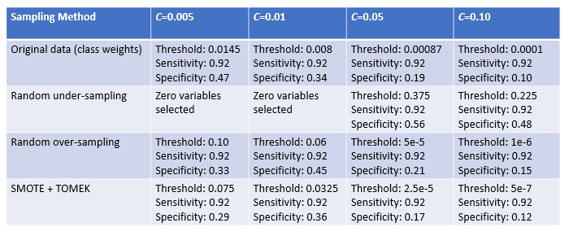

The logistic regression model with L1 regularization fit using the training dataset with random undersampling of the majority class and c=0.05 had the best performance, with a specificity of 0.56 and a sensitivity of 0.92. The code below creates a precision-recall curve for this model. A precision-recall curve was used rather than ROC curve as the data is imbalanced. Although this is not a strong overall predictor, the overall goal of this project was to maximize sensitivity over specificity.

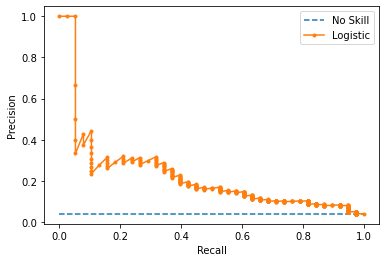

```python
sel_ = SelectFromModel(LogisticRegression(C=0.05, penalty='l1',solver='liblinear',random_state=1000,max_iter=500))
model=sel_.fit(x_rus, y_rus)
selected_feat = x_rus.columns[(sel_.get_support())]
x_new = sel_.transform(x_rus)
selected_features = pd.DataFrame(sel_.inverse_transform(x_new),
                                 index=x_rus.index,
                                 columns=x_rus.columns)

log_model=LogisticRegression(random_state=1000,max_iter=500,solver='lbfgs')
log_model.fit(selected_features,y_rus)
test_x_new = sel_.transform(x_test_df)
test_selected_features = pd.DataFrame(sel_.inverse_transform(test_x_new),
                                 index=x_test_df.index,
                                 columns=x_test_df.columns)

#calculate the predicted probabilities
log_predictions1=log_model.predict_proba(test_selected_features)
log_predictions = log_predictions1[:, 1]

# calculate precision and recall for each threshold
lr_precision, lr_recall, lr_thresholds = precision_recall_curve(y_test, log_predictions)

# plot the precision-recall curves
no_skill = len(y_test[y_test==1]) / len(y_test)
plt.plot([0, 1], [no_skill, no_skill], linestyle='--', label='No Skill')
plt.plot(lr_recall, lr_precision, marker='.', label='Logistic')
# axis labels
plt.xlabel('Recall')
plt.ylabel('Precision')
# show the legend
plt.legend()
# show the plot
plt.show()
```

The following table summarizes the 20 features selected for inclusion in this model. Examination of the selected features may help to further understanding of key risk factors for suicide attempt among adolescents. However, this should be interpreted with caution, because, when there is a group of highly correlated variables, logistic regression with L1 regularization tends to select just one of these variables at random.

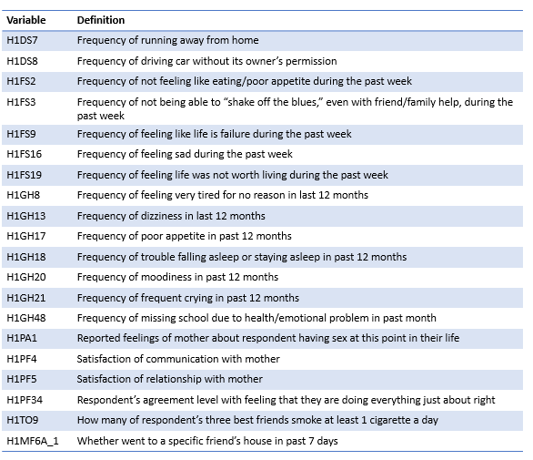